# Daser Ecce Nunc Benedicite Notebook with CRIM Intervals

Author

Richard Freedman

Published

June 25, 2024

# Introduction

In this project we explore the connections between **Ludwig Daser’s** four-voice motet, **Ecce nunc benedicite** and two related imitation masses that borrow from it: one by **Daser** himself and another by his music court successor, **Orlando di Lasso**.

Along the way, we use [CRIM Intervals](https://github.com/HCDigitalScholarship/intervals/blob/main/tutorial/01_Introduction_and_Corpus.md) tools to find and visualize patters in ways that help us understand the breadth and depth of the connections among these works.

- **Shared Ngrams**. First we look at the percentages of shared melodies in these pieces; specifically entry ngrams (those melodies that begin after a rest or section break)
- **Activity Maps of Ngrams**. These show us *where* in each piece each entry ngram appears, and can tell us about the compositional plan of these works in relation to each other.
- **Networks of Pieces based on Shared Ngrams**. As revealed by shared ngrams. Such representations can tell help is divide the corpus into ‘communities’ based on shared melodies relatedness.
- **Cadence Inventories, Radar Plots, and Progress Plots**. Looking the distribution and flow of cadence types in various ways.
- **Networks of Pieces based on Pairs of Cadences**. Here we look at successive pairs of cadences to reveal connections among pieces.
- **Presentation Type Inventories**. We look at various stereotypical schemes for imitative counterpoint, including fugas, imitative duos, and periodic entries.
- **Networks of Pieces based on Presentation Types**. Here we find communities of pieces based on shared *treatment* of individual soggetti
- **Homorhythm**. As it appears in the corpus, including information about the syllables and number of voices involved.

## Import Python Libraries

An essential first step . . .

```python
# python imports
from crim_intervals import *
from crim_intervals import importScore
from crim_intervals import main_objs
from community import community_louvain
from copy import deepcopy
from IPython.display import SVG
import altair as alt
import glob as glob
import crim_intervals
import crim_intervals.visualizations as viz
import numpy as np
import os
import pandas as pd
import re
import networkx as nx
import requests

MYDIR = ("saved_csv")
CHECK_FOLDER = os.path.isdir(MYDIR)

# If folder doesn't exist, then create it.
if not CHECK_FOLDER:
    os.makedirs(MYDIR)
    # print("created folder : ", MYDIR)

# else:
#     print(MYDIR, "folder already exists.")

MUSDIR = ("Music_Files")
CHECK_FOLDER = os.path.isdir(MUSDIR)

# If folder doesn't exist, then create it.
if not CHECK_FOLDER:
    os.makedirs(MUSDIR)
    # print("created folder : ", MUSDIR)

# else:
#     print(MUSDIR, "folder already exists.")

# code for Quarto and the charting tools
alt.renderers.enable('default')
import plotly.io as pio
pio.renderers.default = "plotly_mimetype+notebook_connected"

import warnings
warnings.filterwarnings('ignore')
```

### Identify the Corpus

Here we obtain the MEI files from our work.

```python
file_list = glob.glob('Music_Files/*')
file_list = sorted(file_list)
file_list
```

```
['Music_Files/Daser_Missa_Ecce_nunc_01_E.mei',
 'Music_Files/Daser_Missa_Ecce_nunc_02_E.mei',
 'Music_Files/Daser_Missa_Ecce_nunc_03_E.mei',
 'Music_Files/Daser_Missa_Ecce_nunc_04_E.mei',
 'Music_Files/Daser_Missa_Ecce_nunc_05_E.mei',
 'Music_Files/Daser_Motette_Ecce-nunc_E.mei',
 'Music_Files/Lassus_Missa_Ecce_01.mei',
 'Music_Files/Lassus_Missa_Ecce_02.mei',
 'Music_Files/Lassus_Missa_Ecce_03.mei',
 'Music_Files/Lassus_Missa_Ecce_04.mei',
 'Music_Files/Lassus_Missa_Ecce_05.mei']
```

## Melodic Ngrams

Here are the settings used in this experiment. These determine the kind and length of the ngrams.

```python
n=2
combineUnisons=False
kind='d'
thematic = True
anywhere = False
```

### The Model vs the Mass Movements

Here we will compare the ngrams of the model with each of the Mass movements.

This shows the % of ngrams shared between the pieces. The data are shown twice:

- in tabular form
- as a color chart (yellow = highly related; dark purple = not terribly related)

```python
# the settings
n=2
combineUnisons=False
kind='d'
thematic = True
anywhere = False

# the model in the list above this is piece #5
mod_corp = CorpusBase([file_list[5]])

# # the mass movements  in the list above these are all pieces EXCEPT #5
mass_corp = CorpusBase(file_list[:5] + file_list[6:])


# run the comparison, passing in both sets as parameters:
# be sure to set the N for length of ngrams!
soggetto_cross_plot_narrow = mod_corp.modelFinder(n=n,
                                                  masses=mass_corp,
                                                  models=mod_corp,
                                                 anywhere=anywhere,
                                                 thematic=thematic)

# view the result
soggetto_cross_plot_narrow
```

```
mei.base: WARNING: Importing <tie> without @startid and @endid is not yet supported.
```

| Model Mass | Daser_Motette_Ecce-nunc_E |
| --- | --- |
| Daser_Missa_Ecce_nunc_01_E | 0.882353 |
| Daser_Missa_Ecce_nunc_02_E | 0.809524 |
| Daser_Missa_Ecce_nunc_03_E | 0.680672 |
| Daser_Missa_Ecce_nunc_04_E | 0.475 |
| Daser_Missa_Ecce_nunc_05_E | 0.0 |
| Lassus_Missa_Ecce_01 | 0.666667 |
| Lassus_Missa_Ecce_02 | 0.635294 |
| Lassus_Missa_Ecce_03 | 0.541353 |
| Lassus_Missa_Ecce_04 | 0.459459 |
| Lassus_Missa_Ecce_05 | 0.533333 |

```python
fig = px.imshow(soggetto_cross_plot_narrow,
                width=600,
                height=600,
               title="Ngram Cross-Plot of Daser's Motet and the Two Masses")
fig
```

[interactive chart not shown]

Ngram Cross-Plot of Daser’s Motet and the Two Masses

### Interpretation of Ngrams

It seems from the above that **in the case of the Kyrie, Gloria, and Credo movements, the melodic motives of Daser’s Mass are more closely related to the motet those of Lasso’s Mass**.

Does this correspond to what human analysts notice about these movements?

## Shared Ngrams the Corpus

Here we compare all movements in the corpus to each other.

This shows which of the Mass movements are related to each other, too.

The tabular and color map version of the data are oriented the same way: **Lasso’s mass forms the columns; Daser’s mass forms the rows**. Read down+across to see the connection between the relevant pairs of movements.

The most interesting and relevant comparisons are probably those between analagous movements of the masses (so Kyrie to Kyrie, etc).

```python
# Full Cross Plot of All movements
corpus = CorpusBase(file_list)
soggetto_cross_plot = corpus.modelFinder(n=2)

# now we focus on just the central portion of the data, to show Lasso's mass (the columns) in relation to Daser's (the rows)
central_portion = soggetto_cross_plot.iloc[0:5, 5:11]

central_portion
```

```
mei.base: WARNING: Importing <tie> without @startid and @endid is not yet supported.
```

| Model Mass | Daser_Motette_Ecce-nunc_E | Lassus_Missa_Ecce_01 | Lassus_Missa_Ecce_02 | Lassus_Missa_Ecce_03 | Lassus_Missa_Ecce_04 | Lassus_Missa_Ecce_05 |
| --- | --- | --- | --- | --- | --- | --- |
| Daser_Missa_Ecce_nunc_01_E | 0.976923 | 0.923077 | 0.938462 | 0.946154 | 0.553846 | 0.615385 |
| Daser_Missa_Ecce_nunc_02_E | 0.638938 | 0.812389 | 0.847788 | 0.978761 | 0.644248 | 0.771681 |
| Daser_Missa_Ecce_nunc_03_E | 0.760417 | 0.853009 | 0.951389 | 0.966435 | 0.59838 | 0.666667 |
| Daser_Missa_Ecce_nunc_04_E | 0.8 | 0.928421 | 0.966316 | 0.96 | 0.703158 | 0.650526 |
| Daser_Missa_Ecce_nunc_05_E | 0.481481 | 0.592593 | 0.851852 | 0.740741 | 0.111111 | 0.592593 |

```python
fig = px.imshow(central_portion,
                width=800,
                height=600,
               title="Cross Plot of All Pieces with Each Other")
fig
```

[interactive chart not shown]

Cross Plot of All Pieces with Each Other

## Interpretation

Does this correspond to what human analysts notice about these movements?

We might *not* be surprised to see that the Agnus movements share 60% of the ngrams (they are short movements after all).

*This suggests, in brief, that Lasso’s Gloria and Credo are very connected with the corresponding movements of Daser’s Mass.*

## A Network of Pieces based on Shared Ngrams

Now let’s look at the corpus as a network of pieces. Networks are useful for the ways in which they make connections among items visible. Remember that:

*The items with the most connections will tend to appear at the center of the graph.*

In this network, the nodes are the pieces and edges represent the ngrams they share.

The thickness of the edges varies with the number of shared ngrams

The colors distinguish ‘communities’ of pieces that are highly related. These are created using the [Louvain Communities Detection](https://en.wikipedia.org/wiki/Louvain_method) algorithm.

As a reminder, here are the basic ngram settings used in this network:

```python
n=2
combineUnisons=False
kind='d'
thematic = True
anywhere = False
```

```python
# the ngram conditions
n=2
combineUnisons=False
kind='d'
thematic = True
anywhere = False

# now we build a list of all of the ngrams in each piece
list_series = []
for item in file_list:
    piece = importScore(item)
    title = piece.metadata['composer'] + ": " + piece.metadata['title']
    # find entries for model
    nr = piece.notes(combineUnisons=combineUnisons)
    mel = piece.melodic(df=nr, kind=kind, compound=False, unit=0, end=False)
    mod_mel_ngrams = piece.ngrams(df=mel, n=n, exclude=['Rest'])
    mod_entry_ngrams = piece.entries(df=mel, n=n, thematic=thematic, anywhere=anywhere, exclude=['Rest'])
    mod_entry_ngrams.fillna('')
    mod_entry_ngrams['title'] = title
    # Set the new column as the index
    mod_entry_ngrams.set_index(['title'], inplace=True)
    stacked_entries = mod_entry_ngrams.stack()
    list_series.append(stacked_entries)

data = pd.concat(list_series)

# and now, a network in which the nodes are the pieces and edges represent the ngrams they share.
# the thickness of the edges varies with the number of shared ngrams
# the colors distinguish 'communities' of pieces that are highly related

df = pd.DataFrame(data)
df = df.reset_index()
df.drop('level_1', axis=1, inplace=True)
df = df.rename(columns={0: 'ngram'})

#define the function to convert tuples to strings
def convertTuple(tup):
    out = ""
    if isinstance(tup, tuple):
        out = '_'.join(tup)
    return out
# clean the tuples
df['ngram'] = df['ngram'].apply(convertTuple)

# Group by 'ngram' and extract a list of unique titles for each group
grouped_titles = df.groupby('ngram')['title'].unique().reset_index(name='titles')

# Generate all pairs of titles for each group
all_pairs = []
for _, row in grouped_titles.iterrows():
    pairs = list(combinations(row['titles'], 2))
    all_pairs.append((row['ngram'], pairs))

# Create a new DataFrame with the results
result_df = pd.DataFrame(all_pairs, columns=['ngram', 'title_pairs'])
# remove the empty pairs
df_filtered = result_df[result_df['title_pairs'].apply(len) > 0]

# explode the complicated lists of tuples, effectively 'tyding' the data
exploded_df = df_filtered.explode('title_pairs')

# get the counts of each pair, which provides the basis of the weights
pair_counts = exploded_df['title_pairs'].value_counts()

# limit to high scoring pairs (>3)
pair_counts = pair_counts[pair_counts >= 6]

# Adding Louvain Communities
def add_communities(G):
    G = deepcopy(G)
    partition = community_louvain.best_partition(G)
    nx.set_node_attributes(G, partition, "group")
    return G

# Create an empty NetworkX graph
G = nx.Graph()


# Add nodes and assign weights to edges
for pair, count in pair_counts.items():
    # Directly unpacking the tuple into node1 and node2
    node1, node2 = pair
    # Adding nodes if they don't exist already
    if node1 not in G.nodes:
        G.add_node(node1)
    if node2 not in G.nodes:
        G.add_node(node2)
    # Adding edge with weight
    G.add_edge(node1, node2, weight=count)

# Adjusting edge thickness based on weights
for edge in G.edges(data=True):
    edge[2]['width'] = edge[2]['weight']

G = add_communities(G)

# set display parameters
ngram_map = Network(notebook=True,
                   width="800",
                          height="800",
                          bgcolor="black",
                          font_color="white")

# Set the physics layout of the network
ngram_map.set_options("""
{
"physics": {
"enabled": true,
"forceAtlas2Based": {
    "springLength": 1
},
"solver": "forceAtlas2Based"
}
}
""")

ngram_map.from_nx(G)
# # return the network
ngram_map.show("ngram_map.html")
```

```
mei.base: WARNING: Importing <tie> without @startid and @endid is not yet supported.
```

[interactive chart not shown]

Network of the Daser-Lasso Corpus based on Shared Ngrams

## Heat Maps: Ngrams in Time

#### Here we show the ngrams as the appear in time, from the beginning (at the left) to the end (at the right) of the motet.

Each ngram is associated with a distinct color, and the relative placement of the ngrams among the voices can be used to imagine the kinds of contrapuntal patterns heard at each moment in the piece.

The heatmap charts are dynamic: you can click on a given color to isolate that ngram to see where it appears in the piece.

Note: some colors repeat or are hard to distinguish from each other. But the ‘key’ at the top and right make it clear which color corresponds to which ngram.

As a reminder, here are the ngram settings used:

```python
n=2
combineUnisons=False
kind='d'
thematic = True
anywhere = False
```

```python
# the ngram conditions
n=2
combineUnisons=False
kind='d'
thematic = True
anywhere = False

model = importScore(file_list[5])

# find entries for model
nr = model.notes(combineUnisons=combineUnisons)
mel = model.melodic(df=nr, kind=kind, compound=False, unit=0, end=False)
mod_mel_ngrams = model.ngrams(df=mel, n=n, exclude=['Rest'])
mod_entry_ngrams = model.entries(df=mel, n=n, thematic=thematic, anywhere=anywhere, exclude=['Rest'])
mod_mel_ngrams_duration = model.durations(df=mel, n=n, mask_df=mod_entry_ngrams)
mod_entries_stack = list(mod_entry_ngrams.stack().unique())

print(model.metadata)

display(viz.plot_ngrams_heatmap(mod_entry_ngrams, mod_mel_ngrams_duration,
                        selected_patterns=mod_entries_stack,
                        voices=[],
                        includeCount=True))
```

```
{'title': 'Ecce nunc benedicite', 'composer': 'Ludwig Daser', 'date': None}
```

[interactive chart not shown]

Heat Map of Ngrams in Daser’s Motet

## Heat Map of Entries: Model Paired with Each Mass Movement

Here we produce ‘pairs’ of charts, comparing each movement of each mass with the motet.

Let’s make sure we correctly identify the pieces.

```python
model = importScore(file_list[5])
model.metadata

massfiles = file_list[:5] + file_list[6:]
massfiles
```

[output not shown]

```python
# fig-cap: "Paired Heatmaps for the Motet with Each Mass Movement"

# the ngram conditions
n=2
combineUnisons=False
kind='d'
thematic = True
anywhere = False


# find entries for model
model = importScore(file_list[5])
nr = model.notes(combineUnisons=combineUnisons)
mel = model.melodic(df=nr, kind=kind, compound=False, unit=0, end=False)
mod_mel_ngrams = model.ngrams(df=mel, n=n, exclude=['Rest'])
mod_entry_ngrams = model.entries(df=mel, n=n, thematic=thematic, anywhere=anywhere, exclude=['Rest'])
mod_mel_ngrams_duration = model.durations(df=mel, n=n, mask_df=mod_entry_ngrams)
mod_entries_stack = list(mod_entry_ngrams.stack().unique())

# find entries mass movements:
mass_movements = file_list[:5] + file_list[6:]
for movement in mass_movements:
    m_movement = importScore(movement)
    nr = m_movement.notes(combineUnisons=combineUnisons)
    mel = m_movement.melodic(df=nr, kind=kind, compound=False, unit=0, end=False)
    mass_mvmt_mel_ngrams = m_movement.ngrams(df=mel, n=n)
    mass_mvmt_entries = m_movement.entries(df=mel, n=n, thematic=thematic, anywhere=anywhere)
    mass_mvmt_mel_ngrams_duration = m_movement.durations(df=mel, n=n, mask_df=mass_mvmt_entries)
    mass_mvmt_entries_stack = mass_mvmt_entries.stack()

    # find shared entries
    shared_entries = list(set(mass_mvmt_entries_stack).intersection(mod_entries_stack))
    # or instead focus on one soggetto
    # in this case update code below, replacing 'shared_entries' with 'selected_entries'
    # selected_entries = [('-2', '3', '-2')]

    # print model metadata and chart
    print(model.metadata)
    # print(shared_entries)
    display(viz.plot_ngrams_heatmap(mod_entry_ngrams,
                                    mod_mel_ngrams_duration,
                        selected_patterns=shared_entries,
                        voices=[],
                                    includeCount=False))

    # # print mass movement metadata and chart
    print(m_movement.metadata)
    display(viz.plot_ngrams_heatmap(mass_mvmt_entries,
                                    mass_mvmt_mel_ngrams_duration,
                                selected_patterns=shared_entries,
                                voices=[],
                                    includeCount=False))
```

```
{'title': 'Ecce nunc benedicite', 'composer': 'Ludwig Daser', 'date': None}
```

[interactive chart not shown]

```
{'title': 'Daser Missa Ecce nunc Benedicite:  Kyrie', 'composer': 'Ludovi[cus] Daser', 'date': None}
```

[interactive chart not shown]

```
{'title': 'Ecce nunc benedicite', 'composer': 'Ludwig Daser', 'date': None}
```

[interactive chart not shown]

```
{'title': 'Daser Missa Ecce nunc Benedicite: Gloria', 'composer': 'Ludovi[cus] Daser', 'date': None}
```

[interactive chart not shown]

```
{'title': 'Ecce nunc benedicite', 'composer': 'Ludwig Daser', 'date': None}
```

[interactive chart not shown]

```
{'title': 'Daser Missa Ecce nunc Benedicite:  Credo', 'composer': 'Ludovi[cus] Daser', 'date': None}
```

[interactive chart not shown]

```
{'title': 'Ecce nunc benedicite', 'composer': 'Ludwig Daser', 'date': None}
```

[interactive chart not shown]

```
{'title': 'Daser Missa Ecce nunc Benedicite: Sanctus', 'composer': 'Ludovi[cus] Daser', 'date': None}
```

[interactive chart not shown]

```
{'title': 'Ecce nunc benedicite', 'composer': 'Ludwig Daser', 'date': None}
```

[interactive chart not shown]

```
{'title': 'Daser Missa Ecce nunc Benedicite: Agnus Dei', 'composer': 'Ludovi[cus] Daser', 'date': None}
```

[interactive chart not shown]

```
{'title': 'Ecce nunc benedicite', 'composer': 'Ludwig Daser', 'date': None}
```

[interactive chart not shown]

```
{'title': 'Lasso Missa Ecce nunc benedicite:  Kyrie', 'composer': 'Orlandus Lassus', 'date': None}
```

[interactive chart not shown]

```
{'title': 'Ecce nunc benedicite', 'composer': 'Ludwig Daser', 'date': None}
```

[interactive chart not shown]

```
{'title': 'Lasso Missa Ecce nunc benedicite: Gloria', 'composer': 'Orlandus Lassus', 'date': None}
```

[interactive chart not shown]

```
mei.base: WARNING: Importing <tie> without @startid and @endid is not yet supported.
```

```
{'title': 'Ecce nunc benedicite', 'composer': 'Ludwig Daser', 'date': None}
```

[interactive chart not shown]

```
{'title': 'Lasso Missa Ecce nunc benedicite: Credo', 'composer': 'Orlandus Lassus', 'date': None}
```

[interactive chart not shown]

```
{'title': 'Ecce nunc benedicite', 'composer': 'Ludwig Daser', 'date': None}
```

[interactive chart not shown]

```
{'title': 'Lasso Missa Ecce nunc benedicite: Sanctus', 'composer': 'Orlandus Lassus', 'date': None}
```

[interactive chart not shown]

```
{'title': 'Ecce nunc benedicite', 'composer': 'Ludwig Daser', 'date': None}
```

[interactive chart not shown]

```
{'title': 'Lasso Missa Ecce nunc benedicite: Agnus', 'composer': 'Orlandus Lassus', 'date': None}
```

[interactive chart not shown]

### Interpretation of nGram Heatmaps

The Kyrie movements show a strikingly clear relationship to the motet, albeit with a limited number of soggetti used in each case. But they are *the same* soggetti in each case!

The Sanctus and Agnus movements are quite selective in their borrowing. Again, we see very similar borrowing between Daser and Lasso.

The Gloria and Credo movements are more subtle and complex in their borrowing. It is nevertheless notable that the first soggetto of the model does not figure in prominently in these movements.

## Exploring Cadences

#### CRIM Intervals can identify Renaissance cadence types. Learn more [here](https://github.com/HCDigitalScholarship/intervals/blob/main/tutorial/11_Cadences.md).

We can report: cadence type, final tone, the specific voice roles involved, and contextual information about the place of the cadence in the piece and relative to others.

Here we explore the cadences as they appear throughout the corpus.

```python
file_list = glob.glob('Music_Files/*')
corpus = CorpusBase(file_list)

#select function.  remember to omit "()"
func = ImportedPiece.cadences

#run function on each piece; be sure to include keyword arguments
list_of_dfs = corpus.batch(func = func, kwargs = {'keep_keys': True}, metadata = True)

#concatenate the resulting dataframes into one
corpus_cadences = pd.concat(list_of_dfs, ignore_index = True)

# new order for columns:
col_list = ['Composer', 'Title', 'Measure', 'Beat', 'Pattern', 'CadType', 'Tone','CVFs',
                'LeadingTones', 'Sounding', 'Low','RelLow','RelTone',
                'Progress','SinceLast','ToNext']

corpus_cadences = corpus_cadences[col_list]

# show the results
corpus_cadences
```

```
mei.base: WARNING: Importing <tie> without @startid and @endid is not yet supported.
```

|  | Composer | Title | Measure | Beat | Pattern | CadType | Tone | CVFs | LeadingTones | Sounding | Low | RelLow | RelTone | Progress | SinceLast | ToNext |
| --- | --- | --- | --- | --- | --- | --- | --- | --- | --- | --- | --- | --- | --- | --- | --- | --- |
| 0 | Ludovi[cus] Daser | Daser Missa Ecce nunc Benedicite: Sanctus | 2.0 | 3.0 | C1t2x | Evaded Clausula Vera | C | tCx | 1.0 | 3.0 | C4 | P11 | P4 | 0.014563 | 12.0 | 16.0 |
| 1 | Ludovi[cus] Daser | Daser Missa Ecce nunc Benedicite: Sanctus | 4.0 | 3.0 | BC2 | Authentic | G | tCB | 0.0 | 4.0 | G3 | P8 | P8 | 0.033981 | 16.0 | 12.0 |
| 2 | Ludovi[cus] Daser | Daser Missa Ecce nunc Benedicite: Sanctus | 6.0 | 1.0 | C1T-2x | Clausula Vera | G | CTx | 1.0 | 3.0 | G3 | P8 | P8 | 0.048544 | 12.0 | 16.0 |
| 3 | Ludovi[cus] Daser | Daser Missa Ecce nunc Benedicite: Sanctus | 8.0 | 1.0 | BC1 | Authentic | D | CuTB | 1.0 | 4.0 | D3 | P5 | P5 | 0.067961 | 16.0 | 20.0 |
| 4 | Ludovi[cus] Daser | Daser Missa Ecce nunc Benedicite: Sanctus | 10.0 | 3.0 | C2T-2 | Clausula Vera | G | CT | 0.0 | 4.0 | G3 | P8 | P8 | 0.092233 | 20.0 | 36.0 |
| ... | ... | ... | ... | ... | ... | ... | ... | ... | ... | ... | ... | ... | ... | ... | ... | ... |
| 201 | Orlandus Lassus | Lasso Missa Ecce nunc benedicite: Gloria | 75.0 | 4.0 | C2T-1 | Phrygian Clausula Vera | E | CT | 1.0 | 5.0 | C3 | -P5 | M6 | 0.799465 | 86.0 | 10.0 |
| 202 | Orlandus Lassus | Lasso Missa Ecce nunc benedicite: Gloria | 77.0 | 1.0 | C1T-2 | Clausula Vera | G | CQT | 1.0 | 4.0 | G3 | P1 | P8 | 0.812834 | 10.0 | 56.0 |
| 203 | Orlandus Lassus | Lasso Missa Ecce nunc benedicite: Gloria | 84.0 | 1.0 | BC1 | Authentic | C | CtTB | 1.0 | 6.0 | C3 | -P5 | P4 | 0.887701 | 56.0 | 56.0 |
| 204 | Orlandus Lassus | Lasso Missa Ecce nunc benedicite: Gloria | 91.0 | 1.0 | BC1 | Authentic | D | CB | 1.0 | 5.0 | D3 | -P4 | P5 | 0.962567 | 56.0 | 12.0 |
| 205 | Orlandus Lassus | Lasso Missa Ecce nunc benedicite: Gloria | 92.0 | 3.0 | C1T-2 | Clausula Vera | G | CT | 1.0 | 6.0 | B2 | -m6 | P8 | 0.978610 | 12.0 | 28.0 |

206 rows × 16 columns

### Cadences as Annotated Scores

CRIM Intervals can produce a summary of cadences with a dynamic ‘linked example’.

Click the ‘CadType’ cell to see the example rendered with red highlights indicating which patterns and voices were identified by the algorithm as the cadence in question.

```python
# We also need to load the files from GIT, for the LinkExample function

prefix = 'https://raw.githubusercontent.com/RichardFreedman/CRIM_Additions/main/Daser_Missa_Ecce_nunc/MEI/'

# piece_id = 'Daser_Missa_Ecce_nunc_01_E.mei'
# piece_id = 'Daser_Motette_Ecce-nunc_E.mei'
dfs = []

for path in file_list:
    piece_id = os.path.basename(path)
    url = prefix + piece_id
    piece = importScore(url)
    cd=piece.cadences()

    # filter for a given type or tone
    # cd = cd.loc[cd['CVFs'] == 'CTb']

    print(piece_id)
    piece.linkExamples(df=cd, piece_url=url)
```

```
Daser_Missa_Ecce_nunc_04_E.mei
```

| Last | CadType | LeadingTones | CVFs | Low | RelLow | Tone | RelTone | TSig | Measure | Beat | Sounding | Progress | SinceLast | ToNext |
| --- | --- | --- | --- | --- | --- | --- | --- | --- | --- | --- | --- | --- | --- | --- |
| 12.0 | Evaded Clausula Vera | 1 | tCx | C4 | P11 | C | P4 | 4/2 | 2.0 | 3.0 | 3.0 | 0.014563 | 12.0 | 16.0 |
| 28.0 | Authentic | 0 | tCB | G3 | P8 | G | P8 | 4/2 | 4.0 | 3.0 | 4.0 | 0.033981 | 16.0 | 12.0 |
| 40.0 | Clausula Vera | 1 | CTx | G3 | P8 | G | P8 | 4/2 | 6.0 | 1.0 | 3.0 | 0.048544 | 12.0 | 16.0 |
| 56.0 | Authentic | 1 | CuTB | D3 | P5 | D | P5 | 4/2 | 8.0 | 1.0 | 4.0 | 0.067961 | 16.0 | 20.0 |
| 76.0 | Clausula Vera | 0 | CT | G3 | P8 | G | P8 | 4/2 | 10.0 | 3.0 | 4.0 | 0.092233 | 20.0 | 36.0 |
| 112.0 | Clausula Vera | 1 | CxTx | G3 | P8 | G | P8 | 4/2 | 15.0 | 1.0 | 2.0 | 0.135922 | 36.0 | 40.0 |
| 152.0 | Clausula Vera | 1 | CxTx | G3 | P8 | G | P8 | 4/2 | 20.0 | 1.0 | 2.0 | 0.184466 | 40.0 | 64.0 |
| 216.0 | Evaded Authentic | 1 | TCb | E4 | M13 | G | P8 | 4/2 | 28.0 | 1.0 | 3.0 | 0.262136 | 64.0 | 16.0 |
| 232.0 | Clausula Vera | 0 | CT | G3 | P8 | G | P8 | 4/2 | 30.0 | 1.0 | 3.0 | 0.281553 | 16.0 | 32.0 |
| 264.0 | Clausula Vera | 1 | CT | C4 | P11 | C | P4 | 4/2 | 34.0 | 1.0 | 2.0 | 0.320388 | 32.0 | 64.0 |
| 328.0 | Clausula Vera | 1 | CTx | D4 | P12 | D | P5 | 3/1 | 42.0 | 1.0 | 2.0 | 0.398058 | 64.0 | 48.0 |
| 376.0 | Clausula Vera | 1 | CT | C3 | P4 | C | P4 | 3/1 | 46.0 | 1.0 | 4.0 | 0.456311 | 48.0 | 60.0 |
| 436.0 | Authentic | 1 | CTB | G3 | P8 | G | P8 | 3/1 | 51.0 | 1.0 | 4.0 | 0.529126 | 60.0 | 60.0 |
| 496.0 | Authentic | 1 | CTB | G2 | P1 | G | P8 | 4/2 | 56.0 | 1.0 | 4.0 | 0.601942 | 60.0 | 80.0 |
| 576.0 | Clausula Vera | 1 | CT | D3 | P5 | D | P5 | 4/2 | 66.0 | 1.0 | 2.0 | 0.699029 | 80.0 | 80.0 |
| 656.0 | Clausula Vera | 1 | CT | D3 | P5 | D | P5 | 3/1 | 76.0 | 1.0 | 2.0 | 0.796117 | 80.0 | 48.0 |
| 704.0 | Clausula Vera | 1 | CT | C3 | P4 | C | P4 | 3/1 | 80.0 | 1.0 | 4.0 | 0.854369 | 48.0 | 60.0 |
| 764.0 | Authentic | 1 | CTB | G3 | P8 | G | P8 | 3/1 | 85.0 | 1.0 | 4.0 | 0.927184 | 60.0 | 60.0 |
| 824.0 | Authentic | 1 | CTB | G2 | P1 | G | P8 | 3/1 | 90.0 | 1.0 | 4.0 | 1.000000 | 60.0 | 24.0 |

```
Daser_Missa_Ecce_nunc_02_E.mei
```

| Last | CadType | LeadingTones | CVFs | Low | RelLow | Tone | RelTone | TSig | Measure | Beat | Sounding | Progress | SinceLast | ToNext |
| --- | --- | --- | --- | --- | --- | --- | --- | --- | --- | --- | --- | --- | --- | --- |
| 40.0 | Evaded Authentic | -1.0 | cB | G3 | P1 | NaN | NaN | 4/2 | 6.0 | 1.0 | 4.0 | 0.058824 | 40.0 | 24.0 |
| 64.0 | Authentic | 1.0 | CuTB | D3 | -P4 | D | P5 | 4/2 | 9.0 | 1.0 | 4.0 | 0.094118 | 24.0 | 56.0 |
| 120.0 | Authentic | 1.0 | CTB | G2 | -P8 | G | P8 | 4/2 | 16.0 | 1.0 | 4.0 | 0.176471 | 56.0 | 28.0 |
| 148.0 | Clausula Vera | 1.0 | CT | D4 | P5 | D | P5 | 4/2 | 19.0 | 3.0 | 2.0 | 0.217647 | 28.0 | 24.0 |
| 172.0 | Clausula Vera | 0.0 | CT | D3 | -P4 | D | P5 | 4/2 | 22.0 | 3.0 | 4.0 | 0.252941 | 24.0 | 44.0 |
| 216.0 | Abandoned Authentic | 1.0 | Cxzx | G4 | P8 | G | P8 | 4/2 | 28.0 | 1.0 | 1.0 | 0.317647 | 44.0 | 28.0 |
| 244.0 | Phrygian Clausula Vera | 1.0 | CT | A3 | M2 | A | M2 | 4/2 | 31.0 | 3.0 | 4.0 | 0.358824 | 28.0 | 36.0 |
| 280.0 | Authentic | 1.0 | CuTB | D3 | -P4 | D | P5 | 4/2 | 36.0 | 1.0 | 4.0 | 0.411765 | 36.0 | 40.0 |
| 320.0 | Authentic | 1.0 | tCB | C3 | -P5 | C | P4 | 4/2 | 41.0 | 1.0 | 4.0 | 0.470588 | 40.0 | 56.0 |
| 376.0 | Clausula Vera | 0.0 | CT | G3 | P1 | D | P5 | 4/2 | 48.0 | 1.0 | 4.0 | 0.552941 | 56.0 | 12.0 |
| 388.0 | Clausula Vera | 0.0 | TC | B-3 | m3 | D | P5 | 4/2 | 49.0 | 3.0 | 4.0 | 0.570588 | 12.0 | 13.0 |
| 401.0 | Phrygian Clausula Vera | 1.0 | TC | F3 | -M2 | B | M3 | 4/2 | 51.0 | 1.5 | 4.0 | 0.589706 | 13.0 | 7.0 |
| 408.0 | Phrygian | 1.0 | CTP | D3 | -P4 | A | M2 | 4/2 | 52.0 | 1.0 | 4.0 | 0.600000 | 7.0 | 28.0 |
| 436.0 | Authentic | 1.0 | CTB | C3 | -P5 | C | P4 | 4/2 | 55.0 | 3.0 | 4.0 | 0.641176 | 28.0 | 12.0 |
| 448.0 | Clausula Vera | 1.0 | CT | G3 | P1 | G | P8 | 4/2 | 57.0 | 1.0 | 4.0 | 0.658824 | 12.0 | 52.0 |
| 500.0 | Evaded Authentic | 1.0 | CTb | B-3 | m3 | D | P5 | 4/2 | 63.0 | 3.0 | 3.0 | 0.735294 | 52.0 | 16.0 |
| 516.0 | Clausula Vera | 0.0 | CT | D3 | -P4 | D | P5 | 4/2 | 65.0 | 3.0 | 4.0 | 0.758824 | 16.0 | 20.0 |
| 536.0 | Clausula Vera | 1.0 | CTx | G3 | P1 | G | P8 | 4/2 | 68.0 | 1.0 | 2.0 | 0.788235 | 20.0 | 16.0 |
| 552.0 | Clausula Vera | 1.0 | CT | C3 | -P5 | C | P4 | 4/2 | 70.0 | 1.0 | 2.0 | 0.811765 | 16.0 | 20.0 |
| 572.0 | Evaded Authentic | 1.0 | TCb | C4 | P4 | G | P8 | 4/2 | 72.0 | 3.0 | 4.0 | 0.841176 | 20.0 | 20.0 |
| 592.0 | NaN | NaN | ApTx | F4 | m7 | C | P4 | 4/2 | 75.0 | 1.0 | 3.0 | 0.870588 | 20.0 | 20.0 |
| 612.0 | Clausula Vera | 0.0 | CT | G3 | P1 | G | P8 | 4/2 | 77.0 | 3.0 | 4.0 | 0.900000 | 20.0 | 52.0 |
| 664.0 | Clausula Vera | 1.0 | CT | G3 | P1 | G | P8 | 4/2 | 84.0 | 1.0 | 2.0 | 0.976471 | 52.0 | 32.0 |

```
Daser_Missa_Ecce_nunc_05_E.mei
```

| Last | CadType | LeadingTones | CVFs | Low | RelLow | Tone | RelTone | TSig | Measure | Beat | Sounding | Progress | SinceLast | ToNext |
| --- | --- | --- | --- | --- | --- | --- | --- | --- | --- | --- | --- | --- | --- | --- |
| 36.0 | Evaded Authentic | 1 | CuTb | B-3 | m3 | D | P5 | 4/2 | 5.0 | 3.0 | 4.0 | 0.163636 | 36.0 | 16.0 |
| 52.0 | Authentic | 1 | CTB | G2 | -P8 | G | P8 | 4/2 | 7.0 | 3.0 | 3.0 | 0.236364 | 16.0 | 40.0 |
| 92.0 | Clausula Vera | 1 | CT | C3 | -P5 | C | P4 | 4/2 | 12.0 | 3.0 | 3.0 | 0.418182 | 40.0 | 40.0 |
| 132.0 | Authentic | 1 | CTB | C3 | -P5 | C | P4 | 4/2 | 17.0 | 3.0 | 4.0 | 0.600000 | 40.0 | 32.0 |
| 164.0 | Clausula Vera | 0 | CT | D3 | -P4 | D | P5 | 3/1 | 20.0 | 2.0 | 4.0 | 0.745455 | 32.0 | 8.0 |
| 172.0 | Authentic | 1 | CuTB | G3 | P1 | G | P8 | 3/1 | 21.0 | 1.0 | 4.0 | 0.781818 | 8.0 | 48.0 |
| 220.0 | Authentic | 1 | tCB | G3 | P1 | G | P8 | 3/1 | 25.0 | 1.0 | 4.0 | 1.000000 | 48.0 | 24.0 |

```
Daser_Motette_Ecce-nunc_E.mei
```

| Last | CadType | LeadingTones | CVFs | Low | RelLow | Tone | RelTone | TSig | Measure | Beat | Sounding | Progress | SinceLast | ToNext |
| --- | --- | --- | --- | --- | --- | --- | --- | --- | --- | --- | --- | --- | --- | --- |
| 66.0 | Clausula Vera | 0.0 | TC | F3 | -M2 | D | P5 | 4/2 | 9.0 | 2.0 | 4.0 | 0.108553 | 66.0 | 6.0 |
| 72.0 | Clausula Vera | 1.0 | CT | D3 | -P4 | D | P5 | 4/2 | 10.0 | 1.0 | 4.0 | 0.118421 | 6.0 | 12.0 |
| 84.0 | Clausula Vera | 1.0 | CT | G3 | P1 | G | P8 | 4/2 | 11.0 | 3.0 | 4.0 | 0.138158 | 12.0 | 28.0 |
| 112.0 | Authentic | 1.0 | CTB | G3 | P1 | G | P8 | 4/2 | 15.0 | 1.0 | 4.0 | 0.184211 | 28.0 | 36.0 |
| 148.0 | Clausula Vera | 1.0 | CT | D4 | P5 | D | P5 | 4/2 | 19.0 | 3.0 | 2.0 | 0.243421 | 36.0 | 12.0 |
| 160.0 | Clausula Vera | 1.0 | TC | E4 | M6 | G | P8 | 4/2 | 21.0 | 1.0 | 3.0 | 0.263158 | 12.0 | 24.0 |
| 184.0 | Clausula Vera | 1.0 | CT | D3 | -P4 | D | P5 | 4/2 | 24.0 | 1.0 | 3.0 | 0.302632 | 24.0 | 40.0 |
| 224.0 | Clausula Vera | 1.0 | tCT | G3 | P1 | G | P8 | 4/2 | 29.0 | 1.0 | 4.0 | 0.368421 | 40.0 | 12.0 |
| 236.0 | Clausula Vera | 1.0 | CT | C3 | -P5 | C | P4 | 4/2 | 30.0 | 3.0 | 4.0 | 0.388158 | 12.0 | 20.0 |
| 256.0 | Altizans Only | 1.0 | ATx | F4 | m7 | C | P4 | 4/2 | 33.0 | 1.0 | 3.0 | 0.421053 | 20.0 | 24.0 |
| 280.0 | Authentic | 1.0 | tCB | C3 | -P5 | C | P4 | 4/2 | 36.0 | 1.0 | 4.0 | 0.460526 | 24.0 | 16.0 |
| 296.0 | Authentic | 1.0 | CTB | G3 | P1 | G | P8 | 4/2 | 38.0 | 1.0 | 4.0 | 0.486842 | 16.0 | 20.0 |
| 316.0 | Abandoned Authentic | 0.0 | Czx | G4 | P8 | G | P8 | 4/2 | 40.0 | 3.0 | 2.0 | 0.519737 | 20.0 | 28.0 |
| 344.0 | Clausula Vera | 0.0 | CT | G3 | P1 | D | P5 | 4/2 | 44.0 | 1.0 | 4.0 | 0.565789 | 28.0 | 12.0 |
| 356.0 | Clausula Vera | 0.0 | TC | B-3 | m3 | D | P5 | 4/2 | 45.0 | 3.0 | 4.0 | 0.585526 | 12.0 | 12.0 |
| 368.0 | Evaded Authentic | -1.0 | cB | D3 | -P4 | NaN | NaN | 4/2 | 47.0 | 1.0 | 4.0 | 0.605263 | 12.0 | 12.0 |
| 380.0 | NaN | NaN | CTP | D3 | -P4 | A | M2 | 4/2 | 48.0 | 3.0 | 3.0 | 0.625000 | 12.0 | 36.0 |
| 416.0 | Evaded Authentic | 1.0 | CTb | G3 | P1 | D | P5 | 4/2 | 53.0 | 1.0 | 4.0 | 0.684211 | 36.0 | 12.0 |
| 428.0 | Clausula Vera | 1.0 | tCT | D3 | -P4 | D | P5 | 4/2 | 54.0 | 3.0 | 4.0 | 0.703947 | 12.0 | 20.0 |
| 448.0 | Clausula Vera | 1.0 | CT | G3 | P1 | G | P8 | 4/2 | 57.0 | 1.0 | 3.0 | 0.736842 | 20.0 | 16.0 |
| 464.0 | Clausula Vera | 1.0 | CT | C3 | -P5 | C | P4 | 4/2 | 59.0 | 1.0 | 2.0 | 0.763158 | 16.0 | 12.0 |
| 476.0 | Abandoned Authentic | -1.0 | cx | E4 | M6 | NaN | NaN | 4/2 | 60.0 | 3.0 | 2.0 | 0.782895 | 12.0 | 8.0 |
| 484.0 | Evaded Clausula Vera | -1.0 | Tcx | E4 | M6 | NaN | NaN | 4/2 | 61.0 | 3.0 | 2.0 | 0.796053 | 8.0 | 8.0 |
| 492.0 | Evaded Clausula Vera | -1.0 | Tc | A3 | M2 | NaN | NaN | 4/2 | 62.0 | 3.0 | 3.0 | 0.809211 | 8.0 | 8.0 |
| 500.0 | Evaded Altizans Only | -1.0 | aT | G3 | P1 | NaN | NaN | 4/2 | 63.0 | 3.0 | 4.0 | 0.822368 | 8.0 | 20.0 |
| 520.0 | Clausula Vera | 1.0 | CT | G3 | P1 | G | P8 | 4/2 | 66.0 | 1.0 | 4.0 | 0.855263 | 20.0 | 96.0 |

```
Daser_Missa_Ecce_nunc_03_E.mei
```

| Last | CadType | LeadingTones | CVFs | Low | RelLow | Tone | RelTone | TSig | Measure | Beat | Sounding | Progress | SinceLast | ToNext |
| --- | --- | --- | --- | --- | --- | --- | --- | --- | --- | --- | --- | --- | --- | --- |
| 40.0 | Evaded Authentic | -1.0 | cB | G3 | P1 | NaN | NaN | 4/2 | 6.0 | 1.0 | 4.0 | 0.030303 | 40.0 | 24.0 |
| 64.0 | Authentic | 1.0 | CuTB | D3 | -P4 | D | P5 | 4/2 | 9.0 | 1.0 | 4.0 | 0.048485 | 24.0 | 40.0 |
| 104.0 | Authentic | 1.0 | CTB | G2 | -P8 | G | P8 | 4/2 | 14.0 | 1.0 | 4.0 | 0.078788 | 40.0 | 36.0 |
| 140.0 | Clausula Vera | 1.0 | CT | D4 | P5 | D | P5 | 4/2 | 18.0 | 3.0 | 2.0 | 0.106061 | 36.0 | 20.0 |
| 160.0 | Authentic | 0.0 | CB | D3 | -P4 | D | P5 | 4/2 | 21.0 | 1.0 | 4.0 | 0.121212 | 20.0 | 32.0 |
| 192.0 | Clausula Vera | 1.0 | CT | C3 | -P5 | C | P4 | 4/2 | 25.0 | 1.0 | 4.0 | 0.145455 | 32.0 | 40.0 |
| 232.0 | NaN | NaN | CTP | D3 | -P4 | A | M2 | 4/2 | 30.0 | 1.0 | 4.0 | 0.175758 | 40.0 | 8.0 |
| 240.0 | Authentic | 1.0 | tCB | D3 | -P4 | D | P5 | 4/2 | 31.0 | 1.0 | 4.0 | 0.181818 | 8.0 | 20.0 |
| 260.0 | Evaded Authentic | 1.0 | TCb | E4 | M6 | G | P8 | 4/2 | 33.0 | 3.0 | 3.0 | 0.196970 | 20.0 | 12.0 |
| 272.0 | Clausula Vera | 1.0 | TC | G3 | P1 | G | P8 | 4/2 | 35.0 | 1.0 | 2.0 | 0.206061 | 12.0 | 16.0 |
| 288.0 | Altizans Only | 1.0 | AT | C3 | -P5 | G | P8 | 4/2 | 37.0 | 1.0 | 4.0 | 0.218182 | 16.0 | 12.0 |
| 300.0 | Clausula Vera | 1.0 | CTx | G3 | P1 | G | P8 | 4/2 | 38.0 | 3.0 | 3.0 | 0.227273 | 12.0 | 60.0 |
| 360.0 | Clausula Vera | 1.0 | QCT | C3 | -P5 | C | P4 | 4/2 | 46.0 | 1.0 | 4.0 | 0.272727 | 60.0 | 80.0 |
| 440.0 | Clausula Vera | 1.0 | TC | G4 | P8 | G | P8 | 4/2 | 56.0 | 1.0 | 2.0 | 0.333333 | 80.0 | 24.0 |
| 464.0 | Clausula Vera | 1.0 | TC | D4 | P5 | D | P5 | 4/2 | 59.0 | 1.0 | 2.0 | 0.351515 | 24.0 | 44.0 |
| 508.0 | Clausula Vera | 0.0 | tCT | D3 | -P4 | D | P5 | 4/2 | 64.0 | 3.0 | 4.0 | 0.384848 | 44.0 | 12.0 |
| 520.0 | Clausula Vera | 1.0 | CxTx | D4 | P5 | D | P5 | 4/2 | 66.0 | 1.0 | 2.0 | 0.393939 | 12.0 | 76.0 |
| 596.0 | Clausula Vera | 1.0 | CT | D3 | -P4 | D | P5 | 4/2 | 75.0 | 3.0 | 2.0 | 0.451515 | 76.0 | 32.0 |
| 628.0 | Clausula Vera | 1.0 | CT | C3 | -P5 | C | P4 | 4/2 | 79.0 | 3.0 | 2.0 | 0.475758 | 32.0 | 44.0 |
| 672.0 | Clausula Vera | 1.0 | TC | G3 | P1 | G | P8 | 4/2 | 85.0 | 1.0 | 3.0 | 0.509091 | 44.0 | 52.0 |
| 724.0 | Clausula Vera | 1.0 | CTx | D4 | P5 | D | P5 | 4/2 | 91.0 | 3.0 | 2.0 | 0.548485 | 52.0 | 12.0 |
| 736.0 | Authentic | 0.0 | BC | G3 | P1 | G | P8 | 4/2 | 93.0 | 1.0 | 3.0 | 0.557576 | 12.0 | 8.0 |
| 744.0 | Evaded Authentic | 1.0 | Cb | E4 | M6 | G | P8 | 4/2 | 94.0 | 1.0 | 3.0 | 0.563636 | 8.0 | 8.0 |
| 752.0 | Clausula Vera | 1.0 | CT | G4 | P8 | G | P8 | 4/2 | 95.0 | 1.0 | 2.0 | 0.569697 | 8.0 | 36.0 |
| 788.0 | Clausula Vera | 1.0 | CT | C4 | P4 | C | P4 | 4/2 | 99.0 | 3.0 | 2.0 | 0.596970 | 36.0 | 68.0 |
| 856.0 | Clausula Vera | 1.0 | CTx | D4 | P5 | D | P5 | 4/2 | 108.0 | 1.0 | 2.0 | 0.648485 | 68.0 | 32.0 |
| 888.0 | Authentic | 1.0 | TCB | G3 | P1 | G | P8 | 4/2 | 112.0 | 1.0 | 3.0 | 0.672727 | 32.0 | 40.0 |
| 928.0 | Clausula Vera | 1.0 | CT | C3 | -P5 | C | P4 | 4/2 | 117.0 | 1.0 | 4.0 | 0.703030 | 40.0 | 32.0 |
| 960.0 | Evaded Authentic | 1.0 | CuTx | G3 | P1 | G | P8 | 4/2 | 121.0 | 1.0 | 3.0 | 0.727273 | 32.0 | 56.0 |
| 1016.0 | Clausula Vera | 1.0 | CxTx | A3 | M2 | A | M2 | 4/2 | 128.0 | 1.0 | 2.0 | 0.769697 | 56.0 | 32.0 |
| 1048.0 | Evaded Altizans Only | -1.0 | aT | F3 | -M2 | NaN | NaN | 4/2 | 132.0 | 1.0 | 4.0 | 0.793939 | 32.0 | 8.0 |
| 1056.0 | Authentic | 1.0 | CB | C3 | -P5 | C | P4 | 4/2 | 133.0 | 1.0 | 4.0 | 0.800000 | 8.0 | 24.0 |
| 1080.0 | Abandoned Authentic | 0.0 | Czx | G4 | P8 | G | P8 | 4/2 | 136.0 | 1.0 | 2.0 | 0.818182 | 24.0 | 28.0 |
| 1108.0 | Clausula Vera | 0.0 | CT | G3 | P1 | D | P5 | 4/2 | 139.0 | 3.0 | 4.0 | 0.839394 | 28.0 | 28.0 |
| 1136.0 | NaN | NaN | CP | D3 | -P4 | A | M2 | 4/2 | 143.0 | 1.0 | 4.0 | 0.860606 | 28.0 | 40.0 |
| 1176.0 | Abandoned Authentic | 0.0 | Cx | G4 | P8 | G | P8 | 4/2 | 148.0 | 1.0 | 2.0 | 0.890909 | 40.0 | 16.0 |
| 1192.0 | Clausula Vera | 0.0 | CT | D3 | -P4 | D | P5 | 4/2 | 150.0 | 1.0 | 4.0 | 0.903030 | 16.0 | 4.0 |
| 1196.0 | Clausula Vera | 1.0 | CxTx | G3 | P1 | G | P8 | 4/2 | 150.0 | 3.0 | 2.0 | 0.906061 | 4.0 | 16.0 |
| 1212.0 | Evaded Altizans Only | -1.0 | aT | C3 | -P5 | NaN | NaN | 4/2 | 152.0 | 3.0 | 3.0 | 0.918182 | 16.0 | 8.0 |
| 1220.0 | Evaded Altizans Only | -1.0 | aT | C4 | P4 | NaN | NaN | 4/2 | 153.0 | 3.0 | 3.0 | 0.924242 | 8.0 | 8.0 |
| 1228.0 | Evaded Clausula Vera | -1.0 | Tc | A3 | M2 | NaN | NaN | 4/2 | 154.0 | 3.0 | 3.0 | 0.930303 | 8.0 | 8.0 |
| 1236.0 | Evaded Altizans Only | -1.0 | aT | G3 | P1 | NaN | NaN | 4/2 | 155.0 | 3.0 | 4.0 | 0.936364 | 8.0 | 68.0 |
| 1304.0 | Clausula Vera | 1.0 | CxTx | G3 | P1 | G | P8 | 4/2 | 164.0 | 1.0 | 2.0 | 0.987879 | 68.0 | 32.0 |

```
Daser_Missa_Ecce_nunc_01_E.mei
```

| Last | CadType | LeadingTones | CVFs | Low | RelLow | Tone | RelTone | TSig | Measure | Beat | Sounding | Progress | SinceLast | ToNext |
| --- | --- | --- | --- | --- | --- | --- | --- | --- | --- | --- | --- | --- | --- | --- |
| 80.0 | Authentic | 1 | CTB | G2 | -P8 | G | P8 | 4/2 | 11.0 | 1.0 | 4.0 | 0.285714 | 80.0 | 48.0 |
| 128.0 | Clausula Vera | 1 | CT | D4 | P5 | D | P5 | 4/2 | 17.0 | 1.0 | 2.0 | 0.457143 | 48.0 | 12.0 |
| 140.0 | Abandoned Clausula Vera | 1 | zC | G3 | P1 | G | P8 | 4/2 | 18.0 | 3.0 | 3.0 | 0.500000 | 12.0 | 12.0 |
| 152.0 | Clausula Vera | 1 | CT | A3 | M2 | C | P4 | 4/2 | 20.0 | 1.0 | 4.0 | 0.542857 | 12.0 | 80.0 |
| 232.0 | Evaded Authentic | 1 | CTb | B-3 | m3 | D | P5 | 4/2 | 30.0 | 1.0 | 4.0 | 0.828571 | 80.0 | 12.0 |
| 244.0 | Clausula Vera | 0 | tACT | D3 | -P4 | D | P5 | 4/2 | 31.0 | 3.0 | 4.0 | 0.871429 | 12.0 | 20.0 |
| 264.0 | Clausula Vera | 1 | CT | G3 | P1 | G | P8 | 4/2 | 34.0 | 1.0 | 3.0 | 0.942857 | 20.0 | 32.0 |

```
Lassus_Missa_Ecce_05.mei
```

| Last | CadType | LeadingTones | CVFs | Low | RelLow | Tone | RelTone | TSig | Measure | Beat | Sounding | Progress | SinceLast | ToNext |
| --- | --- | --- | --- | --- | --- | --- | --- | --- | --- | --- | --- | --- | --- | --- |
| 40.0 | Clausula Vera | 1 | CT | D3 | -P4 | D | P5 | 4/2 | 6.0 | 1.0 | 6 | 0.196078 | 40.0 | 16.0 |
| 56.0 | Clausula Vera | 1 | CT | G3 | P1 | G | P8 | 4/2 | 8.0 | 1.0 | 5 | 0.274510 | 16.0 | 20.0 |
| 76.0 | Clausula Vera | 1 | CT | C3 | -P5 | C | P4 | 4/2 | 10.0 | 3.0 | 4 | 0.372549 | 20.0 | 40.0 |
| 116.0 | Authentic | 1 | tCTB | C3 | -P5 | C | P4 | 4/2 | 15.0 | 3.0 | 6 | 0.568627 | 40.0 | 40.0 |
| 156.0 | Authentic | 1 | CTB | G3 | P1 | G | P8 | 3/1 | 19.0 | 1.0 | 6 | 0.764706 | 40.0 | 48.0 |
| 204.0 | Authentic | 1 | CTB | G3 | P1 | G | P8 | 3/1 | 23.0 | 1.0 | 6 | 1.000000 | 48.0 | 12.0 |

```
Lassus_Missa_Ecce_04.mei
```

| Last | CadType | LeadingTones | CVFs | Low | RelLow | Tone | RelTone | TSig | Measure | Beat | Sounding | Progress | SinceLast | ToNext |
| --- | --- | --- | --- | --- | --- | --- | --- | --- | --- | --- | --- | --- | --- | --- |
| 40.0 | Authentic | 1 | CB | G3 | P1 | G | P8 | 4/2 | 6.0 | 1.0 | 5.0 | 0.087719 | 40.0 | 16.0 |
| 56.0 | Authentic | 1 | CTB | D3 | -P4 | D | P5 | 4/2 | 8.0 | 1.0 | 6.0 | 0.122807 | 16.0 | 48.0 |
| 104.0 | Clausula Vera | 1 | CTx | G3 | P1 | G | P8 | 4/2 | 14.0 | 1.0 | 5.0 | 0.228070 | 48.0 | 64.0 |
| 168.0 | Authentic | 1 | CTB | G3 | P1 | G | P8 | 4/2 | 22.0 | 1.0 | 6.0 | 0.368421 | 64.0 | 100.0 |
| 268.0 | Clausula Vera | 1 | TC | G3 | P1 | G | P8 | 4/2 | 34.0 | 3.0 | 5.0 | 0.587719 | 100.0 | 68.0 |
| 336.0 | Clausula Vera | 1 | CT | D3 | -P4 | D | P5 | 4/2 | 43.0 | 1.0 | 2.0 | 0.736842 | 68.0 | 28.0 |
| 364.0 | Clausula Vera | 1 | CT | D3 | -P4 | D | P5 | 4/2 | 46.0 | 3.0 | 3.0 | 0.798246 | 28.0 | 92.0 |
| 456.0 | Clausula Vera | 1 | CT | G3 | P1 | G | P8 | 4/2 | 58.0 | 1.0 | 3.0 | 1.000000 | 92.0 | 8.0 |

```
Lassus_Missa_Ecce_01.mei
```

| Last | CadType | LeadingTones | CVFs | Low | RelLow | Tone | RelTone | TSig | Measure | Beat | Sounding | Progress | SinceLast | ToNext |
| --- | --- | --- | --- | --- | --- | --- | --- | --- | --- | --- | --- | --- | --- | --- |
| 39.0 | Evaded Altizans Only | -1.0 | aT | D3 | -P4 | NaN | NaN | 4/2 | 5.0 | 4.5 | 5 | 0.139286 | 39.0 | 25.0 |
| 64.0 | Authentic | 1.0 | CTB | D3 | -P4 | D | P5 | 4/2 | 9.0 | 1.0 | 5 | 0.228571 | 25.0 | 16.0 |
| 80.0 | Clausula Vera | 1.0 | CT | G3 | P1 | G | P8 | 4/2 | 11.0 | 1.0 | 6 | 0.285714 | 16.0 | 36.0 |
| 116.0 | Clausula Vera | 1.0 | CT | D4 | P5 | D | P5 | 4/2 | 15.0 | 3.0 | 3 | 0.414286 | 36.0 | 3.0 |
| 119.0 | NaN | NaN | AT | D4 | P5 | G | P8 | 4/2 | 15.0 | 4.5 | 4 | 0.425000 | 3.0 | 9.0 |
| 128.0 | Abandoned Clausula Vera | 1.0 | zC | E4 | M6 | G | P8 | 4/2 | 17.0 | 1.0 | 3 | 0.457143 | 9.0 | 12.0 |
| 140.0 | Clausula Vera | 1.0 | CT | A3 | M2 | C | P4 | 4/2 | 18.0 | 3.0 | 5 | 0.500000 | 12.0 | 36.0 |
| 176.0 | Authentic | 1.0 | CuTB | D3 | -P4 | D | P5 | 4/2 | 23.0 | 1.0 | 6 | 0.628571 | 36.0 | 52.0 |
| 228.0 | Evaded Authentic | 1.0 | CTb | B-3 | m3 | D | P5 | 4/2 | 29.0 | 3.0 | 4 | 0.814286 | 52.0 | 12.0 |
| 240.0 | Clausula Vera | 1.0 | CT | D3 | -P4 | D | P5 | 4/2 | 31.0 | 1.0 | 5 | 0.857143 | 12.0 | 24.0 |
| 264.0 | Clausula Vera | 1.0 | CT | G3 | P1 | G | P8 | 4/2 | 34.0 | 1.0 | 5 | 0.942857 | 24.0 | 24.0 |

```
mei.base: WARNING: Importing <tie> without @startid and @endid is not yet supported.
```

```
Lassus_Missa_Ecce_03.mei
```

| Last | CadType | LeadingTones | CVFs | Low | RelLow | Tone | RelTone | TSig | Measure | Beat | Sounding | Progress | SinceLast | ToNext |
| --- | --- | --- | --- | --- | --- | --- | --- | --- | --- | --- | --- | --- | --- | --- |
| 56.0 | Authentic | 1 | CTB | D3 | -P5 | D | P4 | 4/2 | 8.0 | 1.0 | 6.0 | 0.046706 | 56.0 | 40.0 |
| 96.0 | Authentic | 1 | CTB | G2 | -M9 | G | m7 | 4/2 | 13.0 | 1.0 | 6.0 | 0.080067 | 40.0 | 36.0 |
| 132.0 | Evaded Clausula Vera | 1 | Ct | D3 | -P5 | D | P4 | 4/2 | 17.0 | 3.0 | 6.0 | 0.110092 | 36.0 | 8.0 |
| 140.0 | Clausula Vera | 1 | CT | G3 | -M2 | G | m7 | 4/2 | 18.0 | 3.0 | 6.0 | 0.116764 | 8.0 | 8.0 |
| 148.0 | Authentic | 1 | tCB | D3 | -P5 | D | P4 | 4/2 | 19.0 | 3.0 | 4.0 | 0.123436 | 8.0 | 12.0 |
| 160.0 | Abandoned Authentic | 0 | Cx | B3 | M2 | D | P4 | 4/2 | 21.0 | 1.0 | 3.0 | 0.133445 | 12.0 | 44.0 |
| 204.0 | Authentic | 1 | CuTB | D3 | -P5 | D | P4 | 4/2 | 26.0 | 3.0 | 5.0 | 0.170142 | 44.0 | 12.0 |
| 216.0 | Clausula Vera | 1 | tCT | C3 | -M6 | C | m3 | 4/2 | 28.0 | 1.0 | 5.0 | 0.180150 | 12.0 | 12.0 |
| 228.0 | Clausula Vera | 1 | TC | E4 | P5 | G | m7 | 4/2 | 29.0 | 3.0 | 4.0 | 0.190158 | 12.0 | 16.0 |
| 244.0 | Abandoned Authentic | 1 | Czxx | G4 | m7 | G | m7 | 4/2 | 31.0 | 3.0 | 3.0 | 0.203503 | 16.0 | 8.0 |
| 252.0 | Clausula Vera | 1 | CT | D3 | -P5 | D | P4 | 4/2 | 32.0 | 3.0 | 6.0 | 0.210175 | 8.0 | 16.0 |
| 268.0 | Clausula Vera | 1 | CT | G3 | -M2 | G | m7 | 4/2 | 34.0 | 3.0 | 5.0 | 0.223520 | 16.0 | 40.0 |
| 308.0 | Authentic | 1 | CTB | D3 | -P5 | D | P4 | 4/2 | 39.0 | 3.0 | 6.0 | 0.256881 | 40.0 | 24.0 |
| 332.0 | Authentic | 1 | CTB | C3 | -M6 | C | m3 | 4/2 | 42.0 | 3.0 | 6.0 | 0.276897 | 24.0 | 56.0 |
| 388.0 | Authentic | 1 | CB | G3 | -M2 | G | m7 | 4/2 | 49.0 | 3.0 | 6.0 | 0.323603 | 56.0 | 24.0 |
| 412.0 | Authentic | 1 | CTB | D3 | -P5 | D | P4 | 4/2 | 52.0 | 3.0 | 6.0 | 0.343620 | 24.0 | 48.0 |
| 460.0 | Authentic | 1 | CB | G3 | -M2 | G | m7 | 4/2 | 58.0 | 3.0 | 4.0 | 0.383653 | 48.0 | 92.0 |
| 552.0 | Authentic | 1 | CB | C3 | -M6 | C | m3 | 4/2 | 70.0 | 1.0 | 4.0 | 0.460384 | 92.0 | 20.0 |
| 572.0 | Phrygian Clausula Vera | 1 | CT | E3 | -P4 | E | P5 | 4/2 | 72.0 | 3.0 | 4.0 | 0.477064 | 20.0 | 4.0 |
| 576.0 | Authentic | 1 | CB | A3 | P1 | A | P8 | 4/2 | 73.0 | 1.0 | 4.0 | 0.480400 | 4.0 | 16.0 |
| 592.0 | Clausula Vera | 1 | CT | G3 | -M2 | G | m7 | 4/2 | 75.0 | 1.0 | 4.0 | 0.493745 | 16.0 | 24.0 |
| 616.0 | Clausula Vera | 1 | CT | B-4 | m9 | D | P4 | 4/2 | 78.0 | 1.0 | 3.0 | 0.513761 | 24.0 | 24.0 |
| 640.0 | Authentic | 1 | CB | G3 | -M2 | G | m7 | 4/2 | 81.0 | 1.0 | 4.0 | 0.533778 | 24.0 | 8.0 |
| 648.0 | Authentic | 1 | BC | G3 | -M2 | G | m7 | 4/2 | 82.0 | 1.0 | 4.0 | 0.540450 | 8.0 | 8.0 |
| 656.0 | Evaded Authentic | 1 | Cb | E4 | P5 | G | m7 | 4/2 | 83.0 | 1.0 | 4.0 | 0.547123 | 8.0 | 8.0 |
| 664.0 | Authentic | 1 | CB | G4 | m7 | G | m7 | 4/2 | 84.0 | 1.0 | 4.0 | 0.553795 | 8.0 | 68.0 |
| 732.0 | Authentic | 1 | CtTB | D3 | -P5 | D | P4 | 4/2 | 92.0 | 3.0 | 6.0 | 0.610509 | 68.0 | 36.0 |
| 768.0 | Clausula Vera | 1 | TC | C4 | m3 | C | m3 | 4/2 | 97.0 | 1.0 | 4.0 | 0.640534 | 36.0 | 32.0 |
| 800.0 | Authentic | 1 | CTB | C3 | -M6 | C | m3 | 4/2 | 101.0 | 1.0 | 5.0 | 0.667223 | 32.0 | 64.0 |
| 864.0 | Authentic | 1 | CB | A3 | P1 | A | P8 | 4/2 | 109.0 | 1.0 | 4.0 | 0.720601 | 64.0 | 84.0 |
| 948.0 | Clausula Vera | 1 | TC | G4 | m7 | G | m7 | 4/2 | 119.0 | 3.0 | 2.0 | 0.790659 | 84.0 | 44.0 |
| 992.0 | Authentic | 1 | CTB | C3 | -M6 | C | m3 | 4/2 | 125.0 | 1.0 | 6.0 | 0.827356 | 44.0 | 48.0 |
| 1040.0 | Phrygian Clausula Vera | 1 | CT | E3 | -P4 | E | P5 | 4/2 | 131.0 | 1.0 | 4.0 | 0.867389 | 48.0 | 4.0 |
| 1044.0 | Authentic | 1 | CTB | A2 | -P8 | A | P8 | 4/2 | 131.0 | 3.0 | 5.0 | 0.870726 | 4.0 | 24.0 |
| 1068.0 | Altizans Only | 1 | AT | G3 | -M2 | D | P4 | 4/2 | 134.0 | 3.0 | 4.0 | 0.890742 | 24.0 | 16.0 |
| 1084.0 | Clausula Vera | 1 | TC | C4 | m3 | C | m3 | 4/2 | 136.0 | 3.0 | 5.0 | 0.904087 | 16.0 | 116.0 |

```
Lassus_Missa_Ecce_02.mei
```

| Last | CadType | LeadingTones | CVFs | Low | RelLow | Tone | RelTone | TSig | Measure | Beat | Sounding | Progress | SinceLast | ToNext |
| --- | --- | --- | --- | --- | --- | --- | --- | --- | --- | --- | --- | --- | --- | --- |
| 68.0 | Authentic | 1 | CTB | D3 | -P4 | D | P5 | 4/2 | 9.0 | 3.0 | 6.0 | 0.090909 | 68.0 | 80.0 |
| 148.0 | Evaded Authentic | 1 | Cu | G3 | P1 | G | P8 | 4/2 | 19.0 | 3.0 | 5.0 | 0.197861 | 80.0 | 20.0 |
| 168.0 | Clausula Vera | 1 | CT | D3 | -P4 | D | P5 | 4/2 | 22.0 | 1.0 | 4.0 | 0.224599 | 20.0 | 24.0 |
| 192.0 | Clausula Vera | 1 | CT | D4 | P5 | D | P5 | 4/2 | 25.0 | 1.0 | 4.0 | 0.256684 | 24.0 | 48.0 |
| 240.0 | Authentic | 1 | CTuB | G3 | P1 | G | P8 | 4/2 | 31.0 | 1.0 | 6.0 | 0.320856 | 48.0 | 24.0 |
| 264.0 | Phrygian Clausula Vera | 1 | CT | A3 | M2 | A | M2 | 4/2 | 34.0 | 1.0 | 4.0 | 0.352941 | 24.0 | 32.0 |
| 296.0 | Authentic | 1 | CuTB | D3 | -P4 | D | P5 | 4/2 | 38.0 | 1.0 | 6.0 | 0.395722 | 32.0 | 40.0 |
| 336.0 | Evaded Authentic | 1 | TCb | E4 | M6 | G | P8 | 4/2 | 43.0 | 1.0 | 4.0 | 0.449198 | 40.0 | 12.0 |
| 348.0 | Authentic | 1 | CB | C3 | -P5 | C | P4 | 4/2 | 44.0 | 3.0 | 6.0 | 0.465241 | 12.0 | 84.0 |
| 432.0 | Authentic | 1 | CB | D4 | P5 | D | P5 | 4/2 | 55.0 | 1.0 | 4.0 | 0.577540 | 84.0 | 12.0 |
| 444.0 | Clausula Vera | 1 | CT | D4 | P5 | D | P5 | 4/2 | 56.0 | 3.0 | 4.0 | 0.593583 | 12.0 | 12.0 |
| 456.0 | Clausula Vera | 1 | CT | D4 | P5 | D | P5 | 4/2 | 58.0 | 1.0 | 4.0 | 0.609626 | 12.0 | 4.0 |
| 460.0 | Authentic | 1 | QCB | G3 | P1 | G | P8 | 4/2 | 58.0 | 3.0 | 4.0 | 0.614973 | 4.0 | 16.0 |
| 476.0 | Evaded Authentic | 1 | Cb | G3 | P1 | D | P5 | 4/2 | 60.0 | 3.0 | 4.0 | 0.636364 | 16.0 | 36.0 |
| 512.0 | Clausula Vera | 1 | CT | D3 | -P4 | D | P5 | 4/2 | 65.0 | 1.0 | 6.0 | 0.684492 | 36.0 | 86.0 |
| 598.0 | Phrygian Clausula Vera | 1 | CT | C3 | -P5 | E | M6 | 4/2 | 75.0 | 4.0 | 5.0 | 0.799465 | 86.0 | 10.0 |
| 608.0 | Clausula Vera | 1 | CQT | G3 | P1 | G | P8 | 4/2 | 77.0 | 1.0 | 4.0 | 0.812834 | 10.0 | 56.0 |
| 664.0 | Authentic | 1 | CtTB | C3 | -P5 | C | P4 | 4/2 | 84.0 | 1.0 | 6.0 | 0.887701 | 56.0 | 56.0 |
| 720.0 | Authentic | 1 | CB | D3 | -P4 | D | P5 | 4/2 | 91.0 | 1.0 | 5.0 | 0.962567 | 56.0 | 12.0 |
| 732.0 | Clausula Vera | 1 | CT | B2 | -m6 | G | P8 | 4/2 | 92.0 | 3.0 | 6.0 | 0.978610 | 12.0 | 28.0 |

### Distribution of Cadence Types and Tones

Based on the data assembled above, we can now see the distribution of cadences across the corpus.

The chart is dynamic, so it is possible to ‘hover’ over the various blocks to see the exact count of each type and subtype.

```python
#| fig-cap: "Distribution of Rows Grouped by Cadence Type and Tone'
# Create the bar chart
fig = px.bar(corpus_cadences,
             x='CadType',
             y='Tone',
             color='Tone',
             labels={'CadType':'Cad Type', 'Tone':'Tone Count'},
             title='Distribution of Rows Grouped by Cadence Type and Tone')

# Show the plot
fig.show()
```

[interactive chart not shown]

### A Radar Plot of Cadence Types and Tones

These plots help us see the ‘tonal signature’ of each piece in the corpus. The positions around the edge of the circle represent the tones (or tones and types). The distance from the center varies with the *number* of cadences of that type.

If `combinedType` is `True` you will see all the cadence subtype details. If `displayAll` is `True` you will see all possible cadence tones.

```python
corpus.compareCadenceRadarPlots(
                                combinedType = False,
                                displayAll = False,
                                renderer = "iframe")
```

```python
corpus.compareCadenceRadarPlots(
                                combinedType = False,
                                displayAll = False,
                                renderer = "iframe")
```

[interactive chart not shown]

A Radar Plot of Cadence Types and Tones in the Corpus

## Cadence Progress Plots

Here we show the cadences in each piece as they occur in time, from beginning (at the left) to the end (at the right). The various tones and types are represented via distinctive position and markings.

In these charts, each plot features three pieces: the motet and the relevant pair of movements from the two masses.

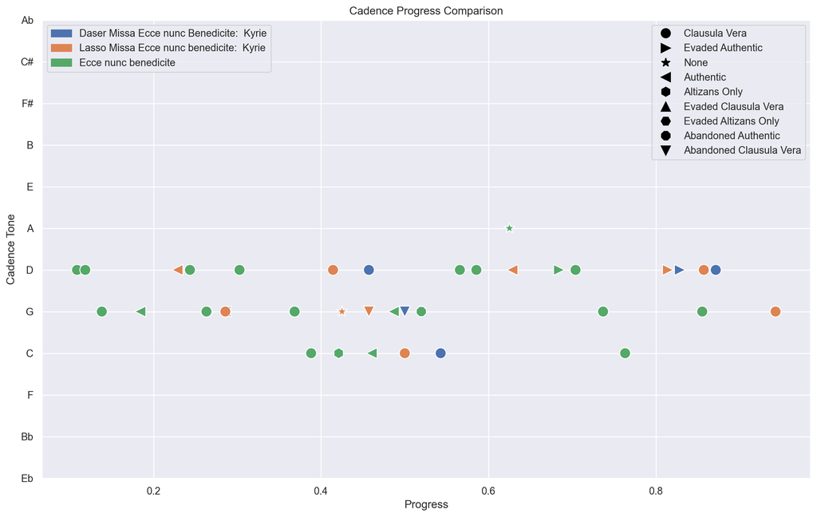

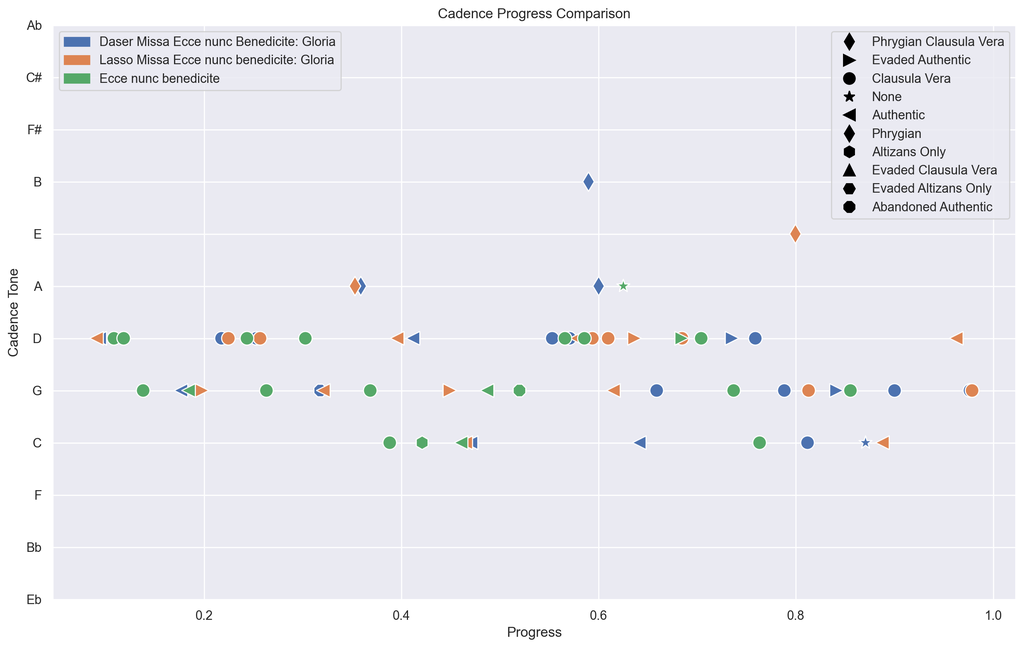

```
mei.base: WARNING: Importing <tie> without @startid and @endid is not yet supported.
```

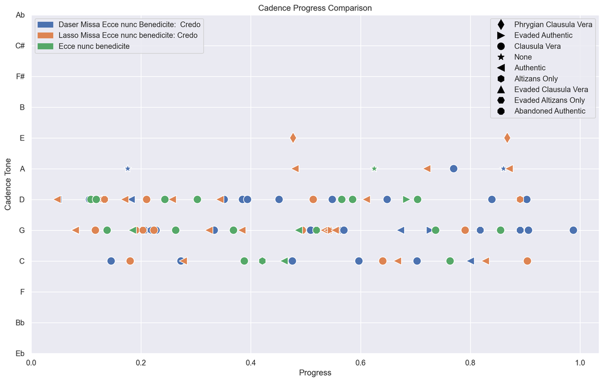

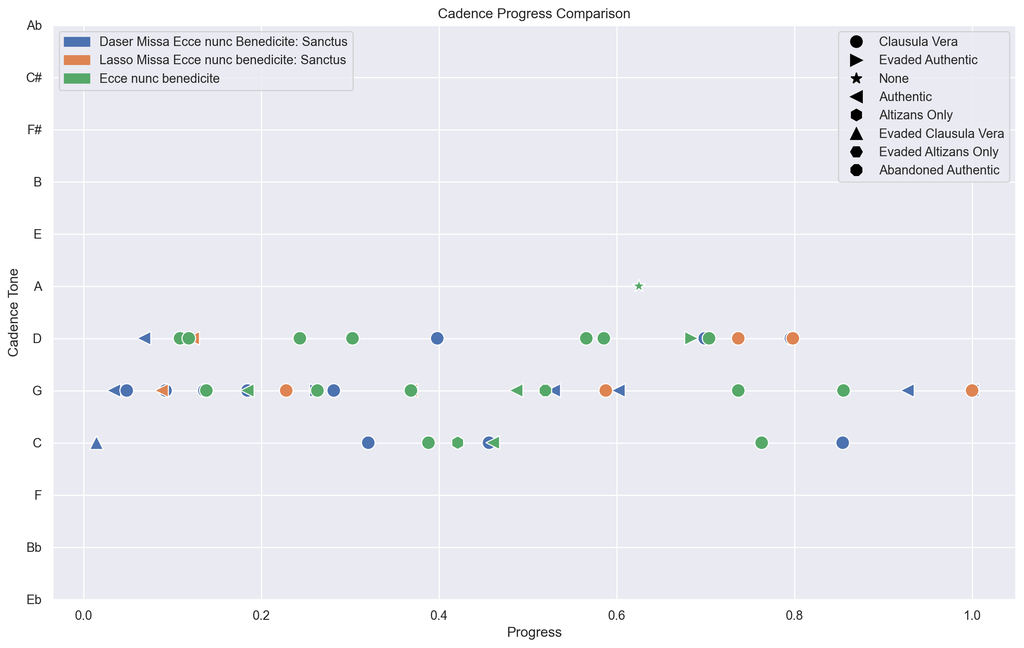

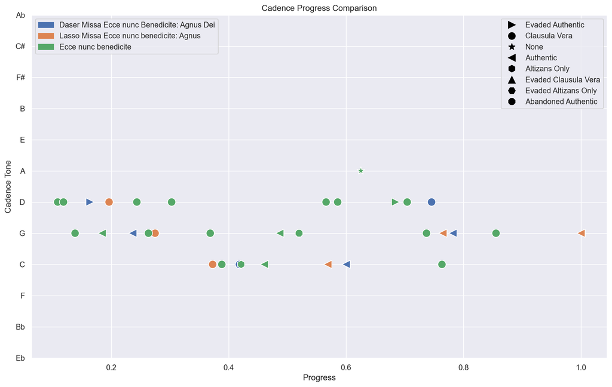

```python
movement_ids = [1, 2, 3, 4, 5]

model =  'Music_Files/Daser_Motette_Ecce-nunc_E.mei'
file_paths = glob.glob('Music_Files/*.*')
# The string we're looking for
for movement_id in movement_ids:
    # Filter the list of file paths
    filtered_paths = [path for path in file_paths if str(movement_id) in path]
    filtered_paths.append(model)
    corpus = CorpusBase(filtered_paths)
    corpus.compareCadenceProgressPlots(includeType = True)
```

### A Network of Cadences

Here we render the pieces as a network based on their shared cadences. In this case the simple information about tone or type alone (and tone and type combined) will not be sufficient for us to understand much about the connections among compositions.

A more subtle way of tracing the ‘cadential similarity’ is to find shared *pairs of cadences*.

In python we can do this with a few lines of code. Working with the `Tone`, `CadType` and `CVFs` (or ‘cadential voice functions’) columns of our results, we can:

- combine these features into a single categorical ‘combined’ tag
- combine *successive pairs* of cadences into a ‘paired_cadences’ tag with the `shift()` method in Pandas.

Here is what the code looks like:

```python
# create a new column that combines data from several others, so we get a complex cadence type
corpus_cadences['combined'] = corpus_cadences['Tone'] + "_" + corpus_cadences['CadType'] + "_" + corpus_cadences['CVFs']
# and now combine a given cadence tag with the following one
corpus_cadences['paired_cadences'] = corpus_cadences['combined'] + "_" + corpus_cadences['combined'].shift(-1)

# fill in the last cell, so there is no NAN, and that we get the final cadence
corpus_cadences['paired_cadences'].iloc[-1] = corpus_cadences['combined'].iloc[-1]
```

After the groupby operations, we then can return a table that shows the number of times that any pair of pieces shares one of these pairs of cadences. Here is a sample:

```
count
title_pairs
(Daser Missa Ecce nunc Benedicite: Sanctus, Daser Missa Ecce nunc Benedicite: Credo)    4
(Lasso Missa Ecce nunc benedicite: Kyrie, Lasso Missa Ecce nunc benedicite: Credo)  3
(Ecce nunc benedicite, Daser Missa Ecce nunc Benedicite: Credo) 3
(Daser Missa Ecce nunc Benedicite: Gloria, Ecce nunc benedicite)    2
(Lasso Missa Ecce nunc benedicite: Sanctus, Lasso Missa Ecce nunc benedicite: Credo)    2
```

```python
# create a new column that combines data from several others, so we get a complex cadence type
corpus_cadences['combined'] = corpus_cadences['Tone'] + "_" + corpus_cadences['CadType'] + "_" + corpus_cadences['CVFs']

corpus_cadences['paired_cadences'] = corpus_cadences['combined'] + "_" + corpus_cadences['combined'].shift(-1)

# fill in the last cell, so there is no NA and that we get the final cadence
corpus_cadences['paired_cadences'].iloc[-1] = corpus_cadences['combined'].iloc[-1]
# group the cadences by this combined tag and get the titles
grouped_titles = corpus_cadences.groupby('paired_cadences')['Title'].unique().reset_index(name='titles')

# Generate all pairs of titles for each group
all_pairs = []
for _, row in grouped_titles.iterrows():
    pairs = list(combinations(row['titles'], 2))
    all_pairs.append((row['paired_cadences'], pairs))

# Create a new DataFrame with the results
result_df = pd.DataFrame(all_pairs, columns=['paired_cadences', 'title_pairs'])

# remove the empty pairs
df_filtered = result_df[result_df['title_pairs'].apply(len) > 0]

# explode the complicated lists of tuples, effectively 'tyding' the data
exploded_df = df_filtered.explode('title_pairs')

# get the counts of each pair, which provides the basis of the weights
pair_counts = exploded_df['title_pairs'].value_counts()

#pair_counts = pair_counts[pair_counts >= 1]

# Adding Louvain Communities
def add_communities(G):
    G = deepcopy(G)
    partition = community_louvain.best_partition(G)
    nx.set_node_attributes(G, partition, "group")
    return G

# Create an empty NetworkX graph
G = nx.Graph()

# Add nodes and assign weights to edges
for pair, count in pair_counts.items():
    # Directly unpacking the tuple into node1 and node2
    node1, node2 = pair
    # Adding nodes if they don't exist already
    if node1 not in G.nodes:
        G.add_node(node1)
    if node2 not in G.nodes:
        G.add_node(node2)
    # Adding edge with weight
    G.add_edge(node1, node2, weight=count)

# Adjusting edge thickness based on weights
for edge in G.edges(data=True):
    edge[2]['width'] = edge[2]['weight']

G = add_communities(G)

# set display parameters
cad_network = Network(notebook=True,
                   width="800",
                          height="800",
                          bgcolor="black",
                          font_color="white")

# Set the physics layout of the network
cad_network.set_options("""
{
"physics": {
"enabled": true,
"forceAtlas2Based": {
    "springLength": 1
},
"solver": "forceAtlas2Based"
}
}
""")

cad_network.from_nx(G)
# # return the network
cad_network.show("cad_network.html")
```

[interactive chart not shown]

### Interpretation of Cadence Analysis

The network in particular shows the centrality of the motet (which shares a number of pairs with all the other mass movements.

But note, too, how the Kyrie and Gloria movements of the masses fall into different communities of similarity.

## Presentation Types

CRIM Intervals allows us to find typical imitative combinations, such as fuga, imitative duos, and periodic entries. Read more [here](https://github.com/HCDigitalScholarship/intervals/blob/main/tutorial/12_Presentation_Types.md).

Note that is is also possible to sort the results (by soggetto, or some other feature), or to filter them. We don’t show that here.

```python
# We also need to load the files from GIT, for the LinkExample function

prefix = 'https://raw.githubusercontent.com/RichardFreedman/CRIM_Additions/main/Daser_Missa_Ecce_nunc/MEI/'

# piece_id = 'Daser_Missa_Ecce_nunc_01_E.mei'
# piece_id = 'Daser_Motette_Ecce-nunc_E.mei'
dfs = []

for path in file_list:
    piece_id = os.path.basename(path)
    url = prefix + piece_id
    piece = importScore(url)
    pt=piece.presentationTypes(limit_to_entries = True,
                        head_flex=1,
                        body_flex = 0,
                        include_hidden_types = False,
                        combine_unisons = False,
                        melodic_ngram_length = 2)



    # filter for a given type or tone
    # cd = cd.loc[cd['CVFs'] == 'CTb']



    pt = pt.reindex(columns=['Composer', 'Presentation_Type', 'Title', 'First_Offset', 'Measures_Beats', 'Melodic_Entry_Intervals', 'Offsets', 'Soggetti', 'Time_Entry_Intervals', 'Voices', 'Number_Entries', 'Flexed_Entries', 'Parallel_Entries', 'Parallel_Voice', 'Count_Non_Overlaps', 'Progress'])

    # pt = pt.head()
    print(piece.metadata)
    piece.linkExamples(df=pt, piece_url=url)
```

```
{'title': 'Missa Ecce nunc Benedicite: Sanctus', 'composer': 'Ludovi[cus] Daser', 'date': None}
```

|  | Composer | Presentation_Type | Title | First_Offset | Measures_Beats | Melodic_Entry_Intervals | Offsets | Soggetti | Time_Entry_Intervals | Voices | Number_Entries | Flexed_Entries | Parallel_Entries | Parallel_Voice | Count_Non_Overlaps | Progress |
| --- | --- | --- | --- | --- | --- | --- | --- | --- | --- | --- | --- | --- | --- | --- | --- | --- |
| 0 | Ludovi[cus] Daser | FUGA | Missa Ecce nunc Benedicite: Sanctus | 0.0 | [1.0/1.0, 8.0/4.0, 9.0/2.0, 15.0/4.0] | [P5, P-8, M13] | [0.0, 62.0, 66.0, 118.0] | [(2, 2), (3, 2), (1, 2)] | [62.0, 4.0, 52.0] | [Tenor, Contratenor, Bassus, Discantus] | 4 | True | True | Tenor | 2 | 0.000000 |
| 1 | Ludovi[cus] Daser | FUGA | Missa Ecce nunc Benedicite: Sanctus | 0.0 | [1.0/1.0, 8.0/4.0, 9.0/2.0] | [P5, P-8] | [0.0, 62.0, 66.0] | [(2, 2), (3, 2)] | [62.0, 4.0] | [Tenor, Contratenor, Bassus] | 3 | True | False | None | 1 | 0.000000 |
| 2 | Ludovi[cus] Daser | PEN | Missa Ecce nunc Benedicite: Sanctus | 176.0 | [23.0/1.0, 25.0/1.0, 27.0/1.0] | [P5, P-8] | [176.0, 192.0, 208.0] | [(1, 1), (2, 1)] | [16.0, 16.0] | [Contratenor, Discantus, Tenor] | 3 | True | False | None | 0 | 0.213592 |
| 3 | Ludovi[cus] Daser | FUGA | Missa Ecce nunc Benedicite: Sanctus | 266.0 | [34.0/2.0, 34.0/4.0, 35.0/2.0, 37.0/2.0, 37.0/3.0, 40.0/1.0, 42.0/3.0] | [P5, P-8, P4, P5, P-4, M-9] | [266.0, 270.0, 274.0, 290.0, 292.0, 312.0, 336.0] | [(-3, 3), (-4, 3), (-2, 3)] | [4.0, 4.0, 16.0, 2.0, 20.0, 24.0] | [Tenor, Discantus, Contratenor, Contratenor, Discantus, Contratenor, Bassus] | 7 | True | False | None | 2 | 0.322816 |
| 4 | Ludovi[cus] Daser | FUGA | Missa Ecce nunc Benedicite: Sanctus | 266.0 | [34.0/2.0, 34.0/4.0, 35.0/2.0, 37.0/2.0, 37.0/3.0, 40.0/1.0] | [P5, P-8, P4, P5, P-4] | [266.0, 270.0, 274.0, 290.0, 292.0, 312.0] | [(-3, 3), (-4, 3)] | [4.0, 4.0, 16.0, 2.0, 20.0] | [Tenor, Discantus, Contratenor, Contratenor, Discantus, Contratenor] | 6 | True | False | None | 1 | 0.322816 |
| 5 | Ludovi[cus] Daser | FUGA | Missa Ecce nunc Benedicite: Sanctus | 512.0 | [58.0/1.0, 59.0/2.0, 60.0/2.0] | [P-8, P5] | [512.0, 522.0, 530.0] | [(-2, 2)] | [10.0, 8.0] | [Tenor, Bassus, Tenor] | 3 | False | False | None | 0 | 0.621359 |
| 6 | Ludovi[cus] Daser | FUGA | Missa Ecce nunc Benedicite: Sanctus | 538.0 | [61.0/2.0, 62.0/2.0] | [P5] | [538.0, 546.0] | [(2, 2), (1, 2)] | [8.0] | [Bassus, Tenor] | 2 | True | False | None | 0 | 0.652913 |
| 7 | Ludovi[cus] Daser | FUGA | Missa Ecce nunc Benedicite: Sanctus | 538.0 | [61.0/2.0, 62.0/2.0] | [P5] | [538.0, 546.0] | [(2, 2), (3, 2), (1, 2)] | [8.0] | [Bassus, Tenor] | 2 | True | False | None | 0 | 0.652913 |
| 8 | Ludovi[cus] Daser | FUGA | Missa Ecce nunc Benedicite: Sanctus | 538.0 | [61.0/2.0, 62.0/2.0] | [P5] | [538.0, 546.0] | [(2, 2), (3, 2)] | [8.0] | [Bassus, Tenor] | 2 | True | False | None | 0 | 0.652913 |
| 9 | Ludovi[cus] Daser | ID | Missa Ecce nunc Benedicite: Sanctus | 582.0 | [66.0/4.0, 67.0/4.0, 71.0/4.0, 72.0/4.0] | [P5, P-5, P5] | [582.0, 590.0, 622.0, 630.0] | [(1, -2)] | [8.0, 32.0, 8.0] | [Bassus, Tenor, Bassus, Tenor] | 4 | False | False | None | 0 | 0.706311 |

```
{'title': 'Missa Ecce nunc Benedicite: Gloria', 'composer': 'Ludovi[cus] Daser', 'date': None}
```

|  | Composer | Presentation_Type | Title | First_Offset | Measures_Beats | Melodic_Entry_Intervals | Offsets | Soggetti | Time_Entry_Intervals | Voices | Number_Entries | Flexed_Entries | Parallel_Entries | Parallel_Voice | Count_Non_Overlaps | Progress |
| --- | --- | --- | --- | --- | --- | --- | --- | --- | --- | --- | --- | --- | --- | --- | --- | --- |
| 0 | Ludovi[cus] Daser | FUGA | Missa Ecce nunc Benedicite: Gloria | 0.0 | [1.0/1.0, 1.0/3.0, 2.0/3.0] | [P-8, P1] | [0.0, 4.0, 12.0] | [(1, 5)] | [4.0, 8.0] | [Discantus, Contratenor, Tenor] | 3 | False | False | None | 0 | 0.000000 |
| 1 | Ludovi[cus] Daser | FUGA | Missa Ecce nunc Benedicite: Gloria | 24.0 | [4.0/1.0, 5.0/1.0, 6.0/1.0, 9.0/4.0, 10.0/3.0, 16.0/4.0, 17.0/1.0, 19.0/4.0, 20.0/1.0, 23.0/2.0, 28.0/2.0] | [P1, P-5, P12, P-8, P8, P-5, P-4, P-5, M9, M-3, m-10] | [24.0, 32.0, 40.0, 70.0, 76.0, 126.0, 128.0, 150.0, 152.0, 178.0, 218.0, 218.0] | [(1, 1), (2, 1)] | [8.0, 8.0, 30.0, 6.0, 50.0, 2.0, 22.0, 2.0, 26.0, 40.0, 0.0] | [Contratenor, Tenor, Bassus, Discantus, Tenor, Discantus, Contratenor, Tenor, Bassus, Contratenor, Contratenor, Bassus] | 12 | True | True | Tenor | 1 | 0.035294 |
| 2 | Ludovi[cus] Daser | FUGA | Missa Ecce nunc Benedicite: Gloria | 24.0 | [4.0/1.0, 5.0/1.0, 6.0/1.0, 9.0/4.0, 10.0/3.0, 16.0/4.0, 17.0/1.0, 19.0/4.0, 20.0/1.0, 23.0/2.0, 28.0/2.0] | [P1, P-5, P12, P-8, P8, P-5, P-4, P-5, M9, M-3, m-10] | [24.0, 32.0, 40.0, 70.0, 76.0, 126.0, 128.0, 150.0, 152.0, 178.0, 218.0, 218.0] | [(1, 1), (3, 1), (2, 1)] | [8.0, 8.0, 30.0, 6.0, 50.0, 2.0, 22.0, 2.0, 26.0, 40.0, 0.0] | [Contratenor, Tenor, Bassus, Discantus, Tenor, Discantus, Contratenor, Tenor, Bassus, Contratenor, Contratenor, Bassus] | 12 | True | True | Tenor | 1 | 0.035294 |
| 3 | Ludovi[cus] Daser | FUGA | Missa Ecce nunc Benedicite: Gloria | 70.0 | [9.0/4.0, 10.0/3.0] | [P-8] | [70.0, 76.0] | [(3, 2), (2, 2), (1, 2)] | [6.0] | [Contratenor, Bassus] | 2 | True | False | None | 0 | 0.102941 |
| 4 | Ludovi[cus] Daser | FUGA | Missa Ecce nunc Benedicite: Gloria | 70.0 | [9.0/4.0, 10.0/3.0] | [P-8] | [70.0, 76.0] | [(3, 2), (2, 2)] | [6.0] | [Contratenor, Bassus] | 2 | True | False | None | 0 | 0.102941 |
| 5 | Ludovi[cus] Daser | FUGA | Missa Ecce nunc Benedicite: Gloria | 288.0 | [37.0/1.0, 39.0/4.0] | [P-8] | [288.0, 310.0] | [(1, -3), (2, -3)] | [22.0] | [Contratenor, Bassus] | 2 | True | False | None | 0 | 0.423529 |
| 6 | Ludovi[cus] Daser | FUGA | Missa Ecce nunc Benedicite: Gloria | 332.0 | [42.0/3.0, 43.0/2.0, 44.0/3.0] | [P5, P-8] | [332.0, 338.0, 348.0] | [(5, 1)] | [6.0, 10.0] | [Contratenor, Discantus, Tenor] | 3 | False | False | None | 0 | 0.488235 |
| 7 | Ludovi[cus] Daser | FUGA | Missa Ecce nunc Benedicite: Gloria | 382.0 | [48.0/4.0, 56.0/2.0, 63.0/1.0] | [M-6, m-3] | [382.0, 442.0, 496.0] | [(2, 2), (1, 2)] | [60.0, 54.0] | [Discantus, Contratenor, Bassus] | 3 | True | False | None | 2 | 0.561765 |
| 8 | Ludovi[cus] Daser | FUGA | Missa Ecce nunc Benedicite: Gloria | 382.0 | [48.0/4.0, 56.0/2.0, 63.0/1.0] | [M-6, m-3] | [382.0, 442.0, 496.0] | [(3, 2), (2, 2), (1, 2)] | [60.0, 54.0] | [Discantus, Contratenor, Bassus] | 3 | True | False | None | 2 | 0.561765 |
| 9 | Ludovi[cus] Daser | FUGA | Missa Ecce nunc Benedicite: Gloria | 442.0 | [56.0/2.0, 63.0/4.0, 65.0/1.0, 68.0/2.0] | [m-7, M9, M-9] | [442.0, 502.0, 512.0, 538.0] | [(1, -2), (3, -2), (2, -2)] | [60.0, 10.0, 26.0] | [Discantus, Tenor, Discantus, Contratenor] | 4 | True | False | None | 1 | 0.650000 |
| 10 | Ludovi[cus] Daser | FUGA | Missa Ecce nunc Benedicite: Gloria | 442.0 | [56.0/2.0, 65.0/1.0, 68.0/2.0] | [M3, M-9] | [442.0, 512.0, 538.0] | [(1, -2), (2, -2)] | [70.0, 26.0] | [Discantus, Discantus, Contratenor] | 3 | True | False | None | 1 | 0.650000 |
| 11 | Ludovi[cus] Daser | PEN | Missa Ecce nunc Benedicite: Gloria | 454.0 | [57.0/4.0, 58.0/4.0, 59.0/4.0] | [P-8, P8] | [454.0, 462.0, 470.0] | [(1, 1), (3, 1), (2, 1)] | [8.0, 8.0] | [Discantus, Tenor, Discantus] | 3 | True | True | Contratenor | 0 | 0.667647 |
| 12 | Ludovi[cus] Daser | PEN | Missa Ecce nunc Benedicite: Gloria | 454.0 | [57.0/4.0, 58.0/4.0, 59.0/4.0] | [P-8, P8] | [454.0, 462.0, 470.0] | [(1, 1), (2, 1)] | [8.0, 8.0] | [Discantus, Tenor, Discantus] | 3 | True | True | Contratenor | 0 | 0.667647 |
| 13 | Ludovi[cus] Daser | FUGA | Missa Ecce nunc Benedicite: Gloria | 502.0 | [63.0/4.0, 65.0/1.0, 68.0/2.0] | [M9, M-9] | [502.0, 512.0, 538.0] | [(3, -2), (2, -2)] | [10.0, 26.0] | [Tenor, Discantus, Contratenor] | 3 | True | False | None | 0 | 0.738235 |
| 14 | Ludovi[cus] Daser | FUGA | Missa Ecce nunc Benedicite: Gloria | 506.0 | [64.0/2.0, 68.0/2.0, 70.0/2.0, 70.0/4.0, 72.0/3.0, 73.0/2.0, 75.0/4.0] | [P-4, P8, P5, M-9, P5, m7] | [506.0, 538.0, 554.0, 558.0, 572.0, 578.0, 598.0] | [(-2, -2)] | [32.0, 16.0, 4.0, 14.0, 6.0, 20.0] | [Contratenor, Bassus, Tenor, Discantus, Bassus, Contratenor, Discantus] | 7 | False | True | Bassus | 1 | 0.744118 |
| 15 | Ludovi[cus] Daser | ID | Missa Ecce nunc Benedicite: Gloria | 618.0 | [78.0/2.0, 80.0/2.0] | [m-6, m6, m-6] | [618.0, 618.0, 634.0, 634.0] | [(3, 1), (2, 1)] | [0.0, 16.0, 0.0] | [Discantus, Tenor, Discantus, Tenor] | 4 | True | True | Contratenor | 1 | 0.908824 |
| 16 | Ludovi[cus] Daser | FUGA | Missa Ecce nunc Benedicite: Gloria | 618.0 | [78.0/2.0, 80.0/2.0, 84.0/4.0] | [m-6, m6, m-6, P1] | [618.0, 618.0, 634.0, 634.0, 670.0] | [(1, 1), (3, 1), (2, 1)] | [0.0, 16.0, 0.0, 36.0] | [Discantus, Tenor, Discantus, Tenor, Tenor] | 5 | True | True | Contratenor | 2 | 0.908824 |
| 17 | Ludovi[cus] Daser | FUGA | Missa Ecce nunc Benedicite: Gloria | 618.0 | [78.0/2.0, 80.0/2.0, 84.0/4.0] | [P1, m-6] | [618.0, 634.0, 670.0] | [(1, 1), (2, 1)] | [16.0, 36.0] | [Discantus, Discantus, Tenor] | 3 | True | True | Tenor | 1 | 0.908824 |

```
{'title': 'Missa Ecce nunc Benedicite: Agnus Dei', 'composer': 'Ludovi[cus] Daser', 'date': None}
```

|  | Composer | Presentation_Type | Title | First_Offset | Measures_Beats | Melodic_Entry_Intervals | Offsets | Soggetti | Time_Entry_Intervals | Voices | Number_Entries | Flexed_Entries | Parallel_Entries | Parallel_Voice | Count_Non_Overlaps | Progress |
| --- | --- | --- | --- | --- | --- | --- | --- | --- | --- | --- | --- | --- | --- | --- | --- | --- |
| 0 | Ludovi[cus] Daser | ID | Missa Ecce nunc Benedicite: Agnus Dei | 54.0 | [7.0/4.0, 8.0/2.0, 9.0/4.0, 10.0/2.0, 12.0/4.0, 13.0/2.0] | [P-5, P-4, P-5, P15, P-8] | [54.0, 58.0, 70.0, 74.0, 94.0, 98.0] | [(1, -3)] | [4.0, 12.0, 4.0, 20.0, 4.0] | [Discantus, Alt, Tenor, Bassus, Discantus, Tenor] | 6 | False | False | None | 0 | 0.245455 |

```
{'title': 'Ecce nunc benedicite', 'composer': 'Ludwig Daser', 'date': None}
```

|  | Composer | Presentation_Type | Title | First_Offset | Measures_Beats | Melodic_Entry_Intervals | Offsets | Soggetti | Time_Entry_Intervals | Voices | Number_Entries | Flexed_Entries | Parallel_Entries | Parallel_Voice | Count_Non_Overlaps | Progress |
| --- | --- | --- | --- | --- | --- | --- | --- | --- | --- | --- | --- | --- | --- | --- | --- | --- |
| 0 | Ludwig Daser | FUGA | Ecce nunc benedicite | 0.0 | [1.0/1.0, 1.0/3.0, 2.0/3.0, 6.0/1.0] | [P-8, P1, P1] | [0.0, 4.0, 12.0, 40.0] | [(1, 5)] | [4.0, 8.0, 28.0] | [Sopran, Alt, Tenor, Bass] | 4 | False | False | None | 1 | 0.000000 |
| 1 | Ludwig Daser | FUGA | Ecce nunc benedicite | 20.0 | [3.0/3.0, 4.0/1.0, 5.0/1.0] | [P8, P1] | [20.0, 24.0, 32.0] | [(1, 4)] | [4.0, 8.0] | [Bass, Alt, Tenor] | 3 | False | False | None | 0 | 0.032895 |
| 2 | Ludwig Daser | FUGA | Ecce nunc benedicite | 118.0 | [15.0/4.0, 16.0/4.0, 19.0/4.0, 21.0/2.0, 24.0/2.0, 24.0/4.0, 26.0/2.0, 27.0/2.0, 34.0/4.0] | [P-5, P-4, P-5, P12, P-5, P-4, P-5, P8] | [118.0, 126.0, 150.0, 162.0, 186.0, 190.0, 202.0, 210.0, 270.0] | [(-3, 2)] | [8.0, 24.0, 12.0, 24.0, 4.0, 12.0, 8.0, 60.0] | [Sopran, Alt, Tenor, Bass, Sopran, Alt, Tenor, Bass, Alt] | 9 | False | False | None | 1 | 0.194079 |
| 3 | Ludwig Daser | FUGA | Ecce nunc benedicite | 230.0 | [29.0/4.0, 30.0/2.0, 31.0/2.0, 31.0/3.0, 31.0/4.0, 33.0/2.0, 33.0/4.0, 36.0/4.0] | [P12, M-9, M6, P-5, P-8, P11, P-11] | [230.0, 234.0, 242.0, 244.0, 246.0, 258.0, 262.0, 286.0] | [(2, -3)] | [4.0, 8.0, 2.0, 2.0, 12.0, 4.0, 24.0] | [Alt, Sopran, Bass, Sopran, Tenor, Bass, Sopran, Bass] | 8 | False | False | None | 0 | 0.378289 |
| 4 | Ludwig Daser | FUGA | Ecce nunc benedicite | 304.0 | [39.0/1.0, 39.0/4.0, 41.0/1.0, 43.0/4.0] | [P5, P-8, P-5] | [304.0, 310.0, 320.0, 342.0] | [(5, -2)] | [6.0, 10.0, 22.0] | [Alt, Sopran, Tenor, Bass] | 4 | False | False | None | 0 | 0.500000 |
| 5 | Ludwig Daser | PEN | Ecce nunc benedicite | 382.0 | [48.0/4.0, 49.0/4.0, 50.0/4.0] | [P1, P8] | [382.0, 390.0, 398.0] | [(1, 1), (2, 1)] | [8.0, 8.0] | [Alt, Tenor, Sopran] | 3 | True | True | Alt | 0 | 0.628289 |
| 6 | Ludwig Daser | FUGA | Ecce nunc benedicite | 412.0 | [52.0/3.0, 54.0/1.0] | [P12] | [412.0, 424.0] | [(2, -2), (3, -2)] | [12.0] | [Bass, Sopran] | 2 | True | False | None | 0 | 0.677632 |
| 7 | Ludwig Daser | FUGA | Ecce nunc benedicite | 434.0 | [55.0/2.0, 57.0/2.0, 59.0/2.0, 59.0/4.0, 60.0/4.0, 61.0/4.0, 62.0/2.0, 62.0/4.0, 64.0/2.0] | [P-5, P8, P5, P-5, P-5, P5, P5, P-8] | [434.0, 450.0, 466.0, 470.0, 478.0, 486.0, 490.0, 494.0, 506.0] | [(-2, -2)] | [16.0, 16.0, 4.0, 8.0, 8.0, 4.0, 4.0, 12.0] | [Tenor, Bass, Tenor, Sopran, Alt, Bass, Tenor, Sopran, Bass] | 9 | False | False | None | 0 | 0.713816 |

```
{'title': 'Missa Ecce nunc Benedicite:  Credo', 'composer': 'Ludovi[cus] Daser', 'date': None}
```

|  | Composer | Presentation_Type | Title | First_Offset | Measures_Beats | Melodic_Entry_Intervals | Offsets | Soggetti | Time_Entry_Intervals | Voices | Number_Entries | Flexed_Entries | Parallel_Entries | Parallel_Voice | Count_Non_Overlaps | Progress |
| --- | --- | --- | --- | --- | --- | --- | --- | --- | --- | --- | --- | --- | --- | --- | --- | --- |
| 0 | Ludovi[cus] Daser | FUGA | Missa Ecce nunc Benedicite: Credo | 20.0 | [3.0/3.0, 4.0/1.0, 5.0/1.0, 6.0/1.0] | [P8, P1, P-5] | [20.0, 24.0, 32.0, 40.0] | [(1, 1), (2, 1), (3, 1)] | [4.0, 8.0, 8.0] | [Bassus, Contratenor, Tenor, Bassus] | 4 | True | False | None | 0 | 0.015152 |
| 1 | Ludovi[cus] Daser | FUGA | Missa Ecce nunc Benedicite: Credo | 20.0 | [3.0/3.0, 4.0/1.0, 5.0/1.0, 6.0/1.0] | [P8, P1, P-5] | [20.0, 24.0, 32.0, 40.0] | [(1, 1), (2, 1)] | [4.0, 8.0, 8.0] | [Bassus, Contratenor, Tenor, Bassus] | 4 | True | False | None | 0 | 0.015152 |
| 2 | Ludovi[cus] Daser | FUGA | Missa Ecce nunc Benedicite: Credo | 110.0 | [14.0/4.0, 15.0/4.0, 23.0/4.0, 29.0/2.0] | [P-5, P-8, M9] | [110.0, 118.0, 182.0, 226.0] | [(-3, 2), (-2, 2)] | [8.0, 64.0, 44.0] | [Discantus, Contratenor, Bassus, Discantus] | 4 | True | False | None | 1 | 0.083333 |
| 3 | Ludovi[cus] Daser | FUGA | Missa Ecce nunc Benedicite: Credo | 144.0 | [19.0/1.0, 21.0/4.0, 22.0/2.0, 23.0/4.0, 31.0/4.0, 32.0/2.0, 33.0/4.0, 35.0/2.0, 35.0/4.0, 36.0/4.0, 38.0/4.0, 43.0/4.0] | [m10, m-6, P-5, P8, P-5, P-8, P12, P-5, P-4, P-5, P5] | [144.0, 166.0, 170.0, 182.0, 246.0, 250.0, 262.0, 274.0, 278.0, 286.0, 302.0, 342.0] | [(2, -2), (1, -2), (3, -2)] | [22.0, 4.0, 12.0, 64.0, 4.0, 12.0, 12.0, 4.0, 8.0, 16.0, 40.0] | [Tenor, Discantus, Contratenor, Tenor, Discantus, Contratenor, Bassus, Discantus, Contratenor, Tenor, Bassus, Tenor] | 12 | True | False | None | 1 | 0.109091 |
| 4 | Ludovi[cus] Daser | FUGA | Missa Ecce nunc Benedicite: Credo | 144.0 | [19.0/1.0, 23.0/4.0, 31.0/4.0, 32.0/2.0, 33.0/4.0, 35.0/2.0, 35.0/4.0, 36.0/4.0] | [P1, P8, P-5, P-8, P12, P-5, P-4] | [144.0, 182.0, 246.0, 250.0, 262.0, 274.0, 278.0, 286.0] | [(2, -2), (3, -2)] | [38.0, 64.0, 4.0, 12.0, 12.0, 4.0, 8.0] | [Tenor, Tenor, Discantus, Contratenor, Bassus, Discantus, Contratenor, Tenor] | 8 | True | False | None | 2 | 0.109091 |
| 5 | Ludovi[cus] Daser | FUGA | Missa Ecce nunc Benedicite: Credo | 144.0 | [19.0/1.0, 21.0/4.0, 22.0/2.0, 23.0/4.0, 31.0/4.0, 32.0/2.0, 33.0/4.0, 35.0/2.0, 35.0/4.0, 36.0/4.0, 38.0/4.0, 43.0/4.0] | [m10, m-6, P-5, P8, P-5, P-8, P12, P-5, P-4, P-5, P5] | [144.0, 166.0, 170.0, 182.0, 246.0, 250.0, 262.0, 274.0, 278.0, 286.0, 302.0, 342.0] | [(2, -2), (1, -2)] | [22.0, 4.0, 12.0, 64.0, 4.0, 12.0, 12.0, 4.0, 8.0, 16.0, 40.0] | [Tenor, Discantus, Contratenor, Tenor, Discantus, Contratenor, Bassus, Discantus, Contratenor, Tenor, Bassus, Tenor] | 12 | True | False | None | 1 | 0.109091 |
| 6 | Ludovi[cus] Daser | FUGA | Missa Ecce nunc Benedicite: Credo | 246.0 | [31.0/4.0, 36.0/3.0] | [P-8] | [246.0, 284.0] | [(-2, 4)] | [38.0] | [Tenor, Bassus] | 2 | False | False | None | 0 | 0.186364 |
| 7 | Ludovi[cus] Daser | FUGA | Missa Ecce nunc Benedicite: Credo | 366.0 | [46.0/4.0, 47.0/2.0] | [P5] | [366.0, 370.0] | [(1, 3)] | [4.0] | [Contratenor, Discantus] | 2 | False | False | None | 0 | 0.277273 |
| 8 | Ludovi[cus] Daser | FUGA | Missa Ecce nunc Benedicite: Credo | 390.0 | [49.0/4.0, 50.0/2.0] | [P5] | [390.0, 394.0] | [(-3, 2), (-2, 2)] | [4.0] | [Contratenor, Discantus] | 2 | True | False | None | 0 | 0.295455 |
| 9 | Ludovi[cus] Daser | FUGA | Missa Ecce nunc Benedicite: Credo | 422.0 | [53.0/4.0, 54.0/2.0, 56.0/2.5, 56.0/4.0] | [P8, P-8, P8] | [422.0, 426.0, 443.0, 446.0] | [(2, -2), (1, -2), (3, -2)] | [4.0, 17.0, 3.0] | [Contratenor, Discantus, Contratenor, Discantus] | 4 | True | False | None | 0 | 0.319697 |
| 10 | Ludovi[cus] Daser | FUGA | Missa Ecce nunc Benedicite: Credo | 422.0 | [53.0/4.0, 54.0/2.0, 56.0/2.5, 56.0/4.0] | [P8, P-8, P8] | [422.0, 426.0, 443.0, 446.0] | [(2, -2), (1, -2)] | [4.0, 17.0, 3.0] | [Contratenor, Discantus, Contratenor, Discantus] | 4 | True | False | None | 0 | 0.319697 |
| 11 | Ludovi[cus] Daser | FUGA | Missa Ecce nunc Benedicite: Credo | 466.0 | [59.0/2.0, 61.0/2.0] | [P5, P-5, P-8] | [466.0, 482.0, 482.0, 482.0] | [(1, 1), (2, 1)] | [16.0, 0.0, 0.0] | [Tenor, Discantus, Tenor, Bassus] | 4 | True | True | Contratenor | 1 | 0.353030 |
| 12 | Ludovi[cus] Daser | FUGA | Missa Ecce nunc Benedicite: Credo | 466.0 | [59.0/2.0, 61.0/2.0] | [P5, P-5, P-8] | [466.0, 482.0, 482.0, 482.0] | [(1, 1), (2, 1), (3, 1)] | [16.0, 0.0, 0.0] | [Tenor, Discantus, Tenor, Bassus] | 4 | True | True | Contratenor | 1 | 0.353030 |
| 13 | Ludovi[cus] Daser | FUGA | Missa Ecce nunc Benedicite: Credo | 582.0 | [73.0/4.0, 74.0/4.0] | [P5] | [582.0, 590.0] | [(-3, 2), (-2, 2)] | [8.0] | [Bassus, Tenor] | 2 | True | False | None | 0 | 0.440909 |
| 14 | Ludovi[cus] Daser | ID | Missa Ecce nunc Benedicite: Credo | 634.0 | [80.0/2.0, 80.0/4.0, 82.0/4.0, 83.0/2.0] | [P5, P-8, P5] | [634.0, 638.0, 654.0, 658.0] | [(-2, -2)] | [4.0, 16.0, 4.0] | [Bassus, Tenor, Bassus, Tenor] | 4 | False | False | None | 0 | 0.480303 |
| 15 | Ludovi[cus] Daser | PEN | Missa Ecce nunc Benedicite: Credo | 672.0 | [85.0/1.0, 85.0/3.0, 86.0/1.0] | [P5, P-8] | [672.0, 676.0, 680.0] | [(1, 1), (2, 1)] | [4.0, 4.0] | [Contratenor, Discantus, Tenor] | 3 | True | False | None | 0 | 0.509091 |
| 16 | Ludovi[cus] Daser | PEN | Missa Ecce nunc Benedicite: Credo | 672.0 | [85.0/1.0, 85.0/3.0, 86.0/1.0] | [P5, P-8] | [672.0, 676.0, 680.0] | [(1, 1), (2, 1), (3, 1)] | [4.0, 4.0] | [Contratenor, Discantus, Tenor] | 3 | True | False | None | 0 | 0.509091 |
| 17 | Ludovi[cus] Daser | PEN | Missa Ecce nunc Benedicite: Credo | 702.0 | [88.0/4.0, 89.0/2.0, 89.0/4.0] | [P5, P-8] | [702.0, 706.0, 710.0] | [(2, 2), (1, 2), (3, 2)] | [4.0, 4.0] | [Contratenor, Discantus, Tenor] | 3 | True | False | None | 0 | 0.531818 |
| 18 | Ludovi[cus] Daser | PEN | Missa Ecce nunc Benedicite: Credo | 702.0 | [88.0/4.0, 89.0/2.0, 89.0/4.0] | [P5, P-8] | [702.0, 706.0, 710.0] | [(2, 2), (1, 2)] | [4.0, 4.0] | [Contratenor, Discantus, Tenor] | 3 | True | False | None | 0 | 0.531818 |
| 19 | Ludovi[cus] Daser | PEN | Missa Ecce nunc Benedicite: Credo | 702.0 | [88.0/4.0, 89.0/2.0, 89.0/4.0] | [P5, P-8] | [702.0, 706.0, 710.0] | [(2, 2), (3, 2)] | [4.0, 4.0] | [Contratenor, Discantus, Tenor] | 3 | True | False | None | 0 | 0.531818 |
| 20 | Ludovi[cus] Daser | FUGA | Missa Ecce nunc Benedicite: Credo | 726.0 | [91.0/4.0, 92.0/3.0, 93.0/4.0] | [P1, P8] | [726.0, 732.0, 742.0] | [(-5, 8)] | [6.0, 10.0] | [Tenor, Contratenor, Discantus] | 3 | False | False | None | 0 | 0.550000 |
| 21 | Ludovi[cus] Daser | PEN | Missa Ecce nunc Benedicite: Credo | 790.0 | [99.0/4.0, 100.0/2.0, 100.0/4.0] | [P8, m-6] | [790.0, 794.0, 798.0] | [(1, 1), (2, 1)] | [4.0, 4.0] | [Tenor, Discantus, Contratenor] | 3 | True | False | None | 0 | 0.598485 |
| 22 | Ludovi[cus] Daser | PEN | Missa Ecce nunc Benedicite: Credo | 790.0 | [99.0/4.0, 100.0/2.0, 100.0/4.0] | [P8, m-6] | [790.0, 794.0, 798.0] | [(1, 1), (2, 1), (3, 1)] | [4.0, 4.0] | [Tenor, Discantus, Contratenor] | 3 | True | False | None | 0 | 0.598485 |
| 23 | Ludovi[cus] Daser | FUGA | Missa Ecce nunc Benedicite: Credo | 798.0 | [100.0/4.0, 102.0/2.0, 102.0/4.0, 103.0/2.0] | [M-6, P8, P-5] | [798.0, 810.0, 814.0, 818.0] | [(2, 1), (4, 1), (3, 1)] | [12.0, 4.0, 4.0] | [Contratenor, Tenor, Discantus, Contratenor] | 4 | True | False | None | 0 | 0.604545 |
| 24 | Ludovi[cus] Daser | PEN | Missa Ecce nunc Benedicite: Credo | 810.0 | [102.0/2.0, 102.0/4.0, 103.0/2.0] | [P8, P-5] | [810.0, 814.0, 818.0] | [(5, 1), (4, 1)] | [4.0, 4.0] | [Tenor, Discantus, Contratenor] | 3 | True | False | None | 0 | 0.613636 |
| 25 | Ludovi[cus] Daser | PEN | Missa Ecce nunc Benedicite: Credo | 810.0 | [102.0/2.0, 102.0/4.0, 103.0/2.0] | [P8, P-5] | [810.0, 814.0, 818.0] | [(5, 1), (4, 1), (3, 1)] | [4.0, 4.0] | [Tenor, Discantus, Contratenor] | 3 | True | False | None | 0 | 0.613636 |
| 26 | Ludovi[cus] Daser | FUGA | Missa Ecce nunc Benedicite: Credo | 834.0 | [105.0/2.0, 105.0/4.0] | [P8] | [834.0, 838.0] | [(2, 2), (3, 2)] | [4.0] | [Tenor, Discantus] | 2 | True | False | None | 0 | 0.631818 |
| 27 | Ludovi[cus] Daser | FUGA | Missa Ecce nunc Benedicite: Credo | 834.0 | [105.0/2.0, 105.0/4.0, 110.0/2.0] | [P8, m-7] | [834.0, 838.0, 874.0] | [(2, 2), (1, 2)] | [4.0, 36.0] | [Tenor, Discantus, Contratenor] | 3 | True | False | None | 0 | 0.631818 |
| 28 | Ludovi[cus] Daser | FUGA | Missa Ecce nunc Benedicite: Credo | 834.0 | [105.0/2.0, 105.0/4.0, 110.0/2.0] | [P8, m-7] | [834.0, 838.0, 874.0] | [(2, 2), (1, 2), (3, 2)] | [4.0, 36.0] | [Tenor, Discantus, Contratenor] | 3 | True | False | None | 0 | 0.631818 |
| 29 | Ludovi[cus] Daser | FUGA | Missa Ecce nunc Benedicite: Credo | 890.0 | [112.0/2.0, 116.0/2.0, 117.0/4.0, 118.0/4.0, 121.0/2.0, 122.0/1.0, 128.0/3.0] | [M13, M-6, P-8, P1, P8, m-7] | [890.0, 922.0, 934.0, 942.0, 962.0, 968.0, 1020.0] | [(2, -3), (1, -3)] | [32.0, 12.0, 8.0, 20.0, 6.0, 52.0] | [Bassus, Discantus, Contratenor, Bassus, Bassus, Contratenor, Bassus] | 7 | True | True | Tenor | 2 | 0.674242 |
| 30 | Ludovi[cus] Daser | FUGA | Missa Ecce nunc Benedicite: Credo | 968.0 | [122.0/1.0, 123.0/1.0, 128.0/3.0] | [M-6, M2] | [968.0, 976.0, 1020.0] | [(2, 2), (1, 2)] | [8.0, 44.0] | [Discantus, Tenor, Contratenor] | 3 | True | False | None | 1 | 0.733333 |
| 31 | Ludovi[cus] Daser | FUGA | Missa Ecce nunc Benedicite: Credo | 968.0 | [122.0/1.0, 123.0/1.0, 128.0/3.0] | [M-6, M2] | [968.0, 976.0, 1020.0] | [(2, 2), (1, 2), (3, 2)] | [8.0, 44.0] | [Discantus, Tenor, Contratenor] | 3 | True | False | None | 1 | 0.733333 |
| 32 | Ludovi[cus] Daser | FUGA | Missa Ecce nunc Benedicite: Credo | 998.0 | [125.0/4.0, 128.0/4.0] | [M-6, M3] | [998.0, 998.0, 1022.0] | [(1, 1), (2, 1), (3, 1)] | [0.0, 24.0] | [Discantus, Tenor, Discantus] | 3 | True | True | Tenor | 1 | 0.756061 |
| 33 | Ludovi[cus] Daser | FUGA | Missa Ecce nunc Benedicite: Credo | 998.0 | [125.0/4.0, 128.0/4.0] | [M-6, M3] | [998.0, 998.0, 1022.0] | [(1, 1), (2, 1)] | [0.0, 24.0] | [Discantus, Tenor, Discantus] | 3 | True | True | Tenor | 1 | 0.756061 |
| 34 | Ludovi[cus] Daser | FUGA | Missa Ecce nunc Benedicite: Credo | 1068.0 | [134.0/3.0, 135.0/2.0, 136.0/3.0, 138.0/3.0, 146.0/2.0] | [P5, P-8, P5, P-5] | [1068.0, 1074.0, 1084.0, 1100.0, 1162.0] | [(5, 1), (4, 1)] | [6.0, 10.0, 16.0, 62.0] | [Contratenor, Discantus, Tenor, Contratenor, Tenor] | 5 | True | False | None | 1 | 0.809091 |
| 35 | Ludovi[cus] Daser | FUGA | Missa Ecce nunc Benedicite: Credo | 1068.0 | [134.0/3.0, 135.0/2.0, 136.0/3.0, 138.0/3.0, 145.0/2.0, 146.0/2.0] | [P5, P-8, P5, P1, P-5] | [1068.0, 1074.0, 1084.0, 1100.0, 1154.0, 1162.0] | [(5, 1), (4, 1), (3, 1)] | [6.0, 10.0, 16.0, 54.0, 8.0] | [Contratenor, Discantus, Tenor, Contratenor, Contratenor, Tenor] | 6 | True | False | None | 1 | 0.809091 |
| 36 | Ludovi[cus] Daser | FUGA | Missa Ecce nunc Benedicite: Credo | 1130.0 | [142.0/2.0, 146.0/2.0] | [m-7] | [1130.0, 1162.0] | [(-2, 1), (-3, 1), (-4, 1)] | [32.0] | [Contratenor, Bassus] | 2 | True | False | None | 1 | 0.856061 |
| 37 | Ludovi[cus] Daser | FUGA | Missa Ecce nunc Benedicite: Credo | 1130.0 | [142.0/2.0, 146.0/2.0] | [m-7] | [1130.0, 1162.0] | [(-3, 1), (-4, 1)] | [32.0] | [Contratenor, Bassus] | 2 | True | False | None | 1 | 0.856061 |
| 38 | Ludovi[cus] Daser | FUGA | Missa Ecce nunc Benedicite: Credo | 1142.0 | [143.0/4.0, 144.0/3.0] | [P-8] | [1142.0, 1148.0] | [(2, 2), (1, 2), (3, 2)] | [6.0] | [Contratenor, Bassus] | 2 | True | False | None | 0 | 0.865152 |
| 39 | Ludovi[cus] Daser | FUGA | Missa Ecce nunc Benedicite: Credo | 1142.0 | [143.0/4.0, 144.0/3.0, 150.0/4.0, 151.0/4.0, 152.0/4.0, 153.0/2.0, 153.0/4.0] | [P-8, P-5, P8, P8, m-7, M-6] | [1142.0, 1148.0, 1198.0, 1206.0, 1214.0, 1218.0, 1222.0] | [(-2, -2)] | [6.0, 50.0, 8.0, 8.0, 4.0, 4.0] | [Discantus, Tenor, Bassus, Tenor, Discantus, Contratenor, Bassus] | 7 | False | False | None | 1 | 0.865152 |
| 40 | Ludovi[cus] Daser | FUGA | Missa Ecce nunc Benedicite: Credo | 1142.0 | [143.0/4.0, 144.0/3.0] | [P-8] | [1142.0, 1148.0] | [(2, 2), (3, 2)] | [6.0] | [Contratenor, Bassus] | 2 | True | False | None | 0 | 0.865152 |
| 41 | Ludovi[cus] Daser | FUGA | Missa Ecce nunc Benedicite: Credo | 1154.0 | [145.0/2.0, 147.0/2.0, 150.0/4.0] | [P1, P-8] | [1154.0, 1170.0, 1198.0] | [(2, -2), (1, -2), (3, -2)] | [16.0, 28.0] | [Discantus, Discantus, Contratenor] | 3 | True | True | Contratenor | 1 | 0.874242 |
| 42 | Ludovi[cus] Daser | FUGA | Missa Ecce nunc Benedicite: Credo | 1154.0 | [145.0/2.0, 147.0/2.0, 150.0/4.0] | [P-5, P-4] | [1154.0, 1170.0, 1198.0] | [(2, -2), (1, -2)] | [16.0, 28.0] | [Discantus, Contratenor, Contratenor] | 3 | True | False | None | 2 | 0.874242 |
| 43 | Ludovi[cus] Daser | FUGA | Missa Ecce nunc Benedicite: Credo | 1170.0 | [147.0/2.0, 150.0/4.0] | [P-8] | [1170.0, 1198.0] | [(2, -2), (3, -2)] | [28.0] | [Discantus, Contratenor] | 2 | True | True | Contratenor | 0 | 0.886364 |
| 44 | Ludovi[cus] Daser | FUGA | Missa Ecce nunc Benedicite: Credo | 1178.0 | [148.0/2.0, 148.0/4.0] | [P4] | [1178.0, 1182.0] | [(1, -5), (2, -5)] | [4.0] | [Bassus, Tenor] | 2 | True | False | None | 0 | 0.892424 |
| 45 | Ludovi[cus] Daser | ID | Missa Ecce nunc Benedicite: Credo | 1250.0 | [157.0/2.0, 160.0/4.0] | [m-6, m6, m-6] | [1250.0, 1250.0, 1278.0, 1278.0] | [(2, 1), (4, 1), (3, 1)] | [0.0, 28.0, 0.0] | [Discantus, Tenor, Discantus, Tenor] | 4 | True | True | Contratenor | 1 | 0.946970 |
| 46 | Ludovi[cus] Daser | ID | Missa Ecce nunc Benedicite: Credo | 1250.0 | [157.0/2.0, 160.0/4.0] | [m-6, m6, m-6] | [1250.0, 1250.0, 1278.0, 1278.0] | [(1, 1), (2, 1), (3, 1)] | [0.0, 28.0, 0.0] | [Discantus, Tenor, Discantus, Tenor] | 4 | True | True | Contratenor | 1 | 0.946970 |

```
{'title': 'Missa Ecce nunc Benedicite:  Kyrie', 'composer': 'Ludovi[cus] Daser', 'date': None}
```

|  | Composer | Presentation_Type | Title | First_Offset | Measures_Beats | Melodic_Entry_Intervals | Offsets | Soggetti | Time_Entry_Intervals | Voices | Number_Entries | Flexed_Entries | Parallel_Entries | Parallel_Voice | Count_Non_Overlaps | Progress |
| --- | --- | --- | --- | --- | --- | --- | --- | --- | --- | --- | --- | --- | --- | --- | --- | --- |
| 0 | Ludovi[cus] Daser | FUGA | Missa Ecce nunc Benedicite: Kyrie | 0.0 | [1.0/1.0, 1.0/3.0, 2.0/3.0, 6.0/1.0] | [P-8, P1, P1] | [0.0, 4.0, 12.0, 40.0] | [(1, 5)] | [4.0, 8.0, 28.0] | [Discantus, Contratenor, Tenor, Bassus] | 4 | False | False | None | 1 | 0.000000 |
| 1 | Ludovi[cus] Daser | FUGA | Missa Ecce nunc Benedicite: Kyrie | 20.0 | [3.0/3.0, 4.0/1.0, 5.0/1.0] | [P8, P1] | [20.0, 24.0, 32.0] | [(1, 4)] | [4.0, 8.0] | [Bassus, Contratenor, Tenor] | 3 | False | False | None | 0 | 0.071429 |
| 2 | Ludovi[cus] Daser | ID | Missa Ecce nunc Benedicite: Kyrie | 96.0 | [13.0/1.0, 14.0/2.0, 17.0/2.0, 18.0/3.0] | [P-5, P-4, P-5] | [96.0, 106.0, 130.0, 140.0] | [(-3, 2)] | [10.0, 24.0, 10.0] | [Discantus, Contratenor, Tenor, Bassus] | 4 | False | False | None | 0 | 0.342857 |
| 3 | Ludovi[cus] Daser | FUGA | Missa Ecce nunc Benedicite: Kyrie | 184.0 | [24.0/1.0, 25.0/2.0, 26.0/2.0] | [P-8, P8] | [184.0, 194.0, 202.0] | [(1, 1)] | [10.0, 8.0] | [Discantus, Tenor, Discantus] | 3 | False | True | Contratenor | 0 | 0.657143 |
| 4 | Ludovi[cus] Daser | FUGA | Missa Ecce nunc Benedicite: Kyrie | 228.0 | [29.0/3.0, 31.0/1.0, 34.0/2.0] | [P12, M-13] | [228.0, 240.0, 266.0] | [(2, -2), (1, -2)] | [12.0, 26.0] | [Bassus, Discantus, Bassus] | 3 | True | False | None | 0 | 0.814286 |
| 5 | Ludovi[cus] Daser | FUGA | Missa Ecce nunc Benedicite: Kyrie | 228.0 | [29.0/3.0, 31.0/1.0, 32.0/2.0, 34.0/2.0] | [P12, M-9, P-5] | [228.0, 240.0, 250.0, 266.0] | [(2, -2), (3, -2), (1, -2)] | [12.0, 10.0, 16.0] | [Bassus, Discantus, Contratenor, Bassus] | 4 | True | False | None | 0 | 0.814286 |
| 6 | Ludovi[cus] Daser | FUGA | Missa Ecce nunc Benedicite: Kyrie | 228.0 | [29.0/3.0, 31.0/1.0, 32.0/2.0] | [P12, M-9] | [228.0, 240.0, 250.0] | [(2, -2), (3, -2)] | [12.0, 10.0] | [Bassus, Discantus, Contratenor] | 3 | True | False | None | 0 | 0.814286 |

```
{'title': 'Missa Ecce nunc benedicite: Agnus', 'composer': 'Orlandus Lassus', 'date': None}
```

|  | Composer | Presentation_Type | Title | First_Offset | Measures_Beats | Melodic_Entry_Intervals | Offsets | Soggetti | Time_Entry_Intervals | Voices | Number_Entries | Flexed_Entries | Parallel_Entries | Parallel_Voice | Count_Non_Overlaps | Progress |
| --- | --- | --- | --- | --- | --- | --- | --- | --- | --- | --- | --- | --- | --- | --- | --- | --- |
| 0 | Orlandus Lassus | FUGA | Missa Ecce nunc benedicite: Agnus | 0.0 | [1.0/1.0, 1.0/3.0, 4.0/4.0] | [P-8, P-4, P-5, M9] | [0.0, 4.0, 4.0, 4.0, 30.0] | [(1, 1)] | [4.0, 0.0, 0.0, 26.0] | [Part-2, Part-3, Part-5, Part-6, Part-3] | 5 | False | True | Part-4 | 0 | 0.000000 |
| 1 | Orlandus Lassus | FUGA | Missa Ecce nunc benedicite: Agnus | 14.0 | [2.0/4.0, 3.0/4.0, 4.0/2.0] | [P-4, m-7] | [14.0, 22.0, 26.0] | [(-2, -2)] | [8.0, 4.0] | [Part-1, Part-2, Part-4] | 3 | False | False | None | 0 | 0.068627 |
| 2 | Orlandus Lassus | FUGA | Missa Ecce nunc benedicite: Agnus | 36.0 | [5.0/3.0, 8.0/2.0, 10.0/4.0, 12.0/4.5, 13.0/2.0] | [M-13, M13, M-6, P-5] | [36.0, 58.0, 78.0, 95.0, 98.0] | [(2, -3), (1, -3)] | [22.0, 20.0, 17.0, 3.0] | [Part-1, Part-6, Part-1, Part-3, Part-6] | 5 | True | True | Part-2 | 0 | 0.176471 |
| 3 | Orlandus Lassus | FUGA | Missa Ecce nunc benedicite: Agnus | 112.0 | [15.0/1.0, 15.0/2.0] | [P4] | [112.0, 114.0] | [(1, 1)] | [2.0] | [Part-1, Part-2] | 2 | False | False | None | 0 | 0.549020 |

```
{'title': 'Missa Ecce nunc benedicite: Sanctus', 'composer': 'Orlandus Lassus', 'date': None}
```

|  | Composer | Presentation_Type | Title | First_Offset | Measures_Beats | Melodic_Entry_Intervals | Offsets | Soggetti | Time_Entry_Intervals | Voices | Number_Entries | Flexed_Entries | Parallel_Entries | Parallel_Voice | Count_Non_Overlaps | Progress |
| --- | --- | --- | --- | --- | --- | --- | --- | --- | --- | --- | --- | --- | --- | --- | --- | --- |
| 0 | Orlandus Lassus | FUGA | Missa Ecce nunc benedicite: Sanctus | 0.0 | [1.0/1.0, 2.0/2.0, 4.0/2.0, 6.0/4.0] | [P1, P1, P-4] | [0.0, 10.0, 26.0, 46.0] | [(2, 2)] | [10.0, 16.0, 20.0] | [Part-4, Part-3, Part-6, Part-6] | 4 | False | False | None | 1 | 0.000000 |
| 1 | Orlandus Lassus | FUGA | Missa Ecce nunc benedicite: Sanctus | 2.0 | [1.0/2.0, 1.0/3.0, 2.0/4.0, 3.0/1.0, 11.0/4.0] | [P-5, P8, P8, m-7] | [2.0, 4.0, 14.0, 16.0, 86.0] | [(-2, -2)] | [2.0, 10.0, 2.0, 70.0] | [Part-5, Part-6, Part-5, Part-1, Part-4] | 5 | False | False | None | 1 | 0.004386 |
| 2 | Orlandus Lassus | FUGA | Missa Ecce nunc benedicite: Sanctus | 36.0 | [5.0/3.0, 14.0/2.0] | [M-9] | [36.0, 106.0] | [(-5, 1)] | [70.0] | [Part-3, Part-6] | 2 | False | False | None | 1 | 0.078947 |
| 3 | Orlandus Lassus | FUGA | Missa Ecce nunc benedicite: Sanctus | 102.0 | [13.0/4.0, 14.0/1.0] | [P4] | [102.0, 104.0] | [(1, 1), (2, 1)] | [2.0] | [Part-2, Part-1] | 2 | True | False | None | 0 | 0.223684 |
| 4 | Orlandus Lassus | PEN | Missa Ecce nunc benedicite: Sanctus | 184.0 | [24.0/1.0, 27.0/1.0, 30.0/1.0] | [P12, P-12] | [184.0, 208.0, 232.0] | [(-2, 3)] | [24.0, 24.0] | [Part-6, Part-2, Part-6] | 3 | False | False | None | 0 | 0.403509 |
| 5 | Orlandus Lassus | PEN | Missa Ecce nunc benedicite: Sanctus | 184.0 | [24.0/1.0, 27.0/1.0, 30.0/1.0] | [P5, P-12] | [184.0, 208.0, 232.0] | [(2, 3)] | [24.0, 24.0] | [Part-3, Part-1, Part-4] | 3 | False | False | None | 0 | 0.403509 |
| 6 | Orlandus Lassus | FUGA | Missa Ecce nunc benedicite: Sanctus | 312.0 | [40.0/1.0, 41.0/1.0, 43.0/2.0] | [P-8, P8] | [312.0, 320.0, 338.0] | [(-2, 2)] | [8.0, 18.0] | [Part-4, Part-6, Part-4] | 3 | False | False | None | 0 | 0.684211 |
| 7 | Orlandus Lassus | FUGA | Missa Ecce nunc benedicite: Sanctus | 370.0 | [47.0/2.0, 48.0/2.0, 49.0/2.0, 50.0/2.0, 51.0/2.0, 52.0/2.0, 54.0/2.0] | [P5, P5, M-9, P5, P1, P-8] | [370.0, 378.0, 386.0, 394.0, 402.0, 410.0, 426.0] | [(1, -2)] | [8.0, 8.0, 8.0, 8.0, 8.0, 16.0] | [Part-6, Part-4, Part-3, Part-6, Part-4, Part-3, Part-6] | 7 | False | False | None | 0 | 0.811404 |

```
{'title': 'Missa Ecce nunc benedicite:  Kyrie', 'composer': 'Orlandus Lassus', 'date': None}
```

|  | Composer | Presentation_Type | Title | First_Offset | Measures_Beats | Melodic_Entry_Intervals | Offsets | Soggetti | Time_Entry_Intervals | Voices | Number_Entries | Flexed_Entries | Parallel_Entries | Parallel_Voice | Count_Non_Overlaps | Progress |
| --- | --- | --- | --- | --- | --- | --- | --- | --- | --- | --- | --- | --- | --- | --- | --- | --- |
| 0 | Orlandus Lassus | FUGA | Missa Ecce nunc benedicite: Kyrie | 0.0 | [1.0/1.0, 2.0/1.0, 3.0/1.0, 4.0/3.0, 7.0/3.0] | [P1, P-8, P1, P-4] | [0.0, 8.0, 16.0, 28.0, 52.0] | [(1, 5)] | [8.0, 8.0, 12.0, 24.0] | [Part-1, Part-2, Part-4, Part-5, Part-6] | 5 | False | False | None | 1 | 0.000000 |
| 1 | Orlandus Lassus | FUGA | Missa Ecce nunc benedicite: Kyrie | 18.0 | [3.0/2.0, 4.0/4.0, 5.0/3.0, 6.0/1.0, 6.0/2.0] | [P1, P-8, P8, P8] | [18.0, 30.0, 36.0, 40.0, 42.0] | [(1, 4)] | [12.0, 6.0, 4.0, 2.0] | [Part-3, Part-4, Part-6, Part-3, Part-1] | 5 | False | False | None | 0 | 0.064286 |
| 2 | Orlandus Lassus | FUGA | Missa Ecce nunc benedicite: Kyrie | 70.0 | [9.0/4.0, 12.0/1.0, 12.0/3.0, 12.0/4.0, 15.0/4.0, 16.0/4.0, 17.0/2.0, 18.0/2.0] | [P-4, P1, P-5, P-4, P8, P-8, P4] | [70.0, 88.0, 92.0, 94.0, 118.0, 126.0, 130.0, 138.0] | [(-2, 2), (-3, 2)] | [18.0, 4.0, 2.0, 24.0, 8.0, 4.0, 8.0] | [Part-1, Part-1, Part-2, Part-3, Part-4, Part-1, Part-5, Part-3] | 8 | True | True | Part-6 | 1 | 0.250000 |
| 3 | Orlandus Lassus | FUGA | Missa Ecce nunc benedicite: Kyrie | 144.0 | [19.0/1.0, 19.0/3.0] | [P4] | [144.0, 148.0] | [(-3, 3)] | [4.0] | [Part-4, Part-5] | 2 | False | False | None | 0 | 0.514286 |
| 4 | Orlandus Lassus | FUGA | Missa Ecce nunc benedicite: Kyrie | 162.0 | [21.0/2.0, 24.0/1.0, 25.0/2.0, 26.0/2.0, 27.0/2.0, 28.0/2.0, 28.0/3.0] | [M9, P-8, P8, P-8, P8, P-4] | [162.0, 184.0, 194.0, 202.0, 210.0, 218.0, 220.0] | [(1, 1), (2, 1)] | [22.0, 10.0, 8.0, 8.0, 8.0, 2.0] | [Part-5, Part-1, Part-4, Part-1, Part-5, Part-2, Part-1] | 7 | True | False | None | 0 | 0.578571 |
| 5 | Orlandus Lassus | FUGA | Missa Ecce nunc benedicite: Kyrie | 166.0 | [21.0/4.0, 24.0/2.0, 26.0/2.0] | [M2, P1] | [166.0, 186.0, 202.0] | [(-2, 1)] | [20.0, 16.0] | [Part-1, Part-2, Part-2] | 3 | False | True | Part-3 | 2 | 0.592857 |
| 6 | Orlandus Lassus | FUGA | Missa Ecce nunc benedicite: Kyrie | 186.0 | [24.0/2.0, 25.0/2.0, 27.0/2.0] | [P-8, P1] | [186.0, 194.0, 210.0] | [(-4, 1)] | [8.0, 16.0] | [Part-5, Part-6, Part-6] | 3 | False | False | None | 1 | 0.664286 |
| 7 | Orlandus Lassus | PEN | Missa Ecce nunc benedicite: Kyrie | 238.0 | [30.0/4.0, 31.0/2.0, 31.0/4.0, 32.0/2.0] | [M-2, P-8, P1] | [238.0, 242.0, 246.0, 250.0] | [(2, -2), (3, -2)] | [4.0, 4.0, 4.0] | [Part-2, Part-1, Part-4, Part-5] | 4 | True | False | None | 0 | 0.850000 |

```
mei.base: WARNING: Importing <tie> without @startid and @endid is not yet supported.
```

```
{'title': 'Missa Ecce nunc benedicite: Credo', 'composer': 'Orlandus Lassus', 'date': None}
```

|  | Composer | Presentation_Type | Title | First_Offset | Measures_Beats | Melodic_Entry_Intervals | Offsets | Soggetti | Time_Entry_Intervals | Voices | Number_Entries | Flexed_Entries | Parallel_Entries | Parallel_Voice | Count_Non_Overlaps | Progress |
| --- | --- | --- | --- | --- | --- | --- | --- | --- | --- | --- | --- | --- | --- | --- | --- | --- |
| 0 | Orlandus Lassus | FUGA | Missa Ecce nunc benedicite: Credo | 0.0 | [1.0/1.0, 2.0/1.0] | [P-8] | [0.0, 8.0] | [(5, 1)] | [8.0] | [Part-1, Part-5] | 2 | False | False | None | 0 | 0.000000 |
| 1 | Orlandus Lassus | FUGA | Missa Ecce nunc benedicite: Credo | 10.0 | [2.0/2.0, 3.0/1.0, 5.0/2.0, 5.0/3.0, 7.0/2.0] | [M-13, P8, P-5, M9] | [10.0, 16.0, 34.0, 36.0, 50.0] | [(1, 1), (2, 1), (3, 1)] | [6.0, 18.0, 2.0, 14.0] | [Part-2, Part-6, Part-4, Part-6, Part-2] | 5 | True | True | Part-3 | 0 | 0.008340 |
| 2 | Orlandus Lassus | FUGA | Missa Ecce nunc benedicite: Credo | 10.0 | [2.0/2.0, 3.0/1.0, 5.0/2.0, 5.0/3.0, 7.0/2.0] | [M-13, P8, P-5, M9] | [10.0, 16.0, 34.0, 36.0, 50.0] | [(1, 1), (2, 1)] | [6.0, 18.0, 2.0, 14.0] | [Part-2, Part-6, Part-4, Part-6, Part-2] | 5 | True | True | Part-3 | 0 | 0.008340 |
| 3 | Orlandus Lassus | FUGA | Missa Ecce nunc benedicite: Credo | 64.0 | [9.0/1.0, 10.0/2.0] | [P-5] | [64.0, 74.0] | [(1, -5)] | [10.0] | [Part-4, Part-5] | 2 | False | False | None | 0 | 0.053378 |
| 4 | Orlandus Lassus | FUGA | Missa Ecce nunc benedicite: Credo | 76.0 | [10.0/3.0, 17.0/1.0] | [P-11] | [76.0, 128.0] | [(2, -2), (4, -2), (3, -2)] | [52.0] | [Part-1, Part-5] | 2 | True | False | None | 1 | 0.063386 |
| 5 | Orlandus Lassus | FUGA | Missa Ecce nunc benedicite: Credo | 76.0 | [10.0/3.0, 17.0/1.0, 19.0/4.0, 22.0/3.0, 23.0/3.0, 24.0/3.0, 27.0/3.0, 28.0/4.0, 29.0/2.0, 29.0/4.0, 34.0/4.0, 35.0/2.0, 36.0/4.0, 37.0/1.0, 43.0/2.0, 43.0/4.0] | [P-11, m13, m-3, M-6, M6, P1, P1, P-8, P-5, P1, P5, P-5, P5, P11, P-8] | [76.0, 128.0, 150.0, 172.0, 180.0, 188.0, 212.0, 222.0, 226.0, 230.0, 270.0, 274.0, 286.0, 288.0, 338.0, 342.0] | [(2, -2), (1, -2), (3, -2)] | [52.0, 22.0, 22.0, 8.0, 8.0, 24.0, 10.0, 4.0, 4.0, 40.0, 4.0, 12.0, 2.0, 50.0, 4.0] | [Part-1, Part-5, Part-2, Part-1, Part-5, Part-2, Part-2, Part-1, Part-4, Part-6, Part-6, Part-5, Part-6, Part-4, Part-1, Part-5] | 16 | True | True | Part-6 | 3 | 0.063386 |
| 6 | Orlandus Lassus | FUGA | Missa Ecce nunc benedicite: Credo | 76.0 | [10.0/3.0, 17.0/1.0, 19.0/4.0, 22.0/3.0, 23.0/3.0, 24.0/3.0, 27.0/3.0, 28.0/4.0, 29.0/2.0, 29.0/4.0, 34.0/4.0, 35.0/2.0, 36.0/4.0, 37.0/1.0, 43.0/2.0, 43.0/4.0] | [P-11, m13, m-3, M-6, M6, P1, P1, P-8, P-5, P1, P5, P-5, P5, P11, P-8] | [76.0, 128.0, 150.0, 172.0, 180.0, 188.0, 212.0, 222.0, 226.0, 230.0, 270.0, 274.0, 286.0, 288.0, 338.0, 342.0] | [(2, -2), (1, -2)] | [52.0, 22.0, 22.0, 8.0, 8.0, 24.0, 10.0, 4.0, 4.0, 40.0, 4.0, 12.0, 2.0, 50.0, 4.0] | [Part-1, Part-5, Part-2, Part-1, Part-5, Part-2, Part-2, Part-1, Part-4, Part-6, Part-6, Part-5, Part-6, Part-4, Part-1, Part-5] | 16 | True | True | Part-6 | 3 | 0.063386 |
| 7 | Orlandus Lassus | FUGA | Missa Ecce nunc benedicite: Credo | 102.0 | [13.0/4.0, 15.0/4.0] | [M-2] | [102.0, 118.0] | [(-3, 2), (-2, 2)] | [16.0] | [Part-2, Part-1] | 2 | True | False | None | 1 | 0.085071 |
| 8 | Orlandus Lassus | FUGA | Missa Ecce nunc benedicite: Credo | 118.0 | [15.0/4.0, 17.0/3.0] | [M-9] | [118.0, 132.0] | [(2, 2), (4, 2), (3, 2)] | [14.0] | [Part-3, Part-6] | 2 | True | False | None | 0 | 0.098415 |
| 9 | Orlandus Lassus | FUGA | Missa Ecce nunc benedicite: Credo | 192.0 | [25.0/1.0, 26.0/1.0] | [P-12] | [192.0, 200.0] | [(-5, 4)] | [8.0] | [Part-1, Part-6] | 2 | False | False | None | 0 | 0.160133 |
| 10 | Orlandus Lassus | FUGA | Missa Ecce nunc benedicite: Credo | 202.0 | [26.0/2.0, 32.0/1.0, 39.0/1.0, 39.0/2.0] | [P1, P12, P-12] | [202.0, 248.0, 304.0, 306.0] | [(2, 2), (1, 2), (3, 2)] | [46.0, 56.0, 2.0] | [Part-4, Part-5, Part-1, Part-5] | 4 | True | False | None | 2 | 0.168474 |
| 11 | Orlandus Lassus | FUGA | Missa Ecce nunc benedicite: Credo | 212.0 | [27.0/3.0, 28.0/4.0, 29.0/2.0, 29.0/4.0] | [P1, P-8, P-5] | [212.0, 222.0, 226.0, 230.0] | [(2, -2), (4, -2), (3, -2)] | [10.0, 4.0, 4.0] | [Part-2, Part-1, Part-4, Part-6] | 4 | True | False | None | 0 | 0.176814 |
| 12 | Orlandus Lassus | FUGA | Missa Ecce nunc benedicite: Credo | 230.0 | [29.0/4.0, 31.0/2.0, 32.0/2.0, 32.0/3.0] | [P5, P-4, P-12] | [230.0, 242.0, 250.0, 252.0] | [(-2, -2), (-3, -2)] | [12.0, 8.0, 2.0] | [Part-5, Part-1, Part-4, Part-6] | 4 | True | False | None | 0 | 0.191827 |
| 13 | Orlandus Lassus | FUGA | Missa Ecce nunc benedicite: Credo | 248.0 | [32.0/1.0, 39.0/1.0] | [P12] | [248.0, 304.0] | [(2, 2), (4, 2), (3, 2)] | [56.0] | [Part-5, Part-1] | 2 | True | False | None | 1 | 0.206839 |
| 14 | Orlandus Lassus | FUGA | Missa Ecce nunc benedicite: Credo | 304.0 | [39.0/1.0, 39.0/2.0] | [P-12] | [304.0, 306.0] | [(2, 2), (1, 2)] | [2.0] | [Part-1, Part-5] | 2 | True | False | None | 0 | 0.253545 |
| 15 | Orlandus Lassus | FUGA | Missa Ecce nunc benedicite: Credo | 350.0 | [44.0/4.0, 45.0/2.0, 45.0/4.0, 46.0/4.0, 51.0/2.0] | [P5, P4, M3, M-13] | [350.0, 354.0, 358.0, 366.0, 402.0] | [(1, 1), (2, 1)] | [4.0, 4.0, 8.0, 36.0] | [Part-6, Part-3, Part-2, Part-1, Part-4] | 5 | True | True | Part-5 | 1 | 0.291910 |
| 16 | Orlandus Lassus | FUGA | Missa Ecce nunc benedicite: Credo | 350.0 | [44.0/4.0, 45.0/2.0, 45.0/4.0, 46.0/4.0, 51.0/2.0] | [P5, P4, M3, M-13] | [350.0, 354.0, 358.0, 366.0, 402.0] | [(1, 1), (2, 1), (3, 1)] | [4.0, 4.0, 8.0, 36.0] | [Part-6, Part-3, Part-2, Part-1, Part-4] | 5 | True | True | Part-5 | 1 | 0.291910 |
| 17 | Orlandus Lassus | FUGA | Missa Ecce nunc benedicite: Credo | 394.0 | [50.0/2.0, 56.0/2.0] | [P1] | [394.0, 442.0] | [(-2, -2), (-3, -2)] | [48.0] | [Part-1, Part-2] | 2 | True | False | None | 1 | 0.328607 |
| 18 | Orlandus Lassus | FUGA | Missa Ecce nunc benedicite: Credo | 482.0 | [61.0/2.0, 61.0/4.0] | [m-10] | [482.0, 486.0] | [(2, -2), (4, -2), (3, -2)] | [4.0] | [Part-1, Part-4] | 2 | True | False | None | 0 | 0.402002 |
| 19 | Orlandus Lassus | FUGA | Missa Ecce nunc benedicite: Credo | 520.0 | [66.0/1.0, 66.0/2.0] | [M-6] | [520.0, 522.0] | [(-2, 3), (-3, 3)] | [2.0] | [Part-3, Part-4] | 2 | True | True | Part-6 | 0 | 0.433695 |
| 20 | Orlandus Lassus | FUGA | Missa Ecce nunc benedicite: Credo | 590.0 | [74.0/4.0, 75.0/2.0] | [P4] | [590.0, 594.0] | [(1, 1), (2, 1), (3, 1)] | [4.0] | [Part-1, Part-2] | 2 | True | False | None | 0 | 0.492077 |
| 21 | Orlandus Lassus | FUGA | Missa Ecce nunc benedicite: Credo | 590.0 | [74.0/4.0, 75.0/2.0] | [P4] | [590.0, 594.0] | [(1, 1), (2, 1)] | [4.0] | [Part-1, Part-2] | 2 | True | False | None | 0 | 0.492077 |
| 22 | Orlandus Lassus | FUGA | Missa Ecce nunc benedicite: Credo | 590.0 | [74.0/4.0, 75.0/2.0] | [P4] | [590.0, 594.0] | [(2, 1), (3, 1)] | [4.0] | [Part-1, Part-2] | 2 | True | False | None | 0 | 0.492077 |
| 23 | Orlandus Lassus | FUGA | Missa Ecce nunc benedicite: Credo | 614.0 | [77.0/4.0, 78.0/4.0] | [P4] | [614.0, 622.0] | [(2, -2), (1, -2), (3, -2)] | [8.0] | [Part-3, Part-2] | 2 | True | False | None | 0 | 0.512093 |
| 24 | Orlandus Lassus | FUGA | Missa Ecce nunc benedicite: Credo | 614.0 | [77.0/4.0, 78.0/4.0] | [P4] | [614.0, 622.0] | [(2, -2), (4, -2), (3, -2)] | [8.0] | [Part-3, Part-2] | 2 | True | False | None | 0 | 0.512093 |
| 25 | Orlandus Lassus | FUGA | Missa Ecce nunc benedicite: Credo | 636.0 | [80.0/3.0, 82.0/4.0] | [P8] | [636.0, 654.0] | [(-5, 8)] | [18.0] | [Part-4, Part-2] | 2 | False | False | None | 0 | 0.530442 |
| 26 | Orlandus Lassus | FUGA | Missa Ecce nunc benedicite: Credo | 698.0 | [88.0/2.0, 90.0/4.0, 92.0/2.0, 95.0/2.0] | [d1, m-3, m7] | [698.0, 718.0, 730.0, 754.0] | [(1, 1), (2, 1)] | [20.0, 12.0, 24.0] | [Part-5, Part-5, Part-5, Part-2] | 4 | True | False | None | 3 | 0.582152 |
| 27 | Orlandus Lassus | FUGA | Missa Ecce nunc benedicite: Credo | 698.0 | [88.0/2.0, 90.0/4.0, 92.0/2.0, 95.0/2.0] | [d1, m-3, m7] | [698.0, 718.0, 730.0, 754.0] | [(1, 1), (2, 1), (3, 1)] | [20.0, 12.0, 24.0] | [Part-5, Part-5, Part-5, Part-2] | 4 | True | False | None | 3 | 0.582152 |
| 28 | Orlandus Lassus | FUGA | Missa Ecce nunc benedicite: Credo | 728.0 | [92.0/1.0, 93.0/2.0, 93.0/4.0, 94.0/2.0] | [M-13, P8, P1] | [728.0, 738.0, 742.0, 746.0] | [(2, 2), (4, 2), (3, 2)] | [10.0, 4.0, 4.0] | [Part-2, Part-6, Part-2, Part-3] | 4 | True | False | None | 0 | 0.607173 |
| 29 | Orlandus Lassus | FUGA | Missa Ecce nunc benedicite: Credo | 728.0 | [92.0/1.0, 93.0/2.0, 93.0/4.0, 94.0/2.0, 97.0/3.0] | [M-13, P8, P1, P-8] | [728.0, 738.0, 742.0, 746.0, 772.0] | [(2, 2), (1, 2), (3, 2)] | [10.0, 4.0, 4.0, 26.0] | [Part-2, Part-6, Part-2, Part-3, Part-4] | 5 | True | False | None | 1 | 0.607173 |
| 30 | Orlandus Lassus | FUGA | Missa Ecce nunc benedicite: Credo | 728.0 | [92.0/1.0, 93.0/2.0, 93.0/4.0, 94.0/2.0, 97.0/3.0] | [M-13, P8, P1, P-8] | [728.0, 738.0, 742.0, 746.0, 772.0] | [(2, 2), (1, 2)] | [10.0, 4.0, 4.0, 26.0] | [Part-2, Part-6, Part-2, Part-3, Part-4] | 5 | True | False | None | 1 | 0.607173 |
| 31 | Orlandus Lassus | FUGA | Missa Ecce nunc benedicite: Credo | 755.0 | [95.0/2.5, 103.0/3.0] | [P-4] | [755.0, 820.0] | [(-3, 1), (-2, 1)] | [65.0] | [Part-3, Part-4] | 2 | True | False | None | 0 | 0.629691 |
| 32 | Orlandus Lassus | FUGA | Missa Ecce nunc benedicite: Credo | 822.0 | [103.0/4.0, 109.0/4.0] | [M9] | [822.0, 870.0] | [(1, -3), (2, -3)] | [48.0] | [Part-6, Part-3] | 2 | True | False | None | 1 | 0.685571 |
| 33 | Orlandus Lassus | FUGA | Missa Ecce nunc benedicite: Credo | 838.0 | [105.0/4.0, 109.0/2.0] | [m-6] | [838.0, 866.0] | [(1, 1), (2, 1), (3, 1)] | [28.0] | [Part-1, Part-5] | 2 | True | False | None | 0 | 0.698916 |
| 34 | Orlandus Lassus | FUGA | Missa Ecce nunc benedicite: Credo | 838.0 | [105.0/4.0, 109.0/2.0] | [m-6] | [838.0, 866.0] | [(1, 1), (2, 1)] | [28.0] | [Part-1, Part-5] | 2 | True | False | None | 0 | 0.698916 |
| 35 | Orlandus Lassus | FUGA | Missa Ecce nunc benedicite: Credo | 924.0 | [116.0/3.0, 116.0/4.0] | [P4] | [924.0, 926.0] | [(2, -2), (1, -2)] | [2.0] | [Part-1, Part-2] | 2 | True | False | None | 0 | 0.770642 |
| 36 | Orlandus Lassus | FUGA | Missa Ecce nunc benedicite: Credo | 924.0 | [116.0/3.0, 116.0/4.0] | [P4] | [924.0, 926.0] | [(2, -2), (1, -2), (3, -2)] | [2.0] | [Part-1, Part-2] | 2 | True | False | None | 0 | 0.770642 |
| 37 | Orlandus Lassus | FUGA | Missa Ecce nunc benedicite: Credo | 950.0 | [119.0/4.0, 120.0/4.0, 121.0/4.0, 122.0/4.0, 123.0/4.0, 124.0/3.0, 124.0/4.0, 127.0/4.0, 128.0/2.0, 128.0/4.0, 136.0/1.0, 140.0/4.0, 141.0/4.0, 142.0/4.0, 143.0/4.0] | [P8, P-8, P8, P-8, P8, P4, P-11, M9, P-12, m7, m-6, m10, m-10, m10] | [950.0, 958.0, 966.0, 974.0, 982.0, 988.0, 990.0, 1014.0, 1018.0, 1022.0, 1080.0, 1118.0, 1126.0, 1134.0, 1142.0] | [(1, 1), (2, 1), (3, 1)] | [8.0, 8.0, 8.0, 8.0, 6.0, 2.0, 24.0, 4.0, 4.0, 58.0, 38.0, 8.0, 8.0, 8.0] | [Part-5, Part-2, Part-4, Part-1, Part-4, Part-1, Part-2, Part-5, Part-2, Part-4, Part-3, Part-5, Part-2, Part-5, Part-1] | 15 | True | True | Part-4 | 1 | 0.792327 |
| 38 | Orlandus Lassus | FUGA | Missa Ecce nunc benedicite: Credo | 950.0 | [119.0/4.0, 120.0/3.0] | [m6] | [950.0, 956.0] | [(-3, 2), (-2, 2)] | [6.0] | [Part-4, Part-3] | 2 | True | True | Part-6 | 0 | 0.792327 |
| 39 | Orlandus Lassus | FUGA | Missa Ecce nunc benedicite: Credo | 950.0 | [119.0/4.0, 120.0/4.0, 121.0/4.0, 122.0/4.0, 123.0/4.0, 124.0/3.0, 124.0/4.0, 127.0/4.0, 128.0/2.0, 128.0/4.0, 136.0/1.0, 140.0/4.0, 142.0/4.0, 143.0/4.0] | [P8, P-8, P8, P-8, P8, P4, P-11, M9, P-12, m7, m-6, P1, m10] | [950.0, 958.0, 966.0, 974.0, 982.0, 988.0, 990.0, 1014.0, 1018.0, 1022.0, 1080.0, 1118.0, 1134.0, 1142.0] | [(1, 1), (2, 1)] | [8.0, 8.0, 8.0, 8.0, 6.0, 2.0, 24.0, 4.0, 4.0, 58.0, 38.0, 16.0, 8.0] | [Part-5, Part-2, Part-4, Part-1, Part-4, Part-1, Part-2, Part-5, Part-2, Part-4, Part-3, Part-5, Part-5, Part-1] | 14 | True | True | Part-4 | 2 | 0.792327 |
| 40 | Orlandus Lassus | FUGA | Missa Ecce nunc benedicite: Credo | 958.0 | [120.0/4.0, 123.0/4.0, 131.0/3.0, 131.0/4.0] | [P1, A4, m3] | [958.0, 982.0, 1044.0, 1046.0] | [(2, 2), (1, 2), (3, 2)] | [24.0, 62.0, 2.0] | [Part-1, Part-5, Part-2, Part-1] | 4 | True | False | None | 2 | 0.798999 |
| 41 | Orlandus Lassus | FUGA | Missa Ecce nunc benedicite: Credo | 958.0 | [120.0/4.0, 123.0/4.0, 131.0/3.0, 131.0/4.0] | [P1, A4, m3] | [958.0, 982.0, 1044.0, 1046.0] | [(2, 2), (1, 2)] | [24.0, 62.0, 2.0] | [Part-1, Part-5, Part-2, Part-1] | 4 | True | False | None | 2 | 0.798999 |
| 42 | Orlandus Lassus | FUGA | Missa Ecce nunc benedicite: Credo | 964.0 | [121.0/3.0, 122.0/4.0] | [P8] | [964.0, 974.0] | [(1, -5)] | [10.0] | [Part-5, Part-2] | 2 | False | False | None | 0 | 0.804003 |
| 43 | Orlandus Lassus | PEN | Missa Ecce nunc benedicite: Credo | 966.0 | [121.0/4.0, 122.0/4.0, 123.0/4.0] | [P8, P-8] | [966.0, 974.0, 982.0] | [(4, -3)] | [8.0, 8.0] | [Part-6, Part-3, Part-6] | 3 | False | False | None | 0 | 0.805671 |
| 44 | Orlandus Lassus | FUGA | Missa Ecce nunc benedicite: Credo | 966.0 | [121.0/4.0, 122.0/4.0, 123.0/4.0, 124.0/3.0, 127.0/4.0, 128.0/2.0] | [P8, P-8, P8, P-8, M9] | [966.0, 974.0, 982.0, 988.0, 1014.0, 1018.0] | [(2, 1), (3, 1)] | [8.0, 8.0, 6.0, 26.0, 4.0] | [Part-4, Part-1, Part-4, Part-1, Part-5, Part-2] | 6 | True | False | None | 0 | 0.805671 |
| 45 | Orlandus Lassus | FUGA | Missa Ecce nunc benedicite: Credo | 1026.0 | [129.0/2.0, 135.0/2.0] | [m-14] | [1026.0, 1074.0] | [(1, -3), (2, -3)] | [48.0] | [Part-1, Part-4] | 2 | True | False | None | 1 | 0.855713 |
| 46 | Orlandus Lassus | FUGA | Missa Ecce nunc benedicite: Credo | 1044.0 | [131.0/3.0, 131.0/4.0] | [m3] | [1044.0, 1046.0] | [(2, 2), (4, 2), (3, 2)] | [2.0] | [Part-2, Part-1] | 2 | True | False | None | 0 | 0.870726 |
| 47 | Orlandus Lassus | FUGA | Missa Ecce nunc benedicite: Credo | 1084.0 | [136.0/3.0, 137.0/1.0] | [P-8] | [1084.0, 1088.0] | [(-2, 3), (-3, 3)] | [4.0] | [Part-1, Part-4] | 2 | True | True | Part-2 | 0 | 0.904087 |
| 48 | Orlandus Lassus | PEN | Missa Ecce nunc benedicite: Credo | 1118.0 | [140.0/4.0, 141.0/4.0, 142.0/4.0] | [P8, P-8] | [1118.0, 1126.0, 1134.0] | [(-3, 1), (-2, 1)] | [8.0, 8.0] | [Part-6, Part-4, Part-6] | 3 | True | False | None | 0 | 0.932444 |
| 49 | Orlandus Lassus | PEN | Missa Ecce nunc benedicite: Credo | 1118.0 | [140.0/4.0, 141.0/4.0, 142.0/4.0] | [m10, m-10] | [1118.0, 1126.0, 1134.0] | [(2, 1), (3, 1)] | [8.0, 8.0] | [Part-5, Part-2, Part-5] | 3 | True | False | None | 0 | 0.932444 |
| 50 | Orlandus Lassus | FUGA | Missa Ecce nunc benedicite: Credo | 1154.0 | [145.0/2.0, 147.0/4.0] | [P11] | [1154.0, 1174.0] | [(-2, -2), (-3, -2)] | [20.0] | [Part-6, Part-1] | 2 | True | False | None | 0 | 0.962469 |

```
{'title': 'Missa Ecce nunc benedicite: Gloria', 'composer': 'Orlandus Lassus', 'date': None}
```

|  | Composer | Presentation_Type | Title | First_Offset | Measures_Beats | Melodic_Entry_Intervals | Offsets | Soggetti | Time_Entry_Intervals | Voices | Number_Entries | Flexed_Entries | Parallel_Entries | Parallel_Voice | Count_Non_Overlaps | Progress |
| --- | --- | --- | --- | --- | --- | --- | --- | --- | --- | --- | --- | --- | --- | --- | --- | --- |
| 0 | Orlandus Lassus | FUGA | Missa Ecce nunc benedicite: Gloria | 0.0 | [1.0/1.0, 2.0/1.0, 2.0/3.0] | [P1, P-8] | [0.0, 8.0, 12.0] | [(1, 5)] | [8.0, 4.0] | [Part-1, Part-2, Part-4] | 3 | False | False | None | 0 | 0.000000 |
| 1 | Orlandus Lassus | FUGA | Missa Ecce nunc benedicite: Gloria | 14.0 | [2.0/4.0, 3.0/3.0, 3.0/4.0, 4.0/4.0] | [P-8, P5, P4] | [14.0, 20.0, 22.0, 30.0] | [(1, 4)] | [6.0, 2.0, 8.0] | [Part-3, Part-6, Part-5, Part-4] | 4 | False | False | None | 0 | 0.018717 |
| 2 | Orlandus Lassus | FUGA | Missa Ecce nunc benedicite: Gloria | 38.0 | [5.0/4.0, 6.0/1.0, 6.0/4.0, 9.0/2.0, 11.0/4.0, 12.0/4.0, 19.0/2.0, 19.0/3.0, 22.0/2.0] | [M-9, P12, P-11, m7, m-6, m3, P-5, P12] | [38.0, 40.0, 46.0, 66.0, 86.0, 94.0, 146.0, 148.0, 170.0] | [(2, 1), (1, 1), (3, 1)] | [2.0, 6.0, 20.0, 20.0, 8.0, 52.0, 2.0, 22.0] | [Part-3, Part-6, Part-2, Part-4, Part-5, Part-4, Part-5, Part-6, Part-2] | 9 | True | False | None | 2 | 0.050802 |
| 3 | Orlandus Lassus | FUGA | Missa Ecce nunc benedicite: Gloria | 38.0 | [5.0/4.0, 11.0/4.0, 12.0/4.0] | [M-2, m-6] | [38.0, 86.0, 94.0] | [(2, 1), (3, 1)] | [48.0, 8.0] | [Part-3, Part-5, Part-4] | 3 | True | False | None | 0 | 0.050802 |
| 4 | Orlandus Lassus | FUGA | Missa Ecce nunc benedicite: Gloria | 38.0 | [5.0/4.0, 6.0/1.0, 6.0/4.0, 9.0/2.0, 11.0/4.0, 12.0/4.0, 19.0/2.0, 19.0/3.0, 22.0/2.0] | [M-9, P12, P-11, m7, m-6, m3, P-5, P12] | [38.0, 40.0, 46.0, 66.0, 86.0, 94.0, 146.0, 148.0, 170.0] | [(2, 1), (1, 1)] | [2.0, 6.0, 20.0, 20.0, 8.0, 52.0, 2.0, 22.0] | [Part-3, Part-6, Part-2, Part-4, Part-5, Part-4, Part-5, Part-6, Part-2] | 9 | True | False | None | 2 | 0.050802 |
| 5 | Orlandus Lassus | FUGA | Missa Ecce nunc benedicite: Gloria | 56.0 | [8.0/1.0, 12.0/3.0, 14.0/1.0, 14.0/2.0] | [P11, M2, P4] | [56.0, 92.0, 104.0, 106.0] | [(1, -2), (2, -2), (3, -2)] | [36.0, 12.0, 2.0] | [Part-6, Part-3, Part-2, Part-1] | 4 | True | False | None | 1 | 0.074866 |
| 6 | Orlandus Lassus | FUGA | Missa Ecce nunc benedicite: Gloria | 56.0 | [8.0/1.0, 12.0/3.0, 14.0/2.0] | [P11, P5] | [56.0, 92.0, 106.0] | [(1, -2), (2, -2)] | [36.0, 14.0] | [Part-6, Part-3, Part-1] | 3 | True | False | None | 1 | 0.074866 |
| 7 | Orlandus Lassus | FUGA | Missa Ecce nunc benedicite: Gloria | 74.0 | [10.0/2.0, 11.0/2.0] | [P5] | [74.0, 82.0] | [(-2, 3), (-3, 3)] | [8.0] | [Part-6, Part-4] | 2 | True | False | None | 0 | 0.098930 |
| 8 | Orlandus Lassus | FUGA | Missa Ecce nunc benedicite: Gloria | 92.0 | [12.0/3.0, 14.0/1.0, 14.0/2.0] | [M2, P4] | [92.0, 104.0, 106.0] | [(2, -2), (3, -2), (4, -2)] | [12.0, 2.0] | [Part-3, Part-2, Part-1] | 3 | True | False | None | 0 | 0.122995 |
| 9 | Orlandus Lassus | FUGA | Missa Ecce nunc benedicite: Gloria | 188.0 | [24.0/3.0, 25.0/3.0, 26.0/1.0, 26.0/3.0] | [P-8, M9, m7] | [188.0, 196.0, 200.0, 204.0] | [(1, -2), (2, -2)] | [8.0, 4.0, 4.0] | [Part-5, Part-6, Part-3, Part-2] | 4 | True | False | None | 0 | 0.251337 |
| 10 | Orlandus Lassus | FUGA | Missa Ecce nunc benedicite: Gloria | 188.0 | [24.0/3.0, 25.0/3.0, 26.0/1.0, 26.0/3.0, 35.0/1.0, 39.0/1.0] | [P-8, M9, m7, P-11, M6] | [188.0, 196.0, 200.0, 204.0, 272.0, 304.0] | [(1, -2), (2, -2), (3, -2)] | [8.0, 4.0, 4.0, 68.0, 32.0] | [Part-5, Part-6, Part-3, Part-2, Part-4, Part-2] | 6 | True | False | None | 1 | 0.251337 |
| 11 | Orlandus Lassus | FUGA | Missa Ecce nunc benedicite: Gloria | 194.0 | [25.0/2.0, 26.0/2.0, 28.0/4.0, 30.0/3.0, 30.0/4.0, 31.0/4.0] | [P1, P-5, P5, P8, P-5] | [194.0, 202.0, 222.0, 236.0, 238.0, 246.0] | [(1, -3), (2, -3), (3, -3)] | [8.0, 20.0, 14.0, 2.0, 8.0] | [Part-4, Part-5, Part-6, Part-5, Part-1, Part-3] | 6 | True | False | None | 0 | 0.259358 |
| 12 | Orlandus Lassus | FUGA | Missa Ecce nunc benedicite: Gloria | 194.0 | [25.0/2.0, 26.0/2.0, 28.0/4.0, 30.0/3.0, 30.0/4.0, 31.0/4.0] | [P1, P-5, P5, P8, P-5] | [194.0, 202.0, 222.0, 236.0, 238.0, 246.0] | [(1, -3), (2, -3)] | [8.0, 20.0, 14.0, 2.0, 8.0] | [Part-4, Part-5, Part-6, Part-5, Part-1, Part-3] | 6 | True | False | None | 0 | 0.259358 |
| 13 | Orlandus Lassus | FUGA | Missa Ecce nunc benedicite: Gloria | 218.0 | [28.0/2.0, 35.0/1.0, 41.0/4.0, 43.0/2.0, 51.0/4.0] | [P-11, m14, P-4, M6] | [218.0, 272.0, 326.0, 338.0, 406.0] | [(-2, 2), (-3, 2)] | [54.0, 54.0, 12.0, 68.0] | [Part-4, Part-6, Part-2, Part-3, Part-2] | 5 | True | False | None | 2 | 0.291444 |
| 14 | Orlandus Lassus | FUGA | Missa Ecce nunc benedicite: Gloria | 322.0 | [41.0/2.0, 43.0/2.0, 44.0/2.0] | [P-8, P12] | [322.0, 338.0, 346.0] | [(1, -3), (2, -3), (3, -3)] | [16.0, 8.0] | [Part-4, Part-6, Part-2] | 3 | True | True | Part-5 | 0 | 0.430481 |
| 15 | Orlandus Lassus | FUGA | Missa Ecce nunc benedicite: Gloria | 322.0 | [41.0/2.0, 43.0/2.0, 44.0/2.0] | [P-8, P12] | [322.0, 338.0, 346.0] | [(2, -3), (3, -3)] | [16.0, 8.0] | [Part-4, Part-6, Part-2] | 3 | True | True | Part-5 | 0 | 0.430481 |
| 16 | Orlandus Lassus | FUGA | Missa Ecce nunc benedicite: Gloria | 322.0 | [41.0/2.0, 43.0/2.0, 44.0/2.0] | [P-8, P12] | [322.0, 338.0, 346.0] | [(1, -3), (2, -3)] | [16.0, 8.0] | [Part-4, Part-6, Part-2] | 3 | True | True | Part-5 | 0 | 0.430481 |
| 17 | Orlandus Lassus | FUGA | Missa Ecce nunc benedicite: Gloria | 382.0 | [48.0/4.0, 50.0/1.0] | [P-8] | [382.0, 392.0] | [(5, 1)] | [10.0] | [Part-2, Part-4] | 2 | False | False | None | 0 | 0.510695 |
| 18 | Orlandus Lassus | FUGA | Missa Ecce nunc benedicite: Gloria | 438.0 | [55.0/4.0, 57.0/2.0] | [P1] | [438.0, 450.0] | [(8, -2)] | [12.0] | [Part-4, Part-3] | 2 | False | False | None | 0 | 0.585561 |
| 19 | Orlandus Lassus | PEN | Missa Ecce nunc benedicite: Gloria | 522.0 | [66.0/2.0, 67.0/2.0, 68.0/2.0, 69.0/2.0, 70.0/2.0, 71.0/2.0] | [M3, M-6, P8, P-8, P8] | [522.0, 530.0, 538.0, 546.0, 554.0, 562.0] | [(2, 1), (1, 1), (3, 1)] | [8.0, 8.0, 8.0, 8.0, 8.0] | [Part-1, Part-1, Part-5, Part-1, Part-4, Part-1] | 6 | True | False | None | 1 | 0.697861 |
| 20 | Orlandus Lassus | FUGA | Missa Ecce nunc benedicite: Gloria | 522.0 | [66.0/2.0, 68.0/2.0, 69.0/2.0, 70.0/2.0, 71.0/2.0] | [P-4, P8, P-8, P8] | [522.0, 538.0, 546.0, 554.0, 562.0] | [(2, 1), (1, 1)] | [16.0, 8.0, 8.0, 8.0] | [Part-1, Part-5, Part-1, Part-4, Part-1] | 5 | True | False | None | 1 | 0.697861 |
| 21 | Orlandus Lassus | FUGA | Missa Ecce nunc benedicite: Gloria | 546.0 | [69.0/2.0, 73.0/4.0] | [m-7] | [546.0, 582.0] | [(-2, 1)] | [36.0] | [Part-2, Part-3] | 2 | False | False | None | 0 | 0.729947 |
| 22 | Orlandus Lassus | FUGA | Missa Ecce nunc benedicite: Gloria | 576.0 | [73.0/1.0, 75.0/2.0, 77.0/4.0, 80.0/4.0] | [M2, m7, M6] | [576.0, 594.0, 614.0, 638.0] | [(-3, -2), (-2, -2)] | [18.0, 20.0, 24.0] | [Part-5, Part-4, Part-2, Part-2] | 4 | True | False | None | 2 | 0.770053 |
| 23 | Orlandus Lassus | FUGA | Missa Ecce nunc benedicite: Gloria | 576.0 | [73.0/1.0, 75.0/2.0, 77.0/4.0, 80.0/4.0] | [M2, m7, M6] | [576.0, 594.0, 614.0, 638.0] | [(-4, -2), (-3, -2), (-2, -2)] | [18.0, 20.0, 24.0] | [Part-5, Part-4, Part-2, Part-2] | 4 | True | False | None | 2 | 0.770053 |
| 24 | Orlandus Lassus | FUGA | Missa Ecce nunc benedicite: Gloria | 586.0 | [74.0/2.0, 77.0/2.0, 81.0/1.0] | [M-2, M-9] | [586.0, 610.0, 640.0] | [(1, -2), (2, -2)] | [24.0, 30.0] | [Part-2, Part-1, Part-4] | 3 | True | False | None | 0 | 0.783422 |
| 25 | Orlandus Lassus | FUGA | Missa Ecce nunc benedicite: Gloria | 586.0 | [74.0/2.0, 74.0/4.0, 77.0/2.0, 81.0/1.0] | [M-2, P1, M-9] | [586.0, 590.0, 610.0, 640.0] | [(2, -2), (3, -2), (4, -2)] | [4.0, 20.0, 30.0] | [Part-2, Part-1, Part-1, Part-4] | 4 | True | False | None | 1 | 0.783422 |
| 26 | Orlandus Lassus | FUGA | Missa Ecce nunc benedicite: Gloria | 586.0 | [74.0/2.0, 74.0/4.0, 77.0/2.0, 81.0/1.0] | [M-2, P1, M-9] | [586.0, 590.0, 610.0, 640.0] | [(1, -2), (2, -2), (3, -2)] | [4.0, 20.0, 30.0] | [Part-2, Part-1, Part-1, Part-4] | 4 | True | False | None | 1 | 0.783422 |
| 27 | Orlandus Lassus | FUGA | Missa Ecce nunc benedicite: Gloria | 594.0 | [75.0/2.0, 82.0/3.0] | [A8] | [594.0, 652.0] | [(1, 2), (2, 2)] | [58.0] | [Part-6, Part-5] | 2 | True | False | None | 1 | 0.794118 |
| 28 | Orlandus Lassus | FUGA | Missa Ecce nunc benedicite: Gloria | 670.0 | [84.0/4.0, 86.0/1.0, 89.0/2.0] | [m10, P1] | [670.0, 680.0, 706.0] | [(2, 1), (1, 1)] | [10.0, 26.0] | [Part-5, Part-2, Part-1] | 3 | True | True | Part-2 | 1 | 0.895722 |
| 29 | Orlandus Lassus | FUGA | Missa Ecce nunc benedicite: Gloria | 670.0 | [84.0/4.0, 86.0/1.0, 87.0/4.0, 89.0/2.0] | [m10, P-11, P11] | [670.0, 680.0, 694.0, 706.0] | [(2, 1), (1, 1), (3, 1)] | [10.0, 14.0, 12.0] | [Part-5, Part-2, Part-5, Part-1] | 4 | True | True | Part-2 | 0 | 0.895722 |
| 30 | Orlandus Lassus | PEN | Missa Ecce nunc benedicite: Gloria | 670.0 | [84.0/4.0, 86.0/2.0, 87.0/4.0] | [P5, P-8] | [670.0, 682.0, 694.0] | [(-2, 1)] | [12.0, 12.0] | [Part-6, Part-4, Part-6] | 3 | False | False | None | 0 | 0.895722 |
| 31 | Orlandus Lassus | FUGA | Missa Ecce nunc benedicite: Gloria | 670.0 | [84.0/4.0, 86.0/1.0, 87.0/4.0, 89.0/2.0] | [m10, P-11, P8] | [670.0, 680.0, 694.0, 706.0] | [(2, 1), (3, 1)] | [10.0, 14.0, 12.0] | [Part-5, Part-2, Part-5, Part-2] | 4 | True | False | None | 0 | 0.895722 |
| 32 | Orlandus Lassus | FUGA | Missa Ecce nunc benedicite: Gloria | 718.0 | [90.0/4.0, 91.0/2.0] | [P1] | [718.0, 722.0] | [(-4, -2), (-3, -2), (-2, -2)] | [4.0] | [Part-5, Part-3] | 2 | True | False | None | 0 | 0.959893 |
| 33 | Orlandus Lassus | FUGA | Missa Ecce nunc benedicite: Gloria | 718.0 | [90.0/4.0, 91.0/2.0] | [P1] | [718.0, 722.0] | [(-3, -2), (-2, -2)] | [4.0] | [Part-5, Part-3] | 2 | True | False | None | 0 | 0.959893 |

## Network of P Types

And now create a network. The nodes will represent the pieces. The edges connect pieces that share the same presentation type.

In this case we are using the ‘combined’ presentation type (with information about the soggetto and the melodic intervals of imitation) as the basis of our edges:

These combined types look like this:

`-3_2_2_P-4_P-5`

```python
corpus = CorpusBase(file_list)

#select function.  remember to omit "()"
func = ImportedPiece.presentationTypes

#run function on each piece; be sure to include keyword arguments
list_of_dfs = corpus.batch(func = func, kwargs = {'head_flex': 0,
                                                  'melodic_ngram_length' : 2,
                                                  'limit_to_entries' : True,
                                                  'include_hidden_types' : True,
                                                  'head_flex' : 0}, metadata = True)

#concatenate the resulting dataframes into one
corpus_pts = pd.concat(list_of_dfs, ignore_index = False)
# make sure we know both composer and title as one tag:
corpus_pts['Comp_Title'] = corpus_pts['Composer'] + "_" + corpus_pts['Title']
# deal with lists and tuples
corpus_pts['Melodic_Entry_Intervals'] = corpus_pts['Melodic_Entry_Intervals'].apply(lambda x: '_'.join(x))
corpus_pts['Soggetti'] = corpus_pts['Soggetti'].apply(lambda x: '_'.join(map(str, x[0])))

corpus_pts['combined'] = corpus_pts['Soggetti'] + "_" + corpus_pts['Melodic_Entry_Intervals']



# group the cadences by this combined tag and get the titles
grouped_titles = corpus_pts.groupby('combined')['Comp_Title'].unique().reset_index(name='titles')

# Generate all pairs of titles for each group
all_pairs = []
for _, row in grouped_titles.iterrows():
    pairs = list(combinations(row['titles'], 2))
    all_pairs.append((row['combined'], pairs))

# Create a new DataFrame with the results
result_df = pd.DataFrame(all_pairs, columns=['combined', 'title_pairs'])

# remove the empty pairs
df_filtered = result_df[result_df['title_pairs'].apply(len) > 0]

# explode the complicated lists of tuples, effectively 'tyding' the data
exploded_df = df_filtered.explode('title_pairs')

# get the counts of each pair, which provides the basis of the weights
pair_counts = exploded_df['title_pairs'].value_counts()

pair_counts = pair_counts[pair_counts >= 4]

# Adding Louvain Communities
def add_communities(G):
    G = deepcopy(G)
    partition = community_louvain.best_partition(G)
    nx.set_node_attributes(G, partition, "group")
    return G

# Create an empty NetworkX graph
G = nx.Graph()

# Add nodes and assign weights to edges
for pair, count in pair_counts.items():
    # Directly unpacking the tuple into node1 and node2
    node1, node2 = pair
    # Adding nodes if they don't exist already
    if node1 not in G.nodes:
        G.add_node(node1)
    if node2 not in G.nodes:
        G.add_node(node2)
    # Adding edge with weight
    G.add_edge(node1, node2, weight=count)

# Adjusting edge thickness based on weights
for edge in G.edges(data=True):
    edge[2]['width'] = edge[2]['weight']

G = add_communities(G)

# set display parameters
pt_network = Network(notebook=True,
                   width="800",
                          height="800",
                          bgcolor="black",
                          font_color="white")

# Set the physics layout of the network
pt_network.set_options("""
{
"physics": {
"enabled": true,
"forceAtlas2Based": {
    "springLength": 1
},
"solver": "forceAtlas2Based"
}
}
""")

pt_network.from_nx(G)
# # return the network
pt_network.show("pt_network.html")
```

```
mei.base: WARNING: Importing <tie> without @startid and @endid is not yet supported.
```

[interactive chart not shown]

## Homorhythm

CRIM intervals can predict passages of homorhythm in one or more works, including information about the number of active voices, and the number of lyric and durational ngrams that characterize the given pattern.

We can also see the sets of syllables involved in each.

Read more about it [here](https://github.com/HCDigitalScholarship/intervals/blob/main/tutorial/10_Lyrics_Homorhythm.md).

```python
# We also need to load the files from GIT, for the LinkExample function

prefix = 'https://raw.githubusercontent.com/RichardFreedman/CRIM_Additions/main/Daser_Missa_Ecce_nunc/MEI/'

dfs = []

for path in file_list:
    piece_id = os.path.basename(path)
    url = prefix + piece_id
    piece = importScore(url)
    hr=piece.homorhythm()
    # hr2 = hr

    if hr is not None:

    # filter for a given type or tone
        hr2 = hr[hr['active_voices'] >= 3.0]
        if len(hr2) >= 1.0:
        # if hr2 is not None:
            print(piece_id)
            piece.linkExamples(df=hr2, piece_url=url)
        else:
            print("Sorry, no HR with that number of active voices in " + piece_id)
```

```
Sorry, no HR with that number of active voices in Daser_Missa_Ecce_nunc_04_E.mei
Daser_Missa_Ecce_nunc_02_E.mei
```

| Measure | Beat | Offset | active_voices | number_dur_ngrams | hr_voices | Discantus | Contratenor | Tenor | Bassus | syllable_set | count_lyr_ngrams | active_syll_voices | voice_match | ngram_length | Progress |
| --- | --- | --- | --- | --- | --- | --- | --- | --- | --- | --- | --- | --- | --- | --- | --- |
| 11.0 | 1.0 | 80.0 | 4.0 | 1.0 | ['Discantus', 'Contratenor', 'Tenor', 'Bassus'] | (ne, di, ci, mus) | (ne, di, ci, mus) | (ne, di, ci, mus) | (ne, di, ci, mus) | [(ne, di, ci, mus), (ne, di, ci, mus), (ne, di, ci, mus), (ne, di, ci, mus)] | 1.0 | 4.0 | True | 4.0 | 0.117647 |
|  | 2.0 | 82.0 | 4.0 | 1.0 | ['Discantus', 'Contratenor', 'Tenor', 'Bassus'] | (di, ci, mus, te) | (di, ci, mus, te) | (di, ci, mus, te) | (di, ci, mus, te) | [(di, ci, mus, te), (di, ci, mus, te), (di, ci, mus, te), (di, ci, mus, te)] | 1.0 | 4.0 | True | 4.0 | 0.120588 |
|  | 3.0 | 84.0 | 4.0 | 1.0 | ['Discantus', 'Contratenor', 'Tenor', 'Bassus'] | (ci, mus, te, a) | (ci, mus, te, a) | (ci, mus, te, a) | (ci, mus, te, a) | [(ci, mus, te, a), (ci, mus, te, a), (ci, mus, te, a), (ci, mus, te, a)] | 1.0 | 4.0 | True | 4.0 | 0.123529 |
|  | 4.0 | 86.0 | 4.0 | 1.0 | ['Discantus', 'Contratenor', 'Tenor', 'Bassus'] | (mus, te, a, do) | (mus, te, a, do) | (mus, te, a, do) | (mus, te, a, do) | [(mus, te, a, do), (mus, te, a, do), (mus, te, a, do), (mus, te, a, do)] | 1.0 | 4.0 | True | 4.0 | 0.126471 |
| 12.0 | 1.0 | 88.0 | 4.0 | 1.0 | ['Discantus', 'Contratenor', 'Tenor', 'Bassus'] | (te, a, do, ra) | (te, a, do, ra) | (te, a, do, ra) | (te, a, do, ra) | [(te, a, do, ra), (te, a, do, ra), (te, a, do, ra), (te, a, do, ra)] | 1.0 | 4.0 | True | 4.0 | 0.129412 |
|  | 2.0 | 90.0 | 4.0 | 1.0 | ['Discantus', 'Contratenor', 'Tenor', 'Bassus'] | (a, do, ra, mus) | (a, do, ra, mus) | (a, do, ra, mus) | (a, do, ra, mus) | [(a, do, ra, mus), (a, do, ra, mus), (a, do, ra, mus), (a, do, ra, mus)] | 1.0 | 4.0 | True | 4.0 | 0.132353 |
| 20.0 | 2.5 | 155.0 | 3.0 | 1.0 | ['Discantus', 'Contratenor', 'Bassus'] | (ter, ma, gnam, glo) | (ter, ma, gnam, glo) | NaN | (ter, ma, gnam, glo) | [(ter, ma, gnam, glo), (ter, ma, gnam, glo), (ter, ma, gnam, glo)] | 1.0 | 3.0 | True | 4.0 | 0.227941 |
| 23.0 | 2.0 | 178.0 | 3.0 | 1.0 | ['Discantus', 'Contratenor', 'Tenor'] | (Do, mi, ne, De) | (Do, mi, ne, De) | (Do, mi, ne, De) | NaN | [(Do, mi, ne, De), (Do, mi, ne, De), (Do, mi, ne, De)] | 1.0 | 3.0 | True | 4.0 | 0.261765 |
| 25.0 | 4.0 | 198.0 | 4.0 | 1.0 | ['Discantus', 'Contratenor', 'Tenor', 'Bassus'] | (De, us, pa, ter) | (De, us, pa, ter) | (De, us, pa, ter) | (De, us, pa, ter) | [(De, us, pa, ter), (De, us, pa, ter), (De, us, pa, ter), (De, us, pa, ter)] | 1.0 | 4.0 | True | 4.0 | 0.291176 |
| 27.0 | 1.0 | 208.0 | 3.0 | 1.0 | ['Contratenor', 'Tenor', 'Bassus'] | NaN | (ni, po, tens, Do) | (ni, po, tens, Do) | (ni, po, tens, Do) | [(ni, po, tens, Do), (ni, po, tens, Do), (ni, po, tens, Do)] | 1.0 | 3.0 | True | 4.0 | 0.305882 |
|  | 3.0 | 212.0 | 3.0 | 1.0 | ['Contratenor', 'Tenor', 'Bassus'] | NaN | (tens, Do, mi, ne) | (tens, Do, mi, ne) | (tens, Do, mi, ne) | [(tens, Do, mi, ne), (tens, Do, mi, ne), (tens, Do, mi, ne)] | 1.0 | 3.0 | True | 4.0 | 0.311765 |
| 31.0 | 3.0 | 244.0 | 3.0 | 1.0 | ['Discantus', 'Tenor', 'Bassus'] | (te, Je, su, Chris) | NaN | (te, Je, su, Chris) | (te, Je, su, Chris) | [(te, Je, su, Chris), (te, Je, su, Chris), (te, Je, su, Chris)] | 1.0 | 3.0 | True | 4.0 | 0.358824 |
| 37.0 | 1.0 | 288.0 | 4.0 | 1.0 | ['Discantus', 'Contratenor', 'Tenor', 'Bassus'] | (Do, mi, ne, De) | (Do, mi, ne, De) | (Do, mi, ne, De) | (Do, mi, ne, De) | [(Do, mi, ne, De), (Do, mi, ne, De), (Do, mi, ne, De), (Do, mi, ne, De)] | 1.0 | 4.0 | True | 4.0 | 0.423529 |
|  | 2.5 | 291.0 | 4.0 | 1.0 | ['Discantus', 'Contratenor', 'Tenor', 'Bassus'] | (mi, ne, De, us) | (mi, ne, De, us) | (mi, ne, De, us) | (mi, ne, De, us) | [(mi, ne, De, us), (mi, ne, De, us), (mi, ne, De, us), (mi, ne, De, us)] | 1.0 | 4.0 | True | 4.0 | 0.427941 |
|  | 3.0 | 292.0 | 4.0 | 1.0 | ['Discantus', 'Contratenor', 'Tenor', 'Bassus'] | (ne, De, us, Ag) | (ne, De, us, Ag) | (ne, De, us, Ag) | (ne, De, us, Ag) | [(ne, De, us, Ag), (ne, De, us, Ag), (ne, De, us, Ag), (ne, De, us, Ag)] | 1.0 | 4.0 | True | 4.0 | 0.429412 |
|  | 4.0 | 294.0 | 4.0 | 1.0 | ['Discantus', 'Contratenor', 'Tenor', 'Bassus'] | (De, us, Ag, nus) | (De, us, Ag, nus) | (De, us, Ag, nus) | (De, us, Ag, nus) | [(De, us, Ag, nus), (De, us, Ag, nus), (De, us, Ag, nus), (De, us, Ag, nus)] | 1.0 | 4.0 | True | 4.0 | 0.432353 |
| 38.0 | 1.0 | 296.0 | 4.0 | 1.0 | ['Discantus', 'Contratenor', 'Tenor', 'Bassus'] | (us, Ag, nus, De) | (us, Ag, nus, De) | (us, Ag, nus, De) | (us, Ag, nus, De) | [(us, Ag, nus, De), (us, Ag, nus, De), (us, Ag, nus, De), (us, Ag, nus, De)] | 1.0 | 4.0 | True | 4.0 | 0.435294 |
| 51.0 | 3.0 | 404.0 | 3.0 | 1.0 | ['Contratenor', 'Tenor', 'Bassus'] | NaN | (mun, di, su, sci) | (mun, di, su, sci) | (mun, di, su, sci) | [(mun, di, su, sci), (mun, di, su, sci), (mun, di, su, sci)] | 1.0 | 3.0 | True | 4.0 | 0.594118 |
| 52.0 | 1.0 | 408.0 | 4.0 | 1.0 | ['Discantus', 'Contratenor', 'Tenor', 'Bassus'] | (di, su, sci, pe) | (di, su, sci, pe) | (di, su, sci, pe) | (di, su, sci, pe) | [(di, su, sci, pe), (di, su, sci, pe), (di, su, sci, pe), (di, su, sci, pe)] | 1.0 | 4.0 | True | 4.0 | 0.600000 |
|  | 2.0 | 410.0 | 4.0 | 1.0 | ['Discantus', 'Contratenor', 'Tenor', 'Bassus'] | (su, sci, pe, de) | (su, sci, pe, de) | (su, sci, pe, de) | (su, sci, pe, de) | [(su, sci, pe, de), (su, sci, pe, de), (su, sci, pe, de), (su, sci, pe, de)] | 1.0 | 4.0 | True | 4.0 | 0.602941 |
|  | 4.0 | 414.0 | 4.0 | 1.0 | ['Discantus', 'Contratenor', 'Tenor', 'Bassus'] | (sci, pe, de, pre) | (sci, pe, de, pre) | (sci, pe, de, pre) | (sci, pe, de, pre) | [(sci, pe, de, pre), (sci, pe, de, pre), (sci, pe, de, pre), (sci, pe, de, pre)] | 1.0 | 4.0 | True | 4.0 | 0.608824 |
| 53.0 | 1.0 | 416.0 | 4.0 | 1.0 | ['Discantus', 'Contratenor', 'Tenor', 'Bassus'] | (pe, de, pre, ca) | (pe, de, pre, ca) | (pe, de, pre, ca) | (pe, de, pre, ca) | [(pe, de, pre, ca), (pe, de, pre, ca), (pe, de, pre, ca), (pe, de, pre, ca)] | 1.0 | 4.0 | True | 4.0 | 0.611765 |
|  | 3.0 | 420.0 | 4.0 | 1.0 | ['Discantus', 'Contratenor', 'Tenor', 'Bassus'] | (de, pre, ca, ti) | (de, pre, ca, ti) | (de, pre, ca, ti) | (de, pre, ca, ti) | [(de, pre, ca, ti), (de, pre, ca, ti), (de, pre, ca, ti), (de, pre, ca, ti)] | 1.0 | 4.0 | True | 4.0 | 0.617647 |
|  | 4.5 | 423.0 | 4.0 | 1.0 | ['Discantus', 'Contratenor', 'Tenor', 'Bassus'] | (pre, ca, ti, o) | (pre, ca, ti, o) | (pre, ca, ti, o) | (pre, ca, ti, o) | [(pre, ca, ti, o), (pre, ca, ti, o), (pre, ca, ti, o), (pre, ca, ti, o)] | 1.0 | 4.0 | True | 4.0 | 0.622059 |
| 77.0 | 3.0 | 612.0 | 4.0 | 1.0 | ['Discantus', 'Contratenor', 'Tenor', 'Bassus'] | (te, cum, Sanc, to) | (te, cum, Sanc, to) | (te, cum, Sanc, to) | (te, cum, Sanc, to) | [(te, cum, Sanc, to), (te, cum, Sanc, to), (te, cum, Sanc, to), (te, cum, Sanc, to)] | 1.0 | 4.0 | True | 4.0 | 0.900000 |
| 78.0 | 2.0 | 618.0 | 4.0 | 1.0 | ['Discantus', 'Contratenor', 'Tenor', 'Bassus'] | (cum, Sanc, to, Spi) | (cum, Sanc, to, Spi) | (cum, Sanc, to, Spi) | (cum, Sanc, to, Spi) | [(cum, Sanc, to, Spi), (cum, Sanc, to, Spi), (cum, Sanc, to, Spi), (cum, Sanc, to, Spi)] | 1.0 | 4.0 | True | 4.0 | 0.908824 |
|  | 3.0 | 620.0 | 4.0 | 1.0 | ['Discantus', 'Contratenor', 'Tenor', 'Bassus'] | (Sanc, to, Spi, ri) | (Sanc, to, Spi, ri) | (Sanc, to, Spi, ri) | (Sanc, to, Spi, ri) | [(Sanc, to, Spi, ri), (Sanc, to, Spi, ri), (Sanc, to, Spi, ri), (Sanc, to, Spi, ri)] | 1.0 | 4.0 | True | 4.0 | 0.911765 |
|  | 4.5 | 623.0 | 4.0 | 1.0 | ['Discantus', 'Contratenor', 'Tenor', 'Bassus'] | (to, Spi, ri, tu) | (to, Spi, ri, tu) | (to, Spi, ri, tu) | (to, Spi, ri, tu) | [(to, Spi, ri, tu), (to, Spi, ri, tu), (to, Spi, ri, tu), (to, Spi, ri, tu)] | 1.0 | 4.0 | True | 4.0 | 0.916176 |
| 79.0 | 1.0 | 624.0 | 4.0 | 1.0 | ['Discantus', 'Contratenor', 'Tenor', 'Bassus'] | (Spi, ri, tu, in) | (Spi, ri, tu, in) | (Spi, ri, tu, in) | (Spi, ri, tu, in) | [(Spi, ri, tu, in), (Spi, ri, tu, in), (Spi, ri, tu, in), (Spi, ri, tu, in)] | 1.0 | 4.0 | True | 4.0 | 0.917647 |
|  | 2.0 | 626.0 | 4.0 | 1.0 | ['Discantus', 'Contratenor', 'Tenor', 'Bassus'] | (ri, tu, in, glo) | (ri, tu, in, glo) | (ri, tu, in, glo) | (ri, tu, in, glo) | [(ri, tu, in, glo), (ri, tu, in, glo), (ri, tu, in, glo), (ri, tu, in, glo)] | 1.0 | 4.0 | True | 4.0 | 0.920588 |
|  | 3.0 | 628.0 | 4.0 | 1.0 | ['Discantus', 'Contratenor', 'Tenor', 'Bassus'] | (tu, in, glo, ri) | (tu, in, glo, ri) | (tu, in, glo, ri) | (tu, in, glo, ri) | [(tu, in, glo, ri), (tu, in, glo, ri), (tu, in, glo, ri), (tu, in, glo, ri)] | 1.0 | 4.0 | True | 4.0 | 0.923529 |
| 80.0 | 2.0 | 634.0 | 4.0 | 1.0 | ['Discantus', 'Contratenor', 'Tenor', 'Bassus'] | (in, glo, ri, a) | (in, glo, ri, a) | (in, glo, ri, a) | (in, glo, ri, a) | [(in, glo, ri, a), (in, glo, ri, a), (in, glo, ri, a), (in, glo, ri, a)] | 1.0 | 4.0 | True | 4.0 | 0.932353 |
|  | 3.0 | 636.0 | 4.0 | 1.0 | ['Discantus', 'Contratenor', 'Tenor', 'Bassus'] | (glo, ri, a, De) | (glo, ri, a, De) | (glo, ri, a, De) | (glo, ri, a, De) | [(glo, ri, a, De), (glo, ri, a, De), (glo, ri, a, De), (glo, ri, a, De)] | 1.0 | 4.0 | True | 4.0 | 0.935294 |
| 82.0 | 3.0 | 652.0 | 3.0 | 1.0 | ['Contratenor', 'Tenor', 'Bassus'] | NaN | (tris, A, men, De) | NaN | (tris, A, men, De) | [(tris, A, men, De), (tris, A, men, De)] | 1.0 | 2.0 | False | 4.0 | 0.958824 |
| 85.0 | 1.0 | 672.0 | 3.0 | 1.0 | ['Contratenor', 'Tenor', 'Bassus'] | NaN | (i, Pa, tris, A) | (i, Pa, tris, A) | (i, Pa, tris, A) | [(i, Pa, tris, A), (i, Pa, tris, A), (i, Pa, tris, A)] | 1.0 | 3.0 | True | 4.0 | 0.988235 |
|  | 2.0 | 674.0 | 3.0 | 1.0 | ['Contratenor', 'Tenor', 'Bassus'] | NaN | (Pa, tris, A, men) | (Pa, tris, A, men) | (Pa, tris, A, men) | [(Pa, tris, A, men), (Pa, tris, A, men), (Pa, tris, A, men)] | 1.0 | 3.0 | True | 4.0 | 0.991176 |

```
Daser_Missa_Ecce_nunc_05_E.mei
```

| Measure | Beat | Offset | active_voices | number_dur_ngrams | hr_voices | Discantus | Alt | Tenor | Bassus | syllable_set | count_lyr_ngrams | active_syll_voices | voice_match | ngram_length | Progress |
| --- | --- | --- | --- | --- | --- | --- | --- | --- | --- | --- | --- | --- | --- | --- | --- |
| 17.0 | 1.0 | 128.0 | 3.0 | 1.0 | ['Alt', 'Tenor', 'Bassus'] | NaN | (mun, di, mi, se) | NaN | (mun, di, mi, se) | [(mun, di, mi, se), (mun, di, mi, se)] | 1.0 | 2.0 | False | 4.0 | 0.581818 |

```
Daser_Motette_Ecce-nunc_E.mei
```

| Measure | Beat | Offset | active_voices | number_dur_ngrams | hr_voices | Sopran | Alt | Tenor | Bass | syllable_set | count_lyr_ngrams | active_syll_voices | voice_match | ngram_length | Progress |
| --- | --- | --- | --- | --- | --- | --- | --- | --- | --- | --- | --- | --- | --- | --- | --- |
| 66.0 | 1.0 | 520.0 | 4.0 | 1.0 | ['Sopran', 'Alt', 'Tenor', 'Bass'] | (on, qui, fe, cit) | (on, qui, fe, cit) | (on, qui, fe, cit) | (on, qui, fe, cit) | [(on, qui, fe, cit), (on, qui, fe, cit), (on, qui, fe, cit), (on, qui, fe, cit)] | 1.0 | 4.0 | True | 4.0 | 0.855263 |
|  | 4.0 | 526.0 | 4.0 | 1.0 | ['Sopran', 'Alt', 'Tenor', 'Bass'] | (qui, fe, cit, coe) | (qui, fe, cit, coe) | (qui, fe, cit, coe) | (qui, fe, cit, coe) | [(qui, fe, cit, coe), (qui, fe, cit, coe), (qui, fe, cit, coe), (qui, fe, cit, coe)] | 1.0 | 4.0 | True | 4.0 | 0.865132 |
| 67.0 | 1.0 | 528.0 | 4.0 | 1.0 | ['Sopran', 'Alt', 'Tenor', 'Bass'] | (fe, cit, coe, lum) | (fe, cit, coe, lum) | (fe, cit, coe, lum) | (fe, cit, coe, lum) | [(fe, cit, coe, lum), (fe, cit, coe, lum), (fe, cit, coe, lum), (fe, cit, coe, lum)] | 1.0 | 4.0 | True | 4.0 | 0.868421 |
|  | 4.0 | 534.0 | 4.0 | 1.0 | ['Sopran', 'Alt', 'Tenor', 'Bass'] | (cit, coe, lum, et) | (cit, coe, lum, et) | (cit, coe, lum, et) | (cit, coe, lum, et) | [(cit, coe, lum, et), (cit, coe, lum, et), (cit, coe, lum, et), (cit, coe, lum, et)] | 1.0 | 4.0 | True | 4.0 | 0.878289 |
| 69.0 | 3.0 | 548.0 | 4.0 | 1.0 | ['Sopran', 'Alt', 'Tenor', 'Bass'] | (ram, qui, fe, cit) | (ram, qui, fe, cit) | (ram, qui, fe, cit) | (ram, qui, fe, cit) | [(ram, qui, fe, cit), (ram, qui, fe, cit), (ram, qui, fe, cit), (ram, qui, fe, cit)] | 1.0 | 4.0 | True | 4.0 | 0.901316 |
| 70.0 | 2.0 | 554.0 | 4.0 | 1.0 | ['Sopran', 'Alt', 'Tenor', 'Bass'] | (qui, fe, cit, cae) | (qui, fe, cit, cae) | (qui, fe, cit, cae) | (qui, fe, cit, cae) | [(qui, fe, cit, cae), (qui, fe, cit, cae), (qui, fe, cit, cae), (qui, fe, cit, cae)] | 1.0 | 4.0 | True | 4.0 | 0.911184 |
|  | 3.0 | 556.0 | 4.0 | 1.0 | ['Sopran', 'Alt', 'Tenor', 'Bass'] | (fe, cit, cae, lum) | (fe, cit, cae, lum) | (fe, cit, cae, lum) | (fe, cit, cae, lum) | [(fe, cit, cae, lum), (fe, cit, cae, lum), (fe, cit, cae, lum), (fe, cit, cae, lum)] | 1.0 | 4.0 | True | 4.0 | 0.914474 |

```
Daser_Missa_Ecce_nunc_03_E.mei
```

| Measure | Beat | Offset | active_voices | number_dur_ngrams | hr_voices | Discantus | Contratenor | Tenor | Bassus | syllable_set | count_lyr_ngrams | active_syll_voices | voice_match | ngram_length | Progress |
| --- | --- | --- | --- | --- | --- | --- | --- | --- | --- | --- | --- | --- | --- | --- | --- |
| 9.0 | 1.0 | 64.0 | 4.0 | 1.0 | ['Discantus', 'Contratenor', 'Tenor', 'Bassus'] | (rae, vi, si, bi) | (rae, vi, si, bi) | (rae, vi, si, bi) | (rae, vi, si, bi) | [(rae, vi, si, bi), (rae, vi, si, bi), (rae, vi, si, bi), (rae, vi, si, bi)] | 1.0 | 4.0 | True | 4.0 | 0.048485 |
|  | 3.0 | 68.0 | 4.0 | 1.0 | ['Discantus', 'Contratenor', 'Tenor', 'Bassus'] | (vi, si, bi, li) | (vi, si, bi, li) | (vi, si, bi, li) | (vi, si, bi, li) | [(vi, si, bi, li), (vi, si, bi, li), (vi, si, bi, li), (vi, si, bi, li)] | 1.0 | 4.0 | True | 4.0 | 0.051515 |
|  | 4.5 | 71.0 | 4.0 | 1.0 | ['Discantus', 'Contratenor', 'Tenor', 'Bassus'] | (si, bi, li, um) | (si, bi, li, um) | (si, bi, li, um) | (si, bi, li, um) | [(si, bi, li, um), (si, bi, li, um), (si, bi, li, um), (si, bi, li, um)] | 1.0 | 4.0 | True | 4.0 | 0.053788 |
| 10.0 | 1.0 | 72.0 | 4.0 | 1.0 | ['Discantus', 'Contratenor', 'Tenor', 'Bassus'] | (bi, li, um, om) | (bi, li, um, om) | (bi, li, um, om) | (bi, li, um, om) | [(bi, li, um, om), (bi, li, um, om), (bi, li, um, om), (bi, li, um, om)] | 1.0 | 4.0 | True | 4.0 | 0.054545 |
|  | 2.0 | 74.0 | 4.0 | 1.0 | ['Discantus', 'Contratenor', 'Tenor', 'Bassus'] | (li, um, om, ni) | (li, um, om, ni) | (li, um, om, ni) | (li, um, om, ni) | [(li, um, om, ni), (li, um, om, ni), (li, um, om, ni), (li, um, om, ni)] | 1.0 | 4.0 | True | 4.0 | 0.056061 |
|  | 3.0 | 76.0 | 4.0 | 1.0 | ['Discantus', 'Contratenor', 'Tenor', 'Bassus'] | (um, om, ni, um) | (um, om, ni, um) | (um, om, ni, um) | (um, om, ni, um) | [(um, om, ni, um), (um, om, ni, um), (um, om, ni, um), (um, om, ni, um)] | 1.0 | 4.0 | True | 4.0 | 0.057576 |
| 11.0 | 1.0 | 80.0 | 4.0 | 1.0 | ['Discantus', 'Contratenor', 'Tenor', 'Bassus'] | (om, ni, um, et) | (om, ni, um, et) | (om, ni, um, et) | (om, ni, um, et) | [(om, ni, um, et), (om, ni, um, et), (om, ni, um, et), (om, ni, um, et)] | 1.0 | 4.0 | True | 4.0 | 0.060606 |
| 25.0 | 4.0 | 198.0 | 3.0 | 1.0 | ['Discantus', 'Contratenor', 'Bassus'] | (ex, Pa, tre, na) | (ex, Pa, tre, na) | NaN | (ex, Pa, tre, na) | [(ex, Pa, tre, na), (ex, Pa, tre, na), (ex, Pa, tre, na)] | 1.0 | 3.0 | True | 4.0 | 0.150000 |
| 26.0 | 1.0 | 200.0 | 4.0 | 1.0 | ['Discantus', 'Contratenor', 'Tenor', 'Bassus'] | (Pa, tre, na, tum) | (Pa, tre, na, tum) | (Pa, tre, na, tum) | (Pa, tre, na, tum) | [(Pa, tre, na, tum), (Pa, tre, na, tum), (Pa, tre, na, tum), (Pa, tre, na, tum)] | 1.0 | 4.0 | True | 4.0 | 0.151515 |
|  | 2.0 | 202.0 | 4.0 | 1.0 | ['Discantus', 'Contratenor', 'Tenor', 'Bassus'] | (tre, na, tum, an) | (tre, na, tum, an) | (tre, na, tum, an) | (tre, na, tum, an) | [(tre, na, tum, an), (tre, na, tum, an), (tre, na, tum, an), (tre, na, tum, an)] | 1.0 | 4.0 | True | 4.0 | 0.153030 |
|  | 3.0 | 204.0 | 4.0 | 1.0 | ['Discantus', 'Contratenor', 'Tenor', 'Bassus'] | (na, tum, an, te) | (na, tum, an, te) | (na, tum, an, te) | (na, tum, an, te) | [(na, tum, an, te), (na, tum, an, te), (na, tum, an, te), (na, tum, an, te)] | 1.0 | 4.0 | True | 4.0 | 0.154545 |
| 27.0 | 1.0 | 208.0 | 4.0 | 1.0 | ['Discantus', 'Contratenor', 'Tenor', 'Bassus'] | (tum, an, te, om) | (tum, an, te, om) | (tum, an, te, om) | (tum, an, te, om) | [(tum, an, te, om), (tum, an, te, om), (tum, an, te, om), (tum, an, te, om)] | 1.0 | 4.0 | True | 4.0 | 0.157576 |
|  | 2.0 | 210.0 | 4.0 | 1.0 | ['Discantus', 'Contratenor', 'Tenor', 'Bassus'] | (an, te, om, ni) | (an, te, om, ni) | (an, te, om, ni) | (an, te, om, ni) | [(an, te, om, ni), (an, te, om, ni), (an, te, om, ni), (an, te, om, ni)] | 1.0 | 4.0 | True | 4.0 | 0.159091 |
| 41.0 | 2.5 | 323.0 | 3.0 | 1.0 | ['Discantus', 'Contratenor', 'Bassus'] | (sub, stan, ti, a) | (sub, stan, ti, a) | NaN | (sub, stan, ti, a) | [(sub, stan, ti, a), (sub, stan, ti, a), (sub, stan, ti, a)] | 1.0 | 3.0 | True | 4.0 | 0.244697 |
|  | 3.0 | 324.0 | 3.0 | 1.0 | ['Discantus', 'Contratenor', 'Bassus'] | (stan, ti, a, lem) | (stan, ti, a, lem) | NaN | (stan, ti, a, lem) | [(stan, ti, a, lem), (stan, ti, a, lem), (stan, ti, a, lem)] | 1.0 | 3.0 | True | 4.0 | 0.245455 |
| 59.0 | 2.0 | 466.0 | 4.0 | 1.0 | ['Discantus', 'Contratenor', 'Tenor', 'Bassus'] | (Et, in, car, na) | (Et, in, car, na) | (Et, in, car, na) | (Et, in, car, na) | [(Et, in, car, na), (Et, in, car, na), (Et, in, car, na), (Et, in, car, na)] | 1.0 | 4.0 | True | 4.0 | 0.353030 |
|  | 3.0 | 468.0 | 4.0 | 1.0 | ['Discantus', 'Contratenor', 'Tenor', 'Bassus'] | (in, car, na, tus) | (in, car, na, tus) | (in, car, na, tus) | (in, car, na, tus) | [(in, car, na, tus), (in, car, na, tus), (in, car, na, tus), (in, car, na, tus)] | 1.0 | 4.0 | True | 4.0 | 0.354545 |
|  | 4.0 | 470.0 | 4.0 | 1.0 | ['Discantus', 'Contratenor', 'Tenor', 'Bassus'] | (car, na, tus, est) | (car, na, tus, est) | (car, na, tus, est) | (car, na, tus, est) | [(car, na, tus, est), (car, na, tus, est), (car, na, tus, est), (car, na, tus, est)] | 1.0 | 4.0 | True | 4.0 | 0.356061 |
| 60.0 | 1.0 | 472.0 | 4.0 | 1.0 | ['Discantus', 'Contratenor', 'Tenor', 'Bassus'] | (na, tus, est, de) | (na, tus, est, de) | (na, tus, est, de) | (na, tus, est, de) | [(na, tus, est, de), (na, tus, est, de), (na, tus, est, de), (na, tus, est, de)] | 1.0 | 4.0 | True | 4.0 | 0.357576 |
|  | 2.0 | 474.0 | 4.0 | 1.0 | ['Discantus', 'Contratenor', 'Tenor', 'Bassus'] | (tus, est, de, Spi) | (tus, est, de, Spi) | (tus, est, de, Spi) | (tus, est, de, Spi) | [(tus, est, de, Spi), (tus, est, de, Spi), (tus, est, de, Spi), (tus, est, de, Spi)] | 1.0 | 4.0 | True | 4.0 | 0.359091 |
|  | 3.0 | 476.0 | 4.0 | 1.0 | ['Discantus', 'Contratenor', 'Tenor', 'Bassus'] | (est, de, Spi, ri) | (est, de, Spi, ri) | (est, de, Spi, ri) | (est, de, Spi, ri) | [(est, de, Spi, ri), (est, de, Spi, ri), (est, de, Spi, ri), (est, de, Spi, ri)] | 1.0 | 4.0 | True | 4.0 | 0.360606 |
| 61.0 | 2.0 | 482.0 | 4.0 | 1.0 | ['Discantus', 'Contratenor', 'Tenor', 'Bassus'] | (de, Spi, ri, tu) | (de, Spi, ri, tu) | (de, Spi, ri, tu) | (de, Spi, ri, tu) | [(de, Spi, ri, tu), (de, Spi, ri, tu), (de, Spi, ri, tu), (de, Spi, ri, tu)] | 1.0 | 4.0 | True | 4.0 | 0.365152 |
|  | 3.0 | 484.0 | 4.0 | 1.0 | ['Discantus', 'Contratenor', 'Tenor', 'Bassus'] | (Spi, ri, tu, San) | (Spi, ri, tu, San) | (Spi, ri, tu, San) | (Spi, ri, tu, San) | [(Spi, ri, tu, San), (Spi, ri, tu, San), (Spi, ri, tu, San), (Spi, ri, tu, San)] | 1.0 | 4.0 | True | 4.0 | 0.366667 |
| 67.0 | 3.0 | 532.0 | 3.0 | 1.0 | ['Discantus', 'Tenor', 'Bassus'] | (ho, mo, fac, tus) | NaN | (ho, mo, fac, tus) | (ho, mo, fac, tus) | [(ho, mo, fac, tus), (ho, mo, fac, tus), (ho, mo, fac, tus)] | 1.0 | 3.0 | True | 4.0 | 0.403030 |
| 113.0 | 2.0 | 898.0 | 3.0 | 1.0 | ['Discantus', 'Tenor', 'Bassus'] | (ri, tum, Sanc, tum) | NaN | (ri, tum, Sanc, tum) | (ri, tum, Sanc, tum) | [(ri, tum, Sanc, tum), (ri, tum, Sanc, tum), (ri, tum, Sanc, tum)] | 1.0 | 3.0 | True | 4.0 | 0.680303 |
|  | 3.0 | 900.0 | 4.0 | 1.0 | ['Discantus', 'Contratenor', 'Tenor', 'Bassus'] | (tum, Sanc, tum, Do) | (tum, Sanc, tum, Do) | (tum, Sanc, tum, Do) | (tum, Sanc, tum, Do) | [(tum, Sanc, tum, Do), (tum, Sanc, tum, Do), (tum, Sanc, tum, Do), (tum, Sanc, tum, Do)] | 1.0 | 4.0 | True | 4.0 | 0.681818 |
|  | 4.0 | 902.0 | 4.0 | 1.0 | ['Discantus', 'Contratenor', 'Tenor', 'Bassus'] | (Sanc, tum, Do, mi) | (Sanc, tum, Do, mi) | (Sanc, tum, Do, mi) | (Sanc, tum, Do, mi) | [(Sanc, tum, Do, mi), (Sanc, tum, Do, mi), (Sanc, tum, Do, mi), (Sanc, tum, Do, mi)] | 1.0 | 4.0 | True | 4.0 | 0.683333 |
| 123.0 | 4.0 | 982.0 | 4.0 | 1.0 | ['Discantus', 'Contratenor', 'Tenor', 'Bassus'] | (mul, a, do, ra) | (mul, a, do, ra) | (mul, a, do, ra) | (mul, a, do, ra) | [(mul, a, do, ra), (mul, a, do, ra), (mul, a, do, ra), (mul, a, do, ra)] | 1.0 | 4.0 | True | 4.0 | 0.743939 |
| 124.0 | 1.0 | 984.0 | 4.0 | 1.0 | ['Discantus', 'Contratenor', 'Tenor', 'Bassus'] | (a, do, ra, tur) | (a, do, ra, tur) | (a, do, ra, tur) | (a, do, ra, tur) | [(a, do, ra, tur), (a, do, ra, tur), (a, do, ra, tur), (a, do, ra, tur)] | 1.0 | 4.0 | True | 4.0 | 0.745455 |
| 145.0 | 1.0 | 1152.0 | 4.0 | 1.0 | ['Discantus', 'Contratenor', 'Tenor', 'Bassus'] | NaN | NaN | (fi, te, or, in) | (fi, te, or, in) | [(fi, te, or, in), (fi, te, or, in)] | 1.0 | 2.0 | False | 4.0 | 0.872727 |
| 156.0 | 3.0 | 1244.0 | 3.0 | 1.0 | ['Discantus', 'Contratenor', 'Tenor'] | (rum, et, vi, tam) | (rum, et, vi, tam) | (rum, et, vi, tam) | NaN | [(rum, et, vi, tam), (rum, et, vi, tam), (rum, et, vi, tam)] | 1.0 | 3.0 | True | 4.0 | 0.942424 |
| 157.0 | 2.0 | 1250.0 | 4.0 | 1.0 | ['Discantus', 'Contratenor', 'Tenor', 'Bassus'] | (et, vi, tam, ven) | (et, vi, tam, ven) | (et, vi, tam, ven) | (et, vi, tam, ven) | [(et, vi, tam, ven), (et, vi, tam, ven), (et, vi, tam, ven), (et, vi, tam, ven)] | 1.0 | 4.0 | True | 4.0 | 0.946970 |
|  | 3.0 | 1252.0 | 4.0 | 1.0 | ['Discantus', 'Contratenor', 'Tenor', 'Bassus'] | (vi, tam, ven, tu) | (vi, tam, ven, tu) | (vi, tam, ven, tu) | (vi, tam, ven, tu) | [(vi, tam, ven, tu), (vi, tam, ven, tu), (vi, tam, ven, tu), (vi, tam, ven, tu)] | 1.0 | 4.0 | True | 4.0 | 0.948485 |
| 158.0 | 1.0 | 1256.0 | 4.0 | 1.0 | ['Discantus', 'Contratenor', 'Tenor', 'Bassus'] | (tam, ven, tu, ri) | (tam, ven, tu, ri) | (tam, ven, tu, ri) | (tam, ven, tu, ri) | [(tam, ven, tu, ri), (tam, ven, tu, ri), (tam, ven, tu, ri), (tam, ven, tu, ri)] | 1.0 | 4.0 | True | 4.0 | 0.951515 |
|  | 2.0 | 1258.0 | 4.0 | 1.0 | ['Discantus', 'Contratenor', 'Tenor', 'Bassus'] | (ven, tu, ri, sae) | (ven, tu, ri, sae) | (ven, tu, ri, sae) | (ven, tu, ri, sae) | [(ven, tu, ri, sae), (ven, tu, ri, sae), (ven, tu, ri, sae), (ven, tu, ri, sae)] | 1.0 | 4.0 | True | 4.0 | 0.953030 |
|  | 3.0 | 1260.0 | 4.0 | 1.0 | ['Discantus', 'Contratenor', 'Tenor', 'Bassus'] | (tu, ri, sae, cu) | (tu, ri, sae, cu) | (tu, ri, sae, cu) | (tu, ri, sae, cu) | [(tu, ri, sae, cu), (tu, ri, sae, cu), (tu, ri, sae, cu), (tu, ri, sae, cu)] | 1.0 | 4.0 | True | 4.0 | 0.954545 |
| 159.0 | 2.0 | 1266.0 | 4.0 | 1.0 | ['Discantus', 'Contratenor', 'Tenor', 'Bassus'] | (ri, sae, cu, li) | (ri, sae, cu, li) | (ri, sae, cu, li) | (ri, sae, cu, li) | [(ri, sae, cu, li), (ri, sae, cu, li), (ri, sae, cu, li), (ri, sae, cu, li)] | 1.0 | 4.0 | True | 4.0 | 0.959091 |
|  | 3.0 | 1268.0 | 4.0 | 1.0 | ['Discantus', 'Contratenor', 'Tenor', 'Bassus'] | (sae, cu, li, et) | (sae, cu, li, et) | (sae, cu, li, et) | (sae, cu, li, et) | [(sae, cu, li, et), (sae, cu, li, et), (sae, cu, li, et), (sae, cu, li, et)] | 1.0 | 4.0 | True | 4.0 | 0.960606 |
|  | 4.0 | 1270.0 | 4.0 | 1.0 | ['Discantus', 'Contratenor', 'Tenor', 'Bassus'] | (cu, li, et, vi) | (cu, li, et, vi) | (cu, li, et, vi) | (cu, li, et, vi) | [(cu, li, et, vi), (cu, li, et, vi), (cu, li, et, vi), (cu, li, et, vi)] | 1.0 | 4.0 | True | 4.0 | 0.962121 |
| 160.0 | 1.0 | 1272.0 | 4.0 | 1.0 | ['Discantus', 'Contratenor', 'Tenor', 'Bassus'] | (li, et, vi, tam) | (li, et, vi, tam) | (li, et, vi, tam) | (li, et, vi, tam) | [(li, et, vi, tam), (li, et, vi, tam), (li, et, vi, tam), (li, et, vi, tam)] | 1.0 | 4.0 | True | 4.0 | 0.963636 |
|  | 4.0 | 1278.0 | 4.0 | 1.0 | ['Discantus', 'Contratenor', 'Tenor', 'Bassus'] | (et, vi, tam, ven) | (et, vi, tam, ven) | (et, vi, tam, ven) | (et, vi, tam, ven) | [(et, vi, tam, ven), (et, vi, tam, ven), (et, vi, tam, ven), (et, vi, tam, ven)] | 1.0 | 4.0 | True | 4.0 | 0.968182 |
| 161.0 | 1.0 | 1280.0 | 4.0 | 1.0 | ['Discantus', 'Contratenor', 'Tenor', 'Bassus'] | (vi, tam, ven, tu) | (vi, tam, ven, tu) | (vi, tam, ven, tu) | (vi, tam, ven, tu) | [(vi, tam, ven, tu), (vi, tam, ven, tu), (vi, tam, ven, tu), (vi, tam, ven, tu)] | 1.0 | 4.0 | True | 4.0 | 0.969697 |
|  | 3.0 | 1284.0 | 4.0 | 1.0 | ['Discantus', 'Contratenor', 'Tenor', 'Bassus'] | (tam, ven, tu, ri) | (tam, ven, tu, ri) | (tam, ven, tu, ri) | (tam, ven, tu, ri) | [(tam, ven, tu, ri), (tam, ven, tu, ri), (tam, ven, tu, ri), (tam, ven, tu, ri)] | 1.0 | 4.0 | True | 4.0 | 0.972727 |

```
Sorry, no HR with that number of active voices in Daser_Missa_Ecce_nunc_01_E.mei
No HR passages found in Orlandus Lassus:Missa Ecce nunc benedicite: Agnus
No HR passages found in Orlandus Lassus:Missa Ecce nunc benedicite: Sanctus
Lassus_Missa_Ecce_01.mei
```

| Measure | Beat | Offset | active_voices | number_dur_ngrams | hr_voices | Part-1 | Part-2 | Part-3 | Part-4 | Part-5 | Part-6 | syllable_set | count_lyr_ngrams | active_syll_voices | voice_match | ngram_length | Progress |
| --- | --- | --- | --- | --- | --- | --- | --- | --- | --- | --- | --- | --- | --- | --- | --- | --- | --- |
| 24.0 | 2.0 | 186.0 | 3.0 | 1.0 | ['Part-2', 'Part-3', 'Part-5'] | NaN | (Ky, ri, e, e) | (Ky, ri, e, e) | NaN | (Ky, ri, e, e) | NaN | [(Ky, ri, e, e), (Ky, ri, e, e), (Ky, ri, e, e)] | 1.0 | 3.0 | True | 4.0 | 0.664286 |
|  | 3.0 | 188.0 | 4.0 | 1.0 | ['Part-1', 'Part-2', 'Part-3', 'Part-5'] | (ri, e, e, lei) | (ri, e, e, lei) | (ri, e, e, lei) | NaN | (ri, e, e, lei) | NaN | [(ri, e, e, lei), (ri, e, e, lei), (ri, e, e, lei), (ri, e, e, lei)] | 1.0 | 4.0 | True | 4.0 | 0.671429 |

```
mei.base: WARNING: Importing <tie> without @startid and @endid is not yet supported.
```

```
Lassus_Missa_Ecce_03.mei
```

| Measure | Beat | Offset | active_voices | number_dur_ngrams | hr_voices | Part-1 | Part-2 | Part-3 | Part-4 | Part-5 | Part-6 | syllable_set | count_lyr_ngrams | active_syll_voices | voice_match | ngram_length | Progress |
| --- | --- | --- | --- | --- | --- | --- | --- | --- | --- | --- | --- | --- | --- | --- | --- | --- | --- |
| 8.0 | 4.5 | 63.0 | 3.0 | 1.0 | ['Part-2', 'Part-3', 'Part-6'] | NaN | (si, bi, li, um) | (si, bi, li, um) | NaN | NaN | (si, bi, li, um) | [(si, bi, li, um), (si, bi, li, um), (si, bi, li, um)] | 1.0 | 3.0 | True | 4.0 | 0.052544 |

```
Lassus_Missa_Ecce_02.mei
```

| Measure | Beat | Offset | active_voices | number_dur_ngrams | hr_voices | Part-1 | Part-2 | Part-3 | Part-4 | Part-5 | Part-6 | syllable_set | count_lyr_ngrams | active_syll_voices | voice_match | ngram_length | Progress |
| --- | --- | --- | --- | --- | --- | --- | --- | --- | --- | --- | --- | --- | --- | --- | --- | --- | --- |
| 67.0 | 2.0 | 530.0 | 4.0 | 1.0 | ['Part-1', 'Part-2', 'Part-3', 'Part-4'] | (ad, dex, teram, Pa) | (ad, dex, teram, Pa) | (ad, dex, teram, Pa) | (ad, dex, teram, Pa) | NaN | NaN | [(ad, dex, teram, Pa), (ad, dex, teram, Pa), (ad, dex, teram, Pa), (ad, dex, teram, Pa)] | 1.0 | 4.0 | True | 4.0 | 0.708556 |
| 77.0 | 2.0 | 610.0 | 3.0 | 1.0 | ['Part-1', 'Part-5', 'Part-6'] | (tu, so, lus, Al) | NaN | NaN | NaN | (tu, so, lus, Al) | (tu, so, lus, Al) | [(tu, so, lus, Al), (tu, so, lus, Al), (tu, so, lus, Al)] | 1.0 | 3.0 | True | 4.0 | 0.815508 |
| 87.0 | 4.0 | 694.0 | 4.0 | 1.0 | ['Part-3', 'Part-4', 'Part-5', 'Part-6'] | NaN | NaN | (in, glo, ri, a) | (in, glo, ri, a) | (in, glo, ri, a) | (in, glo, ri, a) | [(in, glo, ri, a), (in, glo, ri, a), (in, glo, ri, a), (in, glo, ri, a)] | 1.0 | 4.0 | True | 4.0 | 0.927807 |
| 89.0 | 2.0 | 706.0 | 4.0 | 1.0 | ['Part-1', 'Part-2', 'Part-3', 'Part-4'] | (in, glo, ri, a) | (in, glo, ri, a) | (in, glo, ri, a) | (in, glo, ri, a) | NaN | NaN | [(in, glo, ri, a), (in, glo, ri, a), (in, glo, ri, a), (in, glo, ri, a)] | 1.0 | 4.0 | True | 4.0 | 0.943850 |

## Interpretation of Homorhythm